# Systematic Literature Review using litsearchr

K Wolcott

16 Nov 2023

## Introduction

Use this notebook to carry out a systematic literature search using litsearchr on a Mac OS. We are investigating the morphology and evolution of the Byttnerioideae, a taxonomically challenging clade within the Malvaceae. First, you will use some manually selected keywords for preliminary searches. Then, keywords will be automatically extracted from the abstracts found during the preliminary passes. Finally, carry out a systematic literature search using the complete list of keywords and analyze patterns in found articles.

These steps were made following a tutorial from https://www.r-bloggers.com/2023/03/automated-systematic-literature-search-using-r-litsearchr-and-google-scholar-web-scraping/

To see this document rendered online, follow this link https://rpubs.com/aubricot/1117098

## This is an R Markdown Document

## Install and load packages and functions

```r
# Install litsearchr using R devtools
cat("\nInstalling litsearchr package from GitHub ")
```

```
##
## Installing litsearchr package from GitHub
```

```r
if(require(litsearchr)) remotes::install_github("elizagrames/litsearchr", ref = "main")
```

```
## Skipping install of 'litsearchr' from a github remote, the SHA1 (0c108e30) has not changed since last install.
##   Use `force = TRUE` to force installation
```

```r
# Dependency packages to load/install
packages = c(
  "litsearchr", "dplyr", "stopwords","readr", "devtools", "kableExtra",
  "ggplot2", "ggraph", "ggrepel", "igraph", "rvest", "httr", "knitr"
)

# Install packages not yet installed
installed_packages = packages %in% rownames(installed.packages())
if (any(installed_packages == FALSE)) {
  install.packages(packages[!installed_packages])
  install.packages("igraph", type="binary")
}

# Load packages
invisible(lapply(packages, library, character.only = TRUE))
cat("\nLoaded packages:\n", packages)
```

```
##
## Loaded packages:
##  litsearchr dplyr stopwords readr devtools kableExtra ggplot2 ggraph ggrepel igraph rvest httr knitr
```

```r
# List listsearchr version (will help with troubleshooting)
cat("\n\nlitsearchr version:")
```

```
##
##
## litsearchr version:
```

```r
packageVersion("litsearchr")
```

```
## [1] '1.0.0'
```

```r
# Load in scrape_gs() function from GitHub to scrape Google Scholar for articles
devtools::source_url("https://gist.githubusercontent.com/ClaudiuPapasteri/7bef34394c395e03ee074f884ddbf4d4/raw/35c20268c3e3516d267ff2e8b96a4648195ed5ce/scrape_scholargooglesearch.R")
```

```
## ℹ SHA-1 hash of file is "c9c689bc9a877edacc642b63465b66a48508c70d"
```

```r
cat("\n\nLoading scrape_gs function from GitHub")
```

```
##
##
## Loading scrape_gs function from GitHub
```

```r
#View(scrape_gs) # Un-comment this line to inspect function in new tab
```

## Setup Markdown notebook parameters

## Set working directory

TO DO: Define your wd variable below

```r
wd = "/Users/katherinewolcott/Documents/r/jill" # TO DO: define your wd
cwd = paste(wd, "/litrev", sep="")
ifelse(!dir.exists(wd), c(cat("Creating directory", cwd), dir.create(cwd, recursive=TRUE)), c(cat("Directory already created", cwd, " "), FALSE))
```

```
## Directory already created /Users/katherinewolcott/Documents/r/jill/litrev
```

```
## [1] FALSE
```

```r
knitr::opts_knit$set(root.dir = cwd)
cat("Working directory set to: ", cwd)
```

```
## Working directory set to:  /Users/katherinewolcott/Documents/r/jill/litrev
```

## TEST 1: Try out code to search Google Scholar and automatically extract new search terms

```r
# Run test query for 1 search phrase and the first 5 pages of Google Scholar results
## intext searches abstract instead of title
phrase1 = 'intext:"Byttnerioideae" AND "morphology"'  # Use Boolean operators
test1 = scrape_gs(term = phrase1, crawl_delay = 1.2, pages = 1:5)
cat("Test 1: Query results from Google Scholar\n")
```

```
## Test 1: Query results from Google Scholar
```

```r
# Display the table as a scrollable object using kableExtra package
kbl(test1, table.attr = "style = \"color: black;\"") %>%
  kable_styling("striped", full_width = F) %>%
  scroll_box(width = "100%")
```

| page | term | title | authors | year | n_citations | abstract |
| --- | --- | --- | --- | --- | --- | --- |
| 1 | intext:“Byttnerioideae” AND “morphology” | Phylogenetic relationships and floral evolution of the Byttnerioideae (“Sterculiaceae” or Malvaceae sl) based on sequences of the chloroplast gene, ndhF | BA Whitlock, C Bayer, DA Baum | 2001 | 143 | … While never proposed prior to the molecular work, the monophyly of Byttnerioideae is consistent with floral morphology. The majority of these plants share a basic floral plan of perfect, … |
| 1 | intext:“Byttnerioideae” AND “morphology” | Pollen morphology and exine ultrastructure of selected species of Waltheria L.(Byttnerioideae-Malvaceae) | MD Saba, FAR dos Santos | 2015 | 18 | … In the present study, the pollen morphology of five species of Waltheria (Waltheria albicans … (TEM), with emphasis on the differences in pollen morphology from heterostyled morphs. … |
| 1 | intext:“Byttnerioideae” AND “morphology” | [HTML][HTML] A synopsis of Byttnerieae (Malvaceae, Byttnerioideae) from the Atlantic Forest, with notes on geographical distribution, nomenclature, and conservation | M Colli-Silva, JR Pirani | 2021 | NA | … In this work, we provide novel contributions for one of the nine subfamilies of Malvaceae - Byttnerioideae -, by presenting a synoptic taxonomical treatment with comments on the … |
| 1 | intext:“Byttnerioideae” AND “morphology” | Waltheria marielleae (Byttnerioideae, Malvaceae), a new species from north-eastern Brazil supported by morphological and phylogenetic evidence | TS Coutinho, MA Sader, A Pedrosa-Harand | 2022 | 1 | Background – Waltheria marielleae is a new species of Malvaceae endemic to north-eastern Brazil that occurs only in the states of Pernambuco and Alagoas, in areas of Atlantic Forest … |
| 1 | intext:“Byttnerioideae” AND “morphology” | [HTML][HTML] Pollen morphology of Waltheria L. (Malvaceae-Byttnerioideae) from Bahia, Brazil | CEA Silveira, LCL Lima, MD Saba | 2017 | 15 | Waltheria encompasses about 60 species distributed in Brazil and Mexico. To improve the palynology of the genus, we analyzed 14 species occurring in the Brazilian State of Bahia. … |
| 1 | intext:“Byttnerioideae” AND “morphology” | [PDF][PDF] Seed morphology and its taxonomic significance in the family Malvaceae | R Abid, A Ather, M Qaiser | 2016 | 12 | The seed morphological studies of 75 taxa belonging to 6 sub-families of the family Malvaceae were carried out from Pakistan. In Pakistan the family Malvaceae is represented by 6 sub-… |
| 1 | intext:“Byttnerioideae” AND “morphology” | POLLEN MORPHOLOGY AND HARMOMEGATHIC CHARACTERS OF Byttneria LÖFL. SPECIES (STERCULIACEAE S. S: SUBFAM. BYTTNERIOIDEAE) | AJ Amirul-Aiman, T Noraini | 2019 | 5 | A palynological study was conducted on seven species of Byttneria Löfl. The objectives of this study was to understand the variation in micromorphological and harmomegarthic … |
| 1 | intext:“Byttnerioideae” AND “morphology” | [PDF][PDF] Foliage and seeds of malvalean plants from the Eocene of Europe | Z Kvacek, V Wilde | 2010 | 18 | … in gross morphology and … morphology has been found in the population from Kučlín, from which evidence of epidermal anatomy is not available. In addition to gross morphology… |
| 1 | intext:“Byttnerioideae” AND “morphology” | [PDF][PDF] Exploring Phylogenetic Relationships in Malvaceae Using Sequence Data of Matk Gene | I Jamil, R Abid, S Kousar | I Jamil, R Abid, S Kousar - juw.edu.pk | NA | … Byttneriina clade comprising the subfamilies, Grewioideae and Byttnerioideae and placed at the base of Malvadendrina clade that comprising all remaining subfamilies of extended … |
| 1 | intext:“Byttnerioideae” AND “morphology” | Systematics, Evolution, and Biogeography of Ayenia (Malvaceae Subfamily Byttnerioideae) | WV Sharber | 2018 | 2 | … Ayenia is one of two genera in the Byttnerioideae with an androgynophore, although there is substantial variation in androecium morphology, including the length of the staminal column… |
| 2 | intext:“Byttnerioideae” AND “morphology” | The phylogeny of Ayenia, Byttneria, and Rayleya (Malvaceae sl) and its implications for the evolution of growth forms | BA Whitlock, AM Hale | 2011 | 18 | … Androecium and petal morphology separate the approximately 135 species of Byttneria … In addition, we used sequences from five other Byttnerioideae as outgroups (Appendix 1), … |
| 2 | intext:“Byttnerioideae” AND “morphology” | Male and female booths with separate entrances in the tiny flowers of Guazuma ulmifolia (Malvaceae–Byttnerioideae). I. Structural integration | C Westerkamp, AA Soares | 2006 | 12 | In spite of their tiny dimensions (3×5mm 2 ), the strongly honey-scented flowers of Guazuma ulmifolia (Malvaceae–Byttnerioideae) provide six sexual chambers. A central female unit is … |
| 2 | intext:“Byttnerioideae” AND “morphology” | [HTML][HTML] New species of Waltheria (Hermannieae, Byttnerioideae, Malvaceae) from Paraguay, Argentina, and Venezuela, and two new records for Paraguay | JG Saunders | 2005 | 5 | … Pollen morphology is first described for. carmensarae and Kohler’s description for W. … the Byttnerioideae basal to the Grewioideae in an expanded Malvaceae (Bayer & Kubitzki, 2003). … |
| 2 | intext:“Byttnerioideae” AND “morphology” | [HTML][HTML] Especies nuevas de Waltheria (Hermannieae, Byttnerioideae, Malvaceae) de Paraguay, Argentina y Venezuela, y dos nuevas citas para Paraguay | JG Saunders | 2005 | 1 | … New species of Waltheria (Hermannieae, Byttnerioideae, Malvaceae) from Paraguay, Argentina, … Pollen morphology is first described for. carmensarae and Kohler s description for W. … |
| 2 | intext:“Byttnerioideae” AND “morphology” | [HTML][HTML] Bombacoideae, Byttnerioideae, Grewioideae and Helicterioideae (Malvaceae sl) in the Raso da Catarina Ecoregion, Bahia, Brazil | JB Lima, MG Bovini, AS Conceição | 2019 | 8 | This work presents a floristic survey of the subfamilies Bombacoideae, Byttnerioideae, Grewioideae and Helicterioideae (Malvaceae sl) in the Raso da Catarina Ecoregion (RCE), Bahia… |
| 2 | intext:“Byttnerioideae” AND “morphology” | Synopsis of Melochia L. (Byttnerioideae, Malvaceae) in southeastern Brazil | VM Goncalez, GL Esteves | 2015 | 4 | … This study provides a taxonomic treatment including an identification key, illustrations, comments on morphology, habitat, geographical data and conservation status. Some species … |
| 2 | intext:“Byttnerioideae” AND “morphology” | Estimating bioregions and undercollected areas in South America by revisiting Byttnerioideae, Helicteroideae and Sterculioideae (Malvaceae) occurrence data | M Colli-Silva, JR Pirani | 2020 | 11 | … , its genera were rearranged into three distinct subfamilies: Byttnerioideae (the cacao group), … distributional information of species of Byttnerioideae, Helicteroideae and Sterculioideae in … |
| 2 | intext:“Byttnerioideae” AND “morphology” | [HTML][HTML] Novelties in Brazilian Waltheria L. (Byttnerioideae, Malvaceae): two new species and one re-establishment | TS Coutinho, M Colli-Silva, M Alves | 2020 | 3 | … Byttnerioideae is characterized by having clawed and often caducous petals, small flowers, shorter than 2-3 cm in length, without epicalyx and usually with a reduced or absent … |
| 2 | intext:“Byttnerioideae” AND “morphology” | Theobroma flaviflorum (Malvaceae: Byttnerioideae), a New Species from the Osa Peninsula, Costa Rica | D Santamaría-Aguilar, RA Fernández | 2023 | NA | … However, the easily recognizable morphology and restricted distribution was identifiable in images provided by Leonardo Álvarez Alcázar (some of these available at Plant … |
| 2 | intext:“Byttnerioideae” AND “morphology” | A new distylous Waltheria L.(Byttnerioideae, Malvaceae) from the state of Bahia, Brazil | TS Coutinho, M Alves | 2019 | 4 | A new distylous Waltheria species from Bahia, Brazil, is described and illustrated. Waltheria saundersiae is endemic to the campos rupestres from Bahia and is a shrub with erect to … |
| 3 | intext:“Byttnerioideae” AND “morphology” | [PDF][PDF] A taxonomic dataset of preserved specimen occurrences of Theobroma and Herrania (Malvaceae, Byttnerioideae) stored in 2020 | M Colli-Silva, J Richardson, J Pirani | 2023 | 1 | Species from the “cacao group” are traditionally allocated into two genera, Theobroma and Herrania (Malvaceae, Byttnerioideae), both groups of Neotropical species economically … |
| 3 | intext:“Byttnerioideae” AND “morphology” | Ayenia albiflora, (Malvaceae, Byttnerioideae) a new species from the Cerrado of Goiás, Central‐West Brazil | M Colli‐Silva, IL de Morais | 2022 | 1 | In this work, we describe a new species of Ayenia (Malvaceae, Byttnerioideae). Ayenia albiflora sp. nov. is known from the Cerrado areas of southern Goiás, Central‐West Brazil. It can … |
| 3 | intext:“Byttnerioideae” AND “morphology” | [HTML][HTML] Genome size, cytogenetic data and transferability of EST-SSRs markers in wild and cultivated species of the genus Theobroma L. (Byttnerioideae, Malvaceae … | RA da Silva, G Souza, LSL Lemos, UV Lopes | 2017 | 16 | … grandiflorum, with most chromosome pairs similar in morphology and size, corroborating with our findings [45]. Plant species native from tropical forests tend to have a reduced genome … |
| 3 | intext:“Byttnerioideae” AND “morphology” | [PDF][PDF] Pollen morphology of Sterculiaceae (s. str.) in Egypt and its taxonomic significance | R Hamdy, E Shamso | 2010 | 16 | … the other two subfamilies Byttnerioideae and Sterculioideae; both have medium to small, reticulate pollen grains with trizonobrevicolpate or 3 to 4–5 zonocolporate. Byttnerioideae is an … |
| 3 | intext:“Byttnerioideae” AND “morphology” | A new tribal classification of Grewioideae (Malvaceae) based on morphological and molecular phylogenetic evidence | U Brunken, AN Muellner | 2012 | 46 | … In contrast to Byttnerioideae, staminodes occur exclusively in the periphery of an otherwise … (1926) based on resemblance in flower and fruit morphology, and this relationship, has been … |
| 3 | intext:“Byttnerioideae” AND “morphology” | [PDF][PDF] A revision of Lasiopetalum (Malvaceae: Byttnerioideae) from the northern sandplains of Western Australia, including two new species | KA Shepherd, CF Wilkins | 2021 | 1 | … to the south or the Avon Wheatbelt and Yalgoo boundaries to the east, have been included with allied species in previous treatments along that focused on shared morphology, such as … |
| 3 | intext:“Byttnerioideae” AND “morphology” | [PDF][PDF] Pollen flora of Pakistan-Malvaceae: Dombeyoideae-Lxii | A Perveen, M Qaiser | 2009 | 20 | … now distributed in subfamilies, Byttnerioideae, Helicteroideae, … morphology of the subfamily Dombeyoideae from Pakistan. Present investigations are based on the pollen morphology … |
| 3 | intext:“Byttnerioideae” AND “morphology” | A key to the species of Thomasia (Malvaceae: Byttnerioideae). | CF Wilkins, KA Shepherd | 2019 | NA | Thomasia (Malvaceae) is predominantly Western Australian; only T. petalocalyx has populations that extend to South Australia and Victoria. There are 31 formally named species in the … |
| 3 | intext:“Byttnerioideae” AND “morphology” | Pollen morphology of Malvaceae sl from Cerrado forest fragments: details of aperture and ornamentation in the pollen types definition | ACV Lopes, CN de Souza, MD Saba | 2022 | 10 | … We analyzed the pollen morphology of 13 Brazilian native species of Malvaceae sl from … that can expand the knowledge on the pollen morphology of species of the family that occur in … |
| 3 | intext:“Byttnerioideae” AND “morphology” | Phylogenomics resolves deep subfamilial relationships in Malvaceae sl | T Cvetković, F Areces-Berazain, DD Hinsinger | 2021 | 14 | … Our analyses confirmed the placement of /Byttneriina, the clade comprising /Grewioideae and /Byttnerioideae, as sister to all remaining Malvaceae sl subfamilies (/Malvadendrina; … |
| 4 | intext:“Byttnerioideae” AND “morphology” | [HTML][HTML] Flowering time and harvest on floral morphology and production of hermaphrodite flowers in the cashew tree Anacardium occidentale (Anacardiaceae) | J Soares-Pereira, JC DoVale | 2023 | 8 | … En general los granos de polen de la subfamilia Byttnerioideae se caracterizan por la presencia de aberturas simples: poros, o compuestas: colporos, y por una ornamentación … |
| 4 | intext:“Byttnerioideae” AND “morphology” | [HTML][HTML] Five new clavate-stigma Waltheria species endemic to Brazilian cerrado (Malvaceae sl, Byttnerioideae, Hermannieae) | JG Saunders | 2021 | 2 | … into different groups based upon gross morphology. Representative samples of each group … if groups with significantly different morphology demonstrated allopatric species distribution … |
| 4 | intext:“Byttnerioideae” AND “morphology” | Phylogeny of the core Malvales: evidence from ndhF sequence data | WS Alverson, BA Whitlock, R Nyffeler | 1999 | 549 | … Two subclades of /Byttnerioideae are suggested by this study. These “byttnerioid” and “lasiopetaloid” … Members of the /Byttnerioideae clade show a general reduction of stamen number … |
| 4 | intext:“Byttnerioideae” AND “morphology” | Systematics of Dombeyoideae (Malvaceae) in the Mascarene archipelago (Indian Ocean) inferred from morphology | TL Péchon, N Cao, JY Dubuisson, LDB Gigord | 2009 | 20 | … Indeed, the inflorescence structures and the floral morphology of Trochetia are constant in the genus and it is distinguishable by the very peculiar epicalyx. This diagnostic character is … |
| 4 | intext:“Byttnerioideae” AND “morphology” | [PDF][PDF] Inflorescence morphology of some Australian Lasiopetaleae (Sterculiaceae) | C Bayer, K Kubitzki | 1996 | 14 | … Another indication in favour of regarding the Lasiopetaleae as an advanced tribe of the Sterculiaceae-Byttnerioideae is the tendency towards reduction of the petals. This applies also to … |
| 4 | intext:“Byttnerioideae” AND “morphology” | Pollen morphology of subfamily Malvoideae (Malvaceae sensu lato) in Thailand | S SAENSOUK, P SAENSOUK | 2021 | 7 | … The pollen morphology of 19 species with eight variants and ten genera of subfamily … morphology was provided. Eight species were studied for their pollen morphology for the first time. … |
| 4 | intext:“Byttnerioideae” AND “morphology” | [HTML][HTML] Morphological characterization of pollen grains of Brazilian species of Bombacoideae (Malvaceae sl.) | MD Saba, GL Esteves, VJ Santos | 2020 | 4 | … Pollen morphology of selected species of the subfamily Bombacoideae (Malvaceae sensu lato). Acta … The present work aimed to describe the pollen morphology of Brazilian species of … |
| 4 | intext:“Byttnerioideae” AND “morphology” | [BOOK][B] Floral diagrams: an aid to understanding flower morphology and evolution | LPR De Craene | 2022 | 276 | Floral morphology is key for understanding floral evolution and plant identification. Floral diagrams are two-dimensional representations of flowers that replace extensive descriptions or … |
| 4 | intext:“Byttnerioideae” AND “morphology” | Support for an expanded family concept of Malvaceae within a recircumscribed order Malvales: a combined analysis of plastid atpB and rbcL DNA sequences | C Bayer, MF FAY, AY DE BRUIJN | 1999 | 446 | … on molecular, morphological, and biogeographical data: (1) Byttnerioideae, including tribes Byttnerieae, Lasiopetaleae and Theobromeae (all of … Pollen morphology and plant taxonomy … |
| 4 | intext:“Byttnerioideae” AND “morphology” | [HTML][HTML] Phylogenetic analysis of the Malvadendrina clade (Malvaceae sl) based on plastid DNA sequences | R Nyffeler, C Bayer, WS Alverson, A Yen | 2005 | 113 | … Thirty-one terminals, encompassing the taxonomic diversity of Malvadendrina, and four outgroups from Byttnerioideae and Grewioideae, were included in this study (see Appendix). … |
| 5 | intext:“Byttnerioideae” AND “morphology” | A new penicillate-stigma species of Waltheria (Sterculiaceae, Hermannieae) endemic to Belize | JG Saunders, R Pozner | 2007 | 5 | … The new species possesses floral morphology consistent with thrum flowers and thrum … morphology of Waltheria belizensis JG Saunders compared to thrum pollen aperture morphology … |
| 5 | intext:“Byttnerioideae” AND “morphology” | Pollen morphology in the genus Bonamia Thouars (Convolvulaceae) and its taxonomic significance | AL da Costa Moreira, AC Mezzonato-Pires | 2019 | 4 | … In Convolvulaceae, the morphology of pollen grains relies on a set of important characters … classification of Convolvulaceae using pollen grain morphology, dividing the family into major … |
| 5 | intext:“Byttnerioideae” AND “morphology” | Seed shape quantification in the Malvaceae reveals cardioid-shaped seeds predominantly in herbs. | JJ Martín Gómez, D Gutiérrez del Pozo, E Cervantes | 2019 | 14 | … The application of morphology to classification requires quantification. In recent years we have established a method for seed shape quantification based on the comparison of seed … |
| 5 | intext:“Byttnerioideae” AND “morphology” | Pollen morphology and ultrastructure of representatives of the Thyrsacanthus clade (Acanthaceae) | LMC Silva, RLB de Borges, ALA Côrtes | 2017 | 5 | … Although these pioneering studies have provided important information for understanding the morphology of the sporoderm of Acanthaceae species, more studies are needed in order … |
| 5 | intext:“Byttnerioideae” AND “morphology” | [HTML][HTML] Pollen morphology of selected species of the subfamily Bombacoideae (Malvaceae sensu lato) | VHR Abreu, CBF Mendonça | 2014 | 15 | … of the Malvaceae family and the need for studies to corroborate the circumscription of the group, which remains uncertain, this study aimed to characterize the pollen morphology of the … |
| 5 | intext:“Byttnerioideae” AND “morphology” | 3D pollination biology using micro‐computed tomography and geometric morphometrics in Theobroma cacao | KA Wolcott, EL Stanley, OA Gutierrez | 2023 | 1 | … We present a modern 3D update to cacao’s floral morphology … In Table 1, we report the floral morphology measurements of … with concealed anthers in the Byttnerioideae, such as those … |
| 5 | intext:“Byttnerioideae” AND “morphology” | Taxonomic significances of seed morphology in some tribes of subfamily Malvoideae (Malvaceae) in Saudi Arabia | KA Khalik, S Al-Ruzayza, A Farid | 2021 | 2 | In this study, we evaluated the taxonomic significance and seed macro and micromorphological characteristics of 28 species belong to eight genera of subfamily Malvoideae (Malvaceae… |
| 5 | intext:“Byttnerioideae” AND “morphology” | [PDF][PDF] Taxonomic Update and Habitat Status to Byttneria herbacea from Peninsular India | SR Somkuwar | 2020 | 1 | … As a result, those genera once placed under Sterculiaceae family are treated under subfamilies like Byttnerioideae. The members of Byttnerioideae clade show (i) a general reduction of … |
| 5 | intext:“Byttnerioideae” AND “morphology” | [HTML][HTML] Taxonomic implications of pollen of some species of the genus Pterospermum Schreb. (Malvaceae sl. subfam. Dombeyoideae) | MAAA Juhari, N Talip, CNAC Amri, NSM Basir | 2022 | NA | … Pollen morphology of selected species of the subfamily Bombacoideae (Malvaceae sensu … Therefore, the objective of this study is to investigate and characterize the pollen morphology … |
| 5 | intext:“Byttnerioideae” AND “morphology” | Low-copy nuclear genes reveal new evidence of incongruence in relationships within Malvaceae sl | R Hernández-Gutiérrez, CG Mendoza | 2021 | 2 | … Interestingly, this arrangement would provide an explanation for the distinct floral morphology of Byttnerioideae compared to the rest of the subfamilies. For example, many byttnerioid … |

```r
# Test automatic term extraction from abstracts for the first 5 pages of results
gs_df = test1
test1_gs_terms = litsearchr::extract_terms(text = gs_df[,"abstract"],
                                      method = "fakerake", min_freq = 3, min_n = 2,
                                      stopwords = stopwords::data_stopwords_stopwordsiso$en
                                      )
cat("Test 1: Automatically extracted terms: \n")
```

```
## Test 1: Automatically extracted terms:
```

```r
print(test1_gs_terms)
```

```
## [1] "floral morphology" "pollen morphology"
```

## TEST 2: Try running multiple queries at the same time for different search term combinations

```r
# Run multiple queries using lists of higher taxa and key terms for the first 5 pages of Google Scholar search results
first  = list(term = 'intext:"Byttnerioideae" OR "Sterculiaceae" AND "morphology"', pages = 1:5)
second = list(term = 'intext:"Byttnerioideae" OR "Sterculiaceae" AND "evolution"', pages = 1:5)
third = list(term = 'intext:"Byttnerioideae" OR "Sterculiaceae" AND "ecology"', pages = 1:5)
test_list = list(first, second, third)
test2 = do.call(rbind, lapply(test_list, function(x) do.call(scrape_gs, c(crawl_delay = 1.2, x))))
cat("Test 2: Query results from Google Scholar\n")
```

```
## Test 2: Query results from Google Scholar
```

```r
# Display the table as a scrollable object using kableExtra package
kbl(test2, table.attr = "style = \"color: black;\"") %>%
  kable_styling("striped", full_width = F) %>%
  scroll_box(width = "100%")
```

page

term

title

authors

year

n_citations

abstract

1

intext:“Byttnerioideae” OR “Sterculiaceae” AND “morphology”

Phylogenetic relationships and floral evolution of the Byttnerioideae (“Sterculiaceae” or Malvaceae sl) based on sequences of the chloroplast gene, ndhF

BA Whitlock, C Bayer, DA Baum

2001

143

… While never proposed prior to the molecular work, the monophyly of Byttnerioideae is consistent with floral morphology. The majority of these plants share a basic floral plan of perfect, …

1

intext:“Byttnerioideae” OR “Sterculiaceae” AND “morphology”

POLLEN MORPHOLOGY AND HARMOMEGATHIC CHARACTERS OF Byttneria LÖFL. SPECIES (STERCULIACEAE S. S: SUBFAM. BYTTNERIOIDEAE)

AJ Amirul-Aiman, T Noraini

2019

5

A palynological study was conducted on seven species of Byttneria Löfl. The objectives of this study was to understand the variation in micromorphological and harmomegarthic …

1

intext:“Byttnerioideae” OR “Sterculiaceae” AND “morphology”

[PDF][PDF] Inflorescence morphology of some Australian Lasiopetaleae (Sterculiaceae)

C Bayer, K Kubitzki

1996

14

… Lasiopetaleae (Sterculiaceae). Telopea 6(4): 721-728. The inflorescence morphology of 17 species out of five genera of the tribe Lasiopetaleae (Sterculiaceae) is investigated. The …

1

intext:“Byttnerioideae” OR “Sterculiaceae” AND “morphology”

Esclereidas foliares en Byttneria coriacea Britton (Sterculiaceae)

MM Arbo

1978

3

… Morphology and ontogeny of foliar sclereids in Olea europaea. I. Distribution and structure. … Comparative morphology of the foliar sclereids in the genus Mouriria. Jour. Arnold Arbor. …

1

intext:“Byttnerioideae” OR “Sterculiaceae” AND “morphology”

[HTML][HTML] Pollen morphology of Waltheria L. (Malvaceae-Byttnerioideae) from Bahia, Brazil

CEA Silveira, LCL Lima, MD Saba

2017

15

Waltheria encompasses about 60 species distributed in Brazil and Mexico. To improve the palynology of the genus, we analyzed 14 species occurring in the Brazilian State of Bahia. …

1

intext:“Byttnerioideae” OR “Sterculiaceae” AND “morphology”

Phylogenetic relationships within the subfamily Sterculioideae (Malvaceae/Sterculiaceae-Sterculieae) using the chloroplast gene ndhF

P Wilkie, A Clark, RT Pennington, M Cheek

2006

58

… The genera of other tribes in the traditional Sterculiaceae are shared between the subfamilies … In Firmiana, floral morphology supports the clades produced by our molecular cladistic …

1

intext:“Byttnerioideae” OR “Sterculiaceae” AND “morphology”

[HTML][HTML] A synopsis of Byttnerieae (Malvaceae, Byttnerioideae) from the Atlantic Forest, with notes on geographical distribution, nomenclature, and conservation

M Colli-Silva, JR Pirani

2021

NA

This synopsis presents diagnostic characters and comments on morphological variability, distribution, and conservation of species of Byttnerieae (Malvaceae, Byttnerioideae) from the …

1

intext:“Byttnerioideae” OR “Sterculiaceae” AND “morphology”

Estimating bioregions and undercollected areas in South America by revisiting Byttnerioideae, Helicteroideae and Sterculioideae (Malvaceae) occurrence data

M Colli-Silva, JR Pirani

2020

11

… “Sterculiaceae” was polyphyletic, its genera were rearranged into three distinct subfamilies: Byttnerioideae … information of species of Byttnerioideae, Helicteroideae and Sterculioideae in …

1

intext:“Byttnerioideae” OR “Sterculiaceae” AND “morphology”

Comparative morphology and allometry of winged diaspores among the Asian Sterculiaceae

T Yamada, E Suzuki

1999

18

… analyse the morphology and allometry of the winged diaspores of the Asian Sterculiaceae in … Diagrammatic representation of some of the diaspores of Asian species of Sterculiaceae …

1

intext:“Byttnerioideae” OR “Sterculiaceae” AND “morphology”

[PDF][PDF] Pollen morphology of Sterculiaceae (s. str.) in Egypt and its taxonomic significance

R Hamdy, E Shamso

2010

16

… morphology of 20 species representing 12 genera of cultivated and wild Sterculiaceae in … pollen results are discussed with reference to current systematic treatment of Sterculiaceae. …

2

intext:“Byttnerioideae” OR “Sterculiaceae” AND “morphology”

Phylogeny of the core Malvales: evidence from ndhF sequence data

WS Alverson, BA Whitlock, R Nyffeler

1999

549

… , Hermannieae, and Lasiopetaleae of Sterculiaceae. The most striking departures from … closely related to Helicteres and Reevesia (Sterculiaceae) than to Bombacaceae; several …

2

intext:“Byttnerioideae” OR “Sterculiaceae” AND “morphology”

[CITATION][C] The pollen morphology of Australian Sterculiaceae

WH Litchfield

1966

17

2

intext:“Byttnerioideae” OR “Sterculiaceae” AND “morphology”

[PDF][PDF] Seed morphology and its taxonomic significance in the family Malvaceae

R Abid, A Ather, M Qaiser

2016

12

The seed morphological studies of 75 taxa belonging to 6 sub-families of the family Malvaceae were carried out from Pakistan. In Pakistan the family Malvaceae is represented by 6 sub-…

2

intext:“Byttnerioideae” OR “Sterculiaceae” AND “morphology”

[CITATION][C] Pollen morphology of Tiliaceae Juss. and Sterculiaceae Vent. and their relations to Malvaceae Juss. in Egypt

N El-Husseini

2006

15

2

intext:“Byttnerioideae” OR “Sterculiaceae” AND “morphology”

Seed and seedling morphology, and seed anatomy of Lasiopetaleae (Malvaceae sl or Sterculiaceae)

CF Wilkins, JA Chappill

2002

15

… These groups are only distantly related to other tribes of Sterculiaceae. Lasiopetaleae were characterised by Gay (1821) as being apetalous or having much reduced scale-like petals, …

2

intext:“Byttnerioideae” OR “Sterculiaceae” AND “morphology”

[HTML][HTML] … production and composition, and morphology of floral nectaries in Helicteres guazumifolia and Helicteres baruensis (Sterculiaceae): two sympatric species …

L Goldberg

2009

21

… (Sterculiaceae) are two sympatric species of shrubs common along the North Western … i also describe the morphology of extrafloral nectaries with scanning electron microscopy. in H. …

2

intext:“Byttnerioideae” OR “Sterculiaceae” AND “morphology”

[HTML][HTML] Novelties in Brazilian Waltheria L. (Byttnerioideae, Malvaceae): two new species and one re-establishment

TS Coutinho, M Colli-Silva, M Alves

2020

3

… Phylogenetic relationships and floral evolution of the Byttnerioideae (“Sterculiaceae” or Malvaceae sl) on sequences of the chloroplast gene, ndhF. Systematic Botany 26: 420-437.; …

2

intext:“Byttnerioideae” OR “Sterculiaceae” AND “morphology”

The genera of Sterculiaceae in the southeastern United States

GK Brizicky

1966

29

… In contrast, “Pollen morphology is in favour of referring Erioleneae and Dombeyeae to … rest of Sterculiaceae to Tiliaceae” (Erdtman, p. 421). Thus emended, the Sterculiaceae would be …

2

intext:“Byttnerioideae” OR “Sterculiaceae” AND “morphology”

VII-The wood anatomy of the family Sterculiaceae

MM Chattaway

1937

53

… In one family in particular, the Sterculiaceae, the wood anatomy suggests a heterogeneous … evident at an early stage in the investigation, for the family Sterculiaceae, as established by …

2

intext:“Byttnerioideae” OR “Sterculiaceae” AND “morphology”

Pollen morphology and exine ultrastructure of selected species of Waltheria L.(Byttnerioideae-Malvaceae)

MD Saba, FAR dos Santos

2015

18

… In the present study, the pollen morphology of five species of Waltheria (Waltheria albicans … (TEM), with emphasis on the differences in pollen morphology from heterostyled morphs. …

3

intext:“Byttnerioideae” OR “Sterculiaceae” AND “morphology”

[PDF][PDF] A synoptical account of the Sterculiaceae in Bangladesh

MO Rahman, MA Hassan

2012

14

… The present study aimed at studying all species of Sterculiaceae of Bangladesh deposited in the herbaria both at home and abroad, and documenting and detailing all members of the …

3

intext:“Byttnerioideae” OR “Sterculiaceae” AND “morphology”

A Review of the Androecium in Sterculiaceae with a Key to the Genera

KC Malick, B Safui

1980

3

… of the stalnens in the family described by various authors as being colSterculiaceae. … as well as in number of stamens in the family Sterculiaceae. Two (three)-whorled coilditians have …

3

intext:“Byttnerioideae” OR “Sterculiaceae” AND “morphology”

[PDF][PDF] Foliar architecture of Indian members of the family Sterculiaceae and its systematic relevance

D Maity

2011

1

The family Sterculiaceae DC. is usually having trees and shrubs, rarely herbs or lianas. The family consist about 1500 species under 67 genera and this has made it much resourceful …

3

intext:“Byttnerioideae” OR “Sterculiaceae” AND “morphology”

Phylogenomics resolves deep subfamilial relationships in Malvaceae sl

T Cvetković, F Areces-Berazain, DD Hinsinger

2021

14

… , which include species previously placed in Tiliaceae and Sterculiaceae, respectively, form a well-supported clade that has been named /Byttneriina. The remaining subfamilies are …

3

intext:“Byttnerioideae” OR “Sterculiaceae” AND “morphology”

Morphology of the androecium in Malvales

W van Heel

1966

138

… part in Bombacaceae and Sterculiaceae; in Malvaceae it is … rows (mainly in Malvaceae and Sterculiaceae). Between the two … In Sterculiaceae and Tiliaceae the stamens of many species …

3

intext:“Byttnerioideae” OR “Sterculiaceae” AND “morphology”

[PDF][PDF] Pollen flora of Pakistan-Malvaceae: Dombeyoideae-Lxii

A Perveen, M Qaiser

2009

20

… As far as pollen morphology of the subfamily is concerned number of workers described the … while studying the Sterculiaceae pollen. Such as pollen morphology of the tribe Dombeyeae …

3

intext:“Byttnerioideae” OR “Sterculiaceae” AND “morphology”

[HTML][HTML] Polyphenolic cells and their interrelation with cotyledon cells in seven species of Theobroma (Sterculiaceae)

MH Martini, A Figueira, CG Lenci

2008

32

SciELO - Brasil - Polyphenolic cells and their interrelation with cotyledon cells in seven species of Theobroma (Sterculiaceae) Polyphenolic cells and their interrelation with cotyledon …

3

intext:“Byttnerioideae” OR “Sterculiaceae” AND “morphology”

[PDF][PDF] Chromosome Numbers of Four Nigerian Species of Cola Schott. & Endlicher (Sterculiaceae).

PO Adebola, JA Morakinyo

2005

9

This paper reports the results of chromosome countings in four wild Cola species (Cola lateritia, C. ballayi, C. verticillata and C. gigantea). Cytological investigation of these species …

3

intext:“Byttnerioideae” OR “Sterculiaceae” AND “morphology”

Phylogenetic analysis of Theobroma (Sterculiaceae) based on Kunitz-like trypsin inhibitor sequences

CR Sousa Silva, A Figueira

2005

54

… of plastid atpB, ndhF and rbcL sequences; morphology; and chemical characteristics were used to propose the inclusion of Sterculiaceae into a broadly defined Malvaceae (Alverson et …

3

intext:“Byttnerioideae” OR “Sterculiaceae” AND “morphology”

A revision of Melochia section Physodium (Sterculiaceae) from Mexico

LJ Dorr, LC Barnett

1989

22

… Within the Sterculiaceae section Physodium shares the characters that define Melochia (… and that differ mainly with respect to fruit morphology and dehiscence. If, as has been proposed (…

4

intext:“Byttnerioideae” OR “Sterculiaceae” AND “morphology”

Comments on the taxonomic position of some genera in Sterculiaceae.

SJ Xu, HH Hsue

2000

6

… Abstract : Sterculiaceae is a polytypic family with greatly diverse characteristics in Malvales. … to maintain it in the Sterculiaceae. On account of the pollen morphology and some other …

4

intext:“Byttnerioideae” OR “Sterculiaceae” AND “morphology”

A new penicillate-stigma species of Waltheria (Sterculiaceae, Hermannieae) endemic to Belize

JG Saunders, R Pozner

2007

5

… The new species possesses floral morphology consistent with thrum flowers and thrum … morphology of Waltheria belizensis JG Saunders compared to thrum pollen aperture morphology …

4

intext:“Byttnerioideae” OR “Sterculiaceae” AND “morphology”

[PDF][PDF] Nodal And Petiolar Anatomy of 16 Species of Indian Sterculiaceae and their Systematic Relevance

S Mitra, GG Maiti, D Maity

S Mitra, GG Maiti, D Maity - researchgate.net

NA

… a comparative study on nodal and petiolar anatomy was undertaken for 16 indian species belonging to 11 genera of the family Sterculiaceae to assess anatomical variations which may …

4

intext:“Byttnerioideae” OR “Sterculiaceae” AND “morphology”

Pollen morphology of Craigia with reference to its systematic position

H Li‐King, H Hsiang‐Hao

1985

9

… 究竟应将它归入梧桐科(Sterculiaceae)还是橡树科 (Tiaceae).长期以来都存在着不同的见解.… morphology of the genus Craigia its systematic position,whether in the family Sterculiaceae orin …

4

intext:“Byttnerioideae” OR “Sterculiaceae” AND “morphology”

Research on the Sterculiaceae.

C Gazet

1940

NA

… Abstract : A comprehensive account of the morphology of the Sterculiaceae, based on the examination of 170 species of 35 genera. The species Sterculia platanifolia was chosen as the …

4

intext:“Byttnerioideae” OR “Sterculiaceae” AND “morphology”

An unusual new species of Helmiopsis H. Perrier (Sterculiaceae) from Madagascar

LC Barnett

1987

7

… For example, its spheroid, rather than conical, capsule morphology is unique and provides the basis for the name Helmiopsis sphaerocarpa L. Barnett. The seed wings of H. …

4

intext:“Byttnerioideae” OR “Sterculiaceae” AND “morphology”

El polen de Helicteres (Sterculiaceae) y su comparación con géneros vecinos

SM Piré, CL Cristóbal

2001

9

… According to pollen morphology Neoregnellia is closely connected with Helicteres; this genus shares the same pollen type, IX, with sect. Sacarolha and some species of sect. …

4

intext:“Byttnerioideae” OR “Sterculiaceae” AND “morphology”

Taxonomic Revision of Hannafordia (Lasiopetaleae: Sterculiaceae (Malvaceae sl))

CF Wilkins, JA Chappill

2001

4

… Taxonomic descriptions, a key, distribution maps, illustrations, anatomical findings and seed and seedling morphology are presented. A chromosome number of n = 10 is the first …

4

intext:“Byttnerioideae” OR “Sterculiaceae” AND “morphology”

Floral anatomy of some Sterculiaceae with special reference to the position of stamens.

CV Rao

1950

16

Floral anatomy of some Sterculiaceae with special reference to the position of stamens. Cookies on CAB Direct Like most websites we use cookies. This is to ensure that we give you …

4

intext:“Byttnerioideae” OR “Sterculiaceae” AND “morphology”

[CITATION][C] Studies of Indian pollen grains in relation to plant taxonomy: Sterculiaceae

BD Sharma

1967

24

5

intext:“Byttnerioideae” OR “Sterculiaceae” AND “morphology”

Helicteres ovata (Sterculiaceae), Pollinated by Bats in Southeastern Brazil

M Sazima

1988

36

… The relatively poor correspondence between the floral morphology ofH. ovata and the visiting behaviour of bats as its pollen … On the basis of similar floral morphology, we suggest that H. …

5

intext:“Byttnerioideae” OR “Sterculiaceae” AND “morphology”

Pollen morphology of the family Bombacaceae

HP Fuchs

1967

43

… The delimitation of the family Bombacaceae based on macromorphologieal characters, and its separation from the closely related families of Sterculiaceae, Malvaceae, and Tiliaceae …

5

intext:“Byttnerioideae” OR “Sterculiaceae” AND “morphology”

Dombeya kefaensis, sp. nov.(Sterculiaceae) from SW. Ethiopia

I Friis, S Bidgood

1998

4

… aethiopica in indumentum and flower colour, but differs in leaf‐morphology and habit; it resembles D. buettneri in habit, but differs in the leaf apex being broadly acute to rounded, the …

5

intext:“Byttnerioideae” OR “Sterculiaceae” AND “morphology”

Taxonomic revision of Guichenotia (Lasiopetaleae: Malvaceae sl or Sterculiaceae)

CF Wilkins, JA Chappill

2003

4

… These two clades are unresolved relative to Lasiopetalum by cladistic analysis of their morphology. Guichenotia ss is maintained as a genus, the species of which are revised here, …

5

intext:“Byttnerioideae” OR “Sterculiaceae” AND “morphology”

Floral morphology and embryo sac development in Burretiodendron kydiifolium YC Hsu et R. Zhuge (Tiliaceae) and their systematic significance

YA Tang

1998

14

… genus Ptmspennum of Sterculiaceae although they differ considerably in gross morphology. … Within Sterculiaceae Pterospennum is isolated in terms of combined characteristics of gross …

5

intext:“Byttnerioideae” OR “Sterculiaceae” AND “morphology”

Phylogenetic relationships of Theobroma and Herrania (Sterculiaceae) based on sequences of the nuclear gene Vicilin

BA Whitlock, DA Baum

1999

64

… The tribe Byttnerieae is traditionally defined by an unusual floral morphology with five concave or cup-shaped petals, antipetalous stamens, and antisepalous staminodes. In Theobroma …

5

intext:“Byttnerioideae” OR “Sterculiaceae” AND “morphology”

Male and female booths with separate entrances in the tiny flowers of Guazuma ulmifolia (Malvaceae–Byttnerioideae). I. Structural integration

C Westerkamp, AA Soares

2006

12

In spite of their tiny dimensions (3×5mm 2 ), the strongly honey-scented flowers of Guazuma ulmifolia (Malvaceae–Byttnerioideae) provide six sexual chambers. A central female unit is …

5

intext:“Byttnerioideae” OR “Sterculiaceae” AND “morphology”

Genetic relationships among Fremontodendron (Sterculiaceae) populations of the Central Sierra Nevada foothills of California

W Kelman, L Broadhurst, C Brubaker, A Franklin

2006

7

… This distinction, coupled with its unique morphology and ecology, support the treatment of F. decumbens as a species and promote its continued conservation as a rare and unique …

5

intext:“Byttnerioideae” OR “Sterculiaceae” AND “morphology”

Insect visitors to extrafloral nectaries of Byttneria aculeata (Sterculiaceae): relative importance and roles

HA Hespenheide

1985

71

… Ants, parasitoids and flies are about equally frequent at foliar nectaries of Bytmeriu uculeutu (Sterculiaceae) in lowland Costa Rica during the dry season, a pattern previously …

5

intext:“Byttnerioideae” OR “Sterculiaceae” AND “morphology”

Leaf anatomy ofDombeya andNesogordonia (Sterculiaceae), emphasizing epidermal and internal idioblasts

NR Lersten, JD Curtis

1997

5

… of Dombeya and 11 species of Nesogordonia (Sterculiaceae). Species were placed in seven idioblast … In these two genera the range of foliar idioblast morphology surpasses that known …

1

intext:“Byttnerioideae” OR “Sterculiaceae” AND “evolution”

Phylogenetic relationships and floral evolution of the Byttnerioideae (“Sterculiaceae” or Malvaceae sl) based on sequences of the chloroplast gene, ndhF

BA Whitlock, C Bayer, DA Baum

2001

143

… Byttnerioideae. Here we analyze sequences of the chloroplast gene ndhF for 37 species of Byttnerioideae. … Kleinhovia from a fifth tribe of Sterculiaceae (Helictereae). The Hermannieae …

1

intext:“Byttnerioideae” OR “Sterculiaceae” AND “evolution”

[PDF][PDF] Biogeography and conservation of Byttnerioideae, Helicteroideae and Sterculioideae (Malvaceae) in South America, with a taxonomic synopsis in the Atlantic …

MC Silva

MC Silva - researchgate.net

NA

… to understand the origin and evolution of lineages, especially … of Malvaceae— Byttnerioideae, Helicteroideae and … groups on biogeography, evolution and conservation of the family …

1

intext:“Byttnerioideae” OR “Sterculiaceae” AND “evolution”

[BOOK][B] Systematics and Evolution of Waltheria (Sterculiaceae: Hermannieae)

JG Saunders

1995

24

This dissertation provides a monograph of the primarily distylous genus Waltheria (Sterculiaceae: Hermannieae). Waltheria is readily distinguished from Melochia and Dicarpidium by …

1

intext:“Byttnerioideae” OR “Sterculiaceae” AND “evolution”

Chattawaya (Sterculiaceae): a new genus of wood from the Eocene of Oregon and its implications for xylem evolution of the extant genus Pterospermum

SR Manchester

1980

37

… possible to ascribe Paleogene woods of the Sterculiaceae to extant genera. The case studies … genera ofthe Sterculiaceae has undergone substantial evolution since the Middle Eocene. …

1

intext:“Byttnerioideae” OR “Sterculiaceae” AND “evolution”

Evolution of leaf architecture in the chaparral species Fremontodendron californicum ssp. Californicum (Sterculiaceae)

DR Bissing

1982

28

The chaparral species Fremontodendron californicum ssp. californicum and the cloud forest species Cheirostemon platanoides arose from a common mesophytic stock. The leaf of C. …

1

intext:“Byttnerioideae” OR “Sterculiaceae” AND “evolution”

Biogeography abd conservation of Byttnerioideae, Helicteroideae and Sterculioideae (Malvaceae) in South America, with a taxonomical synopsis in the Atlantic Forest

MC Silva

2020

NA

… to understand the origin and evolution of lineages, especially … of Malvaceae–Byttnerioideae, Helicteroideae and … groups on biogeography, evolution and conservation of the family …

1

intext:“Byttnerioideae” OR “Sterculiaceae” AND “evolution”

Phylogenomics resolves deep subfamilial relationships in Malvaceae sl

T Cvetković, F Areces-Berazain, DD Hinsinger

2021

14

… , which include species previously placed in Tiliaceae and Sterculiaceae, respectively, form … and establish a preliminary temporal framework for the evolution of the family. We used a …

1

intext:“Byttnerioideae” OR “Sterculiaceae” AND “evolution”

Triplochitioxylon (Sterculiaceae): A new genus of wood from the Eocene of Oregon and its bearing on xylem evolution in the extant genus Triplochiton

SR Manchester

1979

37

A new sterculiaceous wood, Triplochitioxylon oregonensis gen. et sp. n., was collected from a Middle Eocene locality in the Clarno Formation of Oregon. Anatomical data indicate a …

1

intext:“Byttnerioideae” OR “Sterculiaceae” AND “evolution”

Phylogenetic relationships within the subfamily Sterculioideae (Malvaceae/Sterculiaceae-Sterculieae) using the chloroplast gene ndhF

P Wilkie, A Clark, RT Pennington, M Cheek

2006

58

… Phylogenetic relationships and floral evolution of the Byttnerioideae (‘‘Sterculiaceae’’ or Malvaceae sl) based on sequences of the chloroplast gene ndhF. Systematic Botany 26: 420–…

1

intext:“Byttnerioideae” OR “Sterculiaceae” AND “evolution”

Estimating bioregions and undercollected areas in South America by revisiting Byttnerioideae, Helicteroideae and Sterculioideae (Malvaceae) occurrence data

M Colli-Silva, JR Pirani

2020

11

… The Amazon region—the most undercollected area of South America for the groups—also shows some remarkable records, namely from arborescent genera of Byttnerioideae (…

2

intext:“Byttnerioideae” OR “Sterculiaceae” AND “evolution”

Phylogenetic analysis of Theobroma (Sterculiaceae) based on Kunitz-like trypsin inhibitor sequences

CR Sousa Silva, A Figueira

2005

54

Trypsin inhibitor gene sequences were used to investigate the phylogenetic relationships among Theobroma and Herrania species, considered as sister-groups, with particular interest …

2

intext:“Byttnerioideae” OR “Sterculiaceae” AND “evolution”

Comparative morphology and allometry of winged diaspores among the Asian Sterculiaceae

T Yamada, E Suzuki

1999

18

… diaspores of 25 species in the Asian Sterculiaceae were studied. The diaspores of pioneer … by Suzuki & Ashton (1996): that the evolution of small wings appears to have arisen mainly …

2

intext:“Byttnerioideae” OR “Sterculiaceae” AND “evolution”

Phylogeny of the core Malvales: evidence from ndhF sequence data

WS Alverson, BA Whitlock, R Nyffeler

1999

549

… , and Lasiopetaleae of Sterculiaceae. The most striking … related to Helicteres and Reevesia (Sterculiaceae) than to … of the group’s morphological evolution and biogeography. In …

2

intext:“Byttnerioideae” OR “Sterculiaceae” AND “evolution”

Notes on the plants of Bakossi, Cameroon, and the new Cola etugei and Cola kodminensis (Sterculiaceae s. str.)

M Cheek, B Tchiengue, I Baldwin

2020

7

Background and aims – This paper reports a further discovery during preparation for a monograph of the genus Cola, and also in the context of a long-term botanical survey in the Cross …

2

intext:“Byttnerioideae” OR “Sterculiaceae” AND “evolution”

Distyly, self-incompatibility, and evolution in Melochia

FW Martin

1967

58

… the subfamily Hermannieae, Sterculiaceae, includes about 60 … described in the family Sterculiaceae. Knight and Rogers (… is needed in the Sterculiaceae to elucidate the evolutionary …

2

intext:“Byttnerioideae” OR “Sterculiaceae” AND “evolution”

Systematics, Evolution, and Biogeography of Ayenia (Malvaceae Subfamily Byttnerioideae)

WV Sharber

2018

2

… number in Byttnerioideae (Whitlock et al., 2001). Here, I explore the evolution of trithecate … anthers arose once within Byttnerioideae or are the result of parallel evolution. Because of the …

2

intext:“Byttnerioideae” OR “Sterculiaceae” AND “evolution”

Waltheria marielleae (Byttnerioideae, Malvaceae), a new species from north-eastern Brazil supported by morphological and phylogenetic evidence

TS Coutinho, MA Sader, A Pedrosa-Harand

2022

1

Background – Waltheria marielleae is a new species of Malvaceae endemic to north-eastern Brazil that occurs only in the states of Pernambuco and Alagoas, in areas of Atlantic Forest …

2

intext:“Byttnerioideae” OR “Sterculiaceae” AND “evolution”

An unnatural breeding system polymorphism in cacao (Theobroma cacao, Sterculiaceae) in Trinidad

JM Warren, Kalai, S Misir

1995

14

… The evolution ofselfing vs. outbreeding has been of major interest to plant population biology. … These populations now provide an ideal system with which to study the evolution of selfing …

2

intext:“Byttnerioideae” OR “Sterculiaceae” AND “evolution”

Leaf anatomy ofDombeya andNesogordonia (Sterculiaceae), emphasizing epidermal and internal idioblasts

NR Lersten, JD Curtis

1997

5

We studied leaf anatomy, using clearings, resin sections, and scanning electron microscopy, from mostly herbarium specimens of 123 species ofDombeya and 11 species …

2

intext:“Byttnerioideae” OR “Sterculiaceae” AND “evolution”

Cross-amplification and characterization of microsatellite loci for three species of Theobroma (Sterculiaceae) from the Brazilian Amazon

MR Lemes, TM Martiniano, VM Reis, CP Faria

2007

16

This study reports on the cross-species amplification of 23 microsatellite markers previously developed for Theobroma cacao L. (Sterculiaceae), source of chocolate in three …

3

intext:“Byttnerioideae” OR “Sterculiaceae” AND “evolution”

New chromosome numbers for Lasiopetaleae: Malvaceae sl (or Sterculiaceae)

CF Wilkins, JA Chappill

2002

11

… The basal chromosome number for the Byttnerioideae, or for the two subfamilies combined, … evolution of chromosome numbers within all groups of Grewioideae and Byttnerioideae, …

3

intext:“Byttnerioideae” OR “Sterculiaceae” AND “evolution”

Phylogenetic relationships of Theobroma and Herrania (Sterculiaceae) based on sequences of the nuclear gene Vicilin

BA Whitlock, DA Baum

1999

64

… Furthermore, the relationships within Theobroma are relevant to understanding the evolution of several economically important characters, such as lipid biochemistry, alkaloid …

3

intext:“Byttnerioideae” OR “Sterculiaceae” AND “evolution”

Initial growth of Pterygota macrocarpa Schumann (Sterculiaceae) depending on the light intensity in Côte d’Ivoire

K Kouadio, K N’Guessan, KH Kouassi

2013

3

… the initial growth of Pterygota macrocarpa (Koto, Sterculiaceae), a local trees species and … This study will determine the dynamics of growth in height and diameter and the evolution of …

3

intext:“Byttnerioideae” OR “Sterculiaceae” AND “evolution”

Systematics and evolution of chocolate and its relatives (Sterculiaceae or Malvaceae sl)

BA Whitlock

2001

NA

… This study finds that the Sterculiaceae, Tiliaceae and Bombacaceae are not monophyletic … Sterculiaceae, the Byttnerioideae. Chapter two presents a phylogeny of the Byttnerioideae …

3

intext:“Byttnerioideae” OR “Sterculiaceae” AND “evolution”

The genus Melochia L.(Sterculiaceae)

A Goldberg

1967

76

… Evolution and Relationships Melochia belongs to a relatively primitive family, the Sterculiaceae, that probably originated at a time when the temperature did not go below freezing, at …

3

intext:“Byttnerioideae” OR “Sterculiaceae” AND “evolution”

A new penicillate-stigma species of Waltheria (Sterculiaceae, Hermannieae) endemic to Belize

JG Saunders, R Pozner

2007

5

… For the new species, we follow Köhler’s (1976: 153) interpretations for the same trends of aperture evolution in the genus in concluding that the thrum-like pollen of W. belizensis is more …

3

intext:“Byttnerioideae” OR “Sterculiaceae” AND “evolution”

[HTML][HTML] Pollen morphology of Waltheria L. (Malvaceae-Byttnerioideae) from Bahia, Brazil

CEA Silveira, LCL Lima, MD Saba

2017

15

Waltheria encompasses about 60 species distributed in Brazil and Mexico. To improve the palynology of the genus, we analyzed 14 species occurring in the Brazilian State of Bahia. …

3

intext:“Byttnerioideae” OR “Sterculiaceae” AND “evolution”

[HTML][HTML] Novelties in Brazilian Waltheria L. (Byttnerioideae, Malvaceae): two new species and one re-establishment

TS Coutinho, M Colli-Silva, M Alves

2020

3

… Phylogenetic relationships and floral evolution of the Byttnerioideae (“Sterculiaceae” or Malvaceae sl) on sequences of the chloroplast gene, ndhF. Systematic Botany 26: 420-437.; …

3

intext:“Byttnerioideae” OR “Sterculiaceae” AND “evolution”

Novitates Gabonenses 83. Two new species of Cola (Sterculiaceae s. str.) from Gabon with an introductory note on the subdivision of the genus

FJ Breteler

2014

2

Background and aims – The existing subdivisions of the large genus Cola of the Sterculiaceae s. str. are briefly presented and their usefulness as regards the identification of newly …

3

intext:“Byttnerioideae” OR “Sterculiaceae” AND “evolution”

Two new species of Sterculiaceae from China

H Hsiang-Hao, H Hsiang‐Hao

1975

2

1. 桂滇桐 新种 图版 11 (*﹑-, 乔木. 高 12 米. 树皮褐色; 小枝干时紫黑色. 被稀疏的淡黄褐色星状 短柔毛. 叶厚纸质. 长椭圆状披针形或长椭圆形. 长 7 一 9 厘米. 宽 2.5 一 4 厘米. 先端长渐尖. …

4

intext:“Byttnerioideae” OR “Sterculiaceae” AND “evolution”

[HTML][HTML] Phylogenetic analysis of the Malvadendrina clade (Malvaceae sl) based on plastid DNA sequences

R Nyffeler, C Bayer, WS Alverson, A Yen

2005

113

… Thirty-one terminals, encompassing the taxonomic diversity of Malvadendrina, and four outgroups from Byttnerioideae and Grewioideae, were included in this study (see Appendix). …

4

intext:“Byttnerioideae” OR “Sterculiaceae” AND “evolution”

Insect visitors to extrafloral nectaries of Byttneria aculeata (Sterculiaceae): relative importance and roles

HA Hespenheide

1985

71

… Ants, parasitoids and flies are about equally frequent at foliar nectaries of Bytmeriu uculeutu (Sterculiaceae) in lowland Costa Rica during the dry season, a pattern previously …

4

intext:“Byttnerioideae” OR “Sterculiaceae” AND “evolution”

Cryptic dioecy and leaky dioecy in endemic species of Dombeya (Sterculiaceae) on La Re´union

L Humeau, T Pailler

1999

75

… We have thus begun a study of the abundance, ecology, and evolution of dioecious groups of … The genus Dombeya (Sterculiaceae) in the Mascarene islands provides a particularly …

4

intext:“Byttnerioideae” OR “Sterculiaceae” AND “evolution”

[PDF][PDF] HELICTERES BARUENSIS (STERCULIACEAE)

O von Helversen, CC Voigt

O von Helversen, CC Voigt - soctropecol.eu

NA

Helicteres baruensis Jacq.(Sterculiaceae) is a common shrub of the tropical dry forest in the Pacific lowlands of Costa Rica. We studied the floral characteristics of Helicteres baruensis …

4

intext:“Byttnerioideae” OR “Sterculiaceae” AND “evolution”

[HTML][HTML] A synopsis of Byttnerieae (Malvaceae, Byttnerioideae) from the Atlantic Forest, with notes on geographical distribution, nomenclature, and conservation

M Colli-Silva, JR Pirani

2021

NA

… Phylogenetic relationships and floral evolution of the Byttnerioideae (‘Sterculiaceae” or Malvaceae sl) based on sequences of chloroplast gene ndhF. Systematic Botany 26: 420-437.; …

4

intext:“Byttnerioideae” OR “Sterculiaceae” AND “evolution”

Microsatellite loci for two East African tree species, Leptonychia usambarensis (Sterculiaceae) and Sorindeia madagascariensis (Anacardiaceae)

NJ Cordeiro, KA Feldheim, E Ikejimba

2008

NA

We isolated 20 trinucleotide microsatellites from two African tree species: Sorindeia madagascariensis (nine microsatellites) and Leptonychia usambarensis (11 microsatellites). …

4

intext:“Byttnerioideae” OR “Sterculiaceae” AND “evolution”

Seringia (Byttneriaceae/Malvaceae-Byttnerioideae) new to Southeast Asia and S. botak endangered in Indonesian New Guinea grassland and savannah

M Cheek, J Wanma, M Jitmau

2018

1

Seringia botak Cheek sp. nov., based on a collection made by the authors in 2017, is described from metalliferous grassland and savannah habitats in Indonesian New Guinea. Initially …

4

intext:“Byttnerioideae” OR “Sterculiaceae” AND “evolution”

The evolution of staminodes in angiosperms: patterns of stamen reduction, loss, and functional re‐invention

J Walker‐Larsen, LD Harder

2000

164

… 10), Herrania, and Dombeya of the Sterculiaceae prevent selfing by mediating insect movement within the flower (Posnette, 1950; Cuatrecasas, 1964; Sampayan, 1966; and Entwistle, …

4

intext:“Byttnerioideae” OR “Sterculiaceae” AND “evolution”

[CITATION][C] Antioxidant, hypolipidemic and cardio-protective properties of chloroform extract of Mansonia altissima (Sterculiaceae) in rabbits

FM Adéoti, CC Massara, YE Thé, BN Djyh, IK Kolia

2016

NA

4

intext:“Byttnerioideae” OR “Sterculiaceae” AND “evolution”

Molecular phylogeny of Heritiera Aiton (Sterculiaceae), a tree mangrove: variations in RAPD markers and nuclear DNA content

AB Das, AK Mukherjee, P Das

2001

34

… to land habit, suggests adaptability of the species through structural alteration of chromosomes in combination with their changes in the DNA level during the course of evolution. …

5

intext:“Byttnerioideae” OR “Sterculiaceae” AND “evolution”

The bicolor unit — homology and transformation of an inflorescence structure unique to coreMalvales

C Bayer

1999

39

… in other taxa (eg Sterculiaceae: Hermannieae, Ayenia L.). The constantly two-flowered units of some Helictereae and Hermannieae (Sterculiaceae) are more readily understood in the …

5

intext:“Byttnerioideae” OR “Sterculiaceae” AND “evolution”

The rotated-lamina syndrome. VII. Direct formation of lamina in the rotated position in Pterospermum (Sterculiaceae) and the appearance of hyper-rotation

WA Charlton

1997

3

… This unusual mode of lamina development appears to be a case of saltational evolution. In P. … The range from partial to near-complete rotation in Tiliaceae and Sterculiaceae. Can. J. …

5

intext:“Byttnerioideae” OR “Sterculiaceae” AND “evolution”

Pollination biology of Theobroma and Herrania (Sterculiaceae)—I. Floral biology

AM Young, EH Erickson, MA Strand

1987

44

Floral characteristics related to pollination were studied in four species of Theobroma and one species of Herrania (Sterculiaceae) in Costa Rica. Anthesis was complete in T. cacao, T. …

5

intext:“Byttnerioideae” OR “Sterculiaceae” AND “evolution”

Revision of the so-calledReevesia’fossil woods from the Tertiary in Japan—a proposal of the new genus Wataria (Sterculiaceae)

K Terada, M Suzuki

1998

29

… regarded as belonging to an extinct genus of Sterculiaceae, most similar to the extant genus … We conclude that Wataria is an extinct genus of the Sterculiaceae but with likely affinity with …

5

intext:“Byttnerioideae” OR “Sterculiaceae” AND “evolution”

A revision of Fremontodendron (Sterculiaceae)

WM Kelman

1991

19

… and Bombacaceae and concluded that Fremontodendron and Chiranthodendron show great affinity to the Bombacaceae and not to the Sterculiaceae. However, the basis for this con…

5

intext:“Byttnerioideae” OR “Sterculiaceae” AND “evolution”

[CITATION][C] APOCARPY IN STERCULIACEAE-STRUCTURE, DEVELOPMENT, FUNCTION AND EVOLUTION

M Jenny

1983

2

5

intext:“Byttnerioideae” OR “Sterculiaceae” AND “evolution”

[HTML][HTML] … production and composition, and morphology of floral nectaries in Helicteres guazumifolia and Helicteres baruensis (Sterculiaceae): two sympatric species …

L Goldberg

2009

21

… (Sterculiaceae) are two sympatric species of shrubs common along the North Western tropical dry forest of Costa Rica. i recorded their nectar production within a 24 hour cycle. i also …

5

intext:“Byttnerioideae” OR “Sterculiaceae” AND “evolution”

Taxonomy, anatomy and evolution of physical dormancy in seeds

JM Baskin, CC Baskin, X Li

2000

759

… We propose that the selective force for evolution of PY was climatic drying, resulting in seasonally dry forest habitats within the tropics/subtropics. In general, recalcitrance is not …

5

intext:“Byttnerioideae” OR “Sterculiaceae” AND “evolution”

A revision of Melochia section Physodium (Sterculiaceae) from Mexico

LJ Dorr, LC Barnett

1989

22

… and Waltheria (insufficient material of Dicarpidium and Gilesia was available for examination) suggests that this incompatibility system was an early development in the evolution of the …

5

intext:“Byttnerioideae” OR “Sterculiaceae” AND “evolution”

Medicinal uses, phytochemistry and pharmacology of family Sterculiaceae: A review

LMR Al Muqarrabun, N Ahmat

2015

47

… Several species from family Sterculiaceae have been applied … of species from family Sterculiaceae. The phytochemical … and floral evolution of the Byttnerioideae (“Sterculiaceae” or …

1

intext:“Byttnerioideae” OR “Sterculiaceae” AND “ecology”

[PDF][PDF] Biogeography and conservation of Byttnerioideae, Helicteroideae and Sterculioideae (Malvaceae) in South America, with a taxonomic synopsis in the Atlantic …

MC Silva

MC Silva - researchgate.net

NA

… Neste projeto, utilizamos como modelo três subfamílias de Malvaceae — Byttnerioideae, Helicteroideae e Sterculioideae — totalizando 271 espécies em 11 gêneros na América do Sul…

1

intext:“Byttnerioideae” OR “Sterculiaceae” AND “ecology”

Phylogenetic relationships and floral evolution of the Byttnerioideae (“Sterculiaceae” or Malvaceae sl) based on sequences of the chloroplast gene, ndhF

BA Whitlock, C Bayer, DA Baum

2001

143

… Byttnerioideae. Here we analyze sequences of the chloroplast gene ndhF for 37 species of Byttnerioideae. … Kleinhovia from a fifth tribe of Sterculiaceae (Helictereae). The Hermannieae …

1

intext:“Byttnerioideae” OR “Sterculiaceae” AND “ecology”

Biogeography abd conservation of Byttnerioideae, Helicteroideae and Sterculioideae (Malvaceae) in South America, with a taxonomical synopsis in the Atlantic Forest

MC Silva

2020

NA

… In this thesis, we used as model three selected subfamilies of Malvaceae–Byttnerioideae, Helicteroideae and Sterculioideae–summing 271 species in 11 genera for South America, to …

1

intext:“Byttnerioideae” OR “Sterculiaceae” AND “ecology”

Insect visitors to extrafloral nectaries of Byttneria aculeata (Sterculiaceae): relative importance and roles

HA Hespenheide

1985

71

… Ants, parasitoids and flies are about equally frequent at foliar nectaries of Bytmeriu uculeutu (Sterculiaceae) in lowland Costa Rica during the dry season, a pattern previously …

1

intext:“Byttnerioideae” OR “Sterculiaceae” AND “ecology”

Pollination ecology of Helicteres isora Linn.(Sterculiaceae)

JB Atluri, SP Rao, CS Reddi

2000

35

… Despite such use fulness of the plant, little information is available on the pollination ecology … We report here the details of pollination ecology together with the flower colour changes …

1

intext:“Byttnerioideae” OR “Sterculiaceae” AND “ecology”

Local and geographical distributions for a tropical tree genus, Scaphium (Sterculiaceae) in the Far East

T Yamada, A Itoh, M Kanzaki, T Yamakura, E Suzuki

2000

42

Tropical rain forests have an amazingly large number of closely related, sympatric species. How the sympatric species coexist is central to understanding the maintenance of high …

1

intext:“Byttnerioideae” OR “Sterculiaceae” AND “ecology”

[HTML][HTML] A synopsis of Byttnerieae (Malvaceae, Byttnerioideae) from the Atlantic Forest, with notes on geographical distribution, nomenclature, and conservation

M Colli-Silva, JR Pirani

2021

NA

… one of the nine subfamilies of Malvaceae - Byttnerioideae -, by presenting a synoptic taxonomical … Phylogenetic relationships and floral evolution of the Byttnerioideae (‘Sterculiaceae” or …

1

intext:“Byttnerioideae” OR “Sterculiaceae” AND “ecology”

Intra‐and interhabitat variations in Guazuma ulmifolia (Sterculiaceae) seed predation by Amblycerus cistelinus (Bruchidae) in Costa Rica

DH Janzen

1975

107

The severity of seed predation of Guazuma ulmifolia (Sterculiaceae) by the beetle Amblycerus cistelinus (Bruchidae) ranges from 12% to 42% (averages of 13—31 seed crops at each …

1

intext:“Byttnerioideae” OR “Sterculiaceae” AND “ecology”

Ecological characteristics of Brachychiton populneus (Sterculiaceae) (kurrajong) in relation to the invasion of urban bushland in south‐western Australia

M Buist, CJ Yates, PG Ladd

2000

28

Brachychiton populneus (Sterculiaceae) (Schott et Endl.) R. Br. (kurrajong) is a small tree that occurs naturally ranging from southern Queensland to Victoria. It has been widely planted …

1

intext:“Byttnerioideae” OR “Sterculiaceae” AND “ecology”

Floral ecology and reproductive biology of Pterospermum reticulatum Wight and Arn.(Sterculiaceae): a vulnerable tree species of Western Ghats of India.

P Keshavanarayan, K Rajkumar

2015

2

Pterospermum reticulatum Wight and Arn is a vulnerable according to IUCN red list category (1998). In the present study observations were made on floral ecology and reproductive …

2

intext:“Byttnerioideae” OR “Sterculiaceae” AND “ecology”

Effects of habitat fragmentation on the demography of the critically endangered tree Pterospermum kingtungense (Sterculiaceae) in Yunnan, China

CM Yuan, SS Zhang, GP Yang, J Chen, YF Geng, XS Li

2021

6

We compared the demographic structure and reproductive output of the critically endangered tree Pterospermum kingtungense population in different size forest fragments (5-ha and 15-…

2

intext:“Byttnerioideae” OR “Sterculiaceae” AND “ecology”

[CITATION][C] Floral ecology and pollination in Eriolaena lushingtonii (Sterculiaceae), an endemic and threatened deciduous tree species of southern peninsular India

AJS Raju, K VenkataRamana, PH Chandra

2013

2

2

intext:“Byttnerioideae” OR “Sterculiaceae” AND “ecology”

Comparative morphology and allometry of winged diaspores among the Asian Sterculiaceae

T Yamada, E Suzuki

1999

18

… Therefore, the Sterculiaceae is a particularly suitable family for testing … of the Asian Sterculiaceae in terms of this hypothesis. … species of Sterculiaceae investigated in the current …

2

intext:“Byttnerioideae” OR “Sterculiaceae” AND “ecology”

Comparative analysis of steam distilled floral oils of cacao cultivars (Theobroma cacao L., Sterculiaceae) and attraction of flying insects: Implications for aTheobroma …

AM Young, DW Severson

1994

38

Steam-distilled floral fragrance oils from nine distinctive cultivars ofTheobroma cacao L. (Sterculiaceae) in Costa Rica were examined with GC-MS to determine whether or not major …

2

intext:“Byttnerioideae” OR “Sterculiaceae” AND “ecology”

Notes on the plants of Bakossi, Cameroon, and the new Cola etugei and Cola kodminensis (Sterculiaceae s. str.)

M Cheek, B Tchiengue, I Baldwin

2020

7

Background and aims – This paper reports a further discovery during preparation for a monograph of the genus Cola, and also in the context of a long-term botanical survey in the Cross …

2

intext:“Byttnerioideae” OR “Sterculiaceae” AND “ecology”

Habitat differences between two congeneric canopy trees, Pterospermum javanicum and P. diversifolium (Sterculiaceae) in an Indonesian floodplain forest

T Yamada, OP Ngakan, E Suzuki

2007

10

A comparison of tree architectures and allometries between two congeneric, lightdemanding species, Pterospermum diversifolium and P. javanicum (Sterculiaceae), revealed that P. …

2

intext:“Byttnerioideae” OR “Sterculiaceae” AND “ecology”

A taxonomic revision of Brachychiton (Sterculiaceae)

GP Guymer

1988

49

… Detailed new descriptions, distribution (including a map based on herbarium specimens), ecology, conservation status and relationship are provided for each taxon, and most taxa are …

2

intext:“Byttnerioideae” OR “Sterculiaceae” AND “ecology”

Conservation genetics of Heritiera littoralis (Sterculiaceae), a threatened mangrove in China, based on AFLP and ISSR markers

SG Jian, T Tang, Y Zhong, SH Shi

2010

14

AFLP and ISSR markers were used to determine the genetic variations in eight mangrove and non-mangrove populations of Heritiera littoralis (Sterculiaceae), a threatened species in …

2

intext:“Byttnerioideae” OR “Sterculiaceae” AND “ecology”

POLLEN MORPHOLOGY AND HARMOMEGATHIC CHARACTERS OF Byttneria LÖFL. SPECIES (STERCULIACEAE S. S: SUBFAM. BYTTNERIOIDEAE)

AJ Amirul-Aiman, T Noraini

2019

5

… In doing so, more information on the species of Sterculiaceae ss family can be added. Dried … identification and differentiation of species in subfamily Byttnerioideae and Sterculiaceae ss …

2

intext:“Byttnerioideae” OR “Sterculiaceae” AND “ecology”

[PDF][PDF] Three new records of Sterculiaceae for Bangladesh

MMK Mia, MO Rahman

2011

9

… Updated nomenclature, important synonyms, description, ecology and geographical … of Sterculiaceae occurring in Bangladesh. During the course of a revisionary work on Sterculiaceae …

3

intext:“Byttnerioideae” OR “Sterculiaceae” AND “ecology”

Waltheria marielleae (Byttnerioideae, Malvaceae), a new species from north-eastern Brazil supported by morphological and phylogenetic evidence

TS Coutinho, MA Sader, A Pedrosa-Harand

2022

1

Background – Waltheria marielleae is a new species of Malvaceae endemic to north-eastern Brazil that occurs only in the states of Pernambuco and Alagoas, in areas of Atlantic Forest …

3

intext:“Byttnerioideae” OR “Sterculiaceae” AND “ecology”

Genetic relationships among Fremontodendron (Sterculiaceae) populations of the Central Sierra Nevada foothills of California

W Kelman, L Broadhurst, C Brubaker, A Franklin

2006

7

… This distinction, coupled with its unique morphology and ecology, support the treatment of F. decumbens as a species and promote its continued conservation as a rare and unique …

3

intext:“Byttnerioideae” OR “Sterculiaceae” AND “ecology”

[HTML][HTML] Distribution and frequency of galls induced by Anisodiplosis waltheriae Maia (Diptera: Cecidomyiidae) on the invasive plant Waltheria indica L.(Sterculiaceae)

FVM Almeida, JC Santos, FAO Silveira

2006

17

… Therefore, detailed knowledge is needed on the natural history and ecology of invasive plants. For instance, the biological control of such species with insects should be preceded with …

3

intext:“Byttnerioideae” OR “Sterculiaceae” AND “ecology”

Novitates Gabonenses 83. Two new species of Cola (Sterculiaceae s. str.) from Gabon with an introductory note on the subdivision of the genus

FJ Breteler

2014

2

3

intext:“Byttnerioideae” OR “Sterculiaceae” AND “ecology”

Microsatellite loci for two East African tree species, Leptonychia usambarensis (Sterculiaceae) and Sorindeia madagascariensis (Anacardiaceae)

NJ Cordeiro, KA Feldheim, E Ikejimba

2008

NA

We isolated 20 trinucleotide microsatellites from two African tree species: Sorindeia madagascariensis (nine microsatellites) and Leptonychia usambarensis (11 microsatellites). …

3

intext:“Byttnerioideae” OR “Sterculiaceae” AND “ecology”

1998

2

Growth and death of leaves and stems were studied in monoaxial saplings of Scaphium macropodum (Sterculiaceae) of height from 1 to 3 m in a tropical rain forest in West Kalimantan, …

3

intext:“Byttnerioideae” OR “Sterculiaceae” AND “ecology”

[PDF][PDF] GENETIC RELATIONSHIPS AMONG FREMONTODENDRON (STERCULIACEAE) POPULATIONS OF THE CENTRAL SIERRA NEVADA FOOTHILLS OF …

A FRANKLIN

A FRANKLIN - academia.edu

NA

… This distinction, coupled with its unique morphology and ecology, support the treatment of F. decumbens as a species and promote its continued conservation as a rare and unique …

3

intext:“Byttnerioideae” OR “Sterculiaceae” AND “ecology”

Sterculia xolocotzii (Sterculiaceae), a new species of rain forest canopy tree from the Isthmus of Tehuantepec, Mexico

T Wendt, EL Taylor

1999

2

… 5TERCULIA XOLOCOTZII (STERCULIACEAE), Anew SPECIES OF RAIN FOREST CANOPY TREE … The morphology and ecology of S. xolocotzii are detailed, and the distribution and …

3

intext:“Byttnerioideae” OR “Sterculiaceae” AND “ecology”

Ecology of a leaf color polymorphism in a tropical forest species: habitat segregation and herbivory

AP Smith

1986

79

Byttneria aculeata (Sterculiaceae), a subcanopy liane with a shrubby juvenile form has two distinct leaf color morphs in juvenile plants- a given juvenile has plain green leaves or leaves …

3

intext:“Byttnerioideae” OR “Sterculiaceae” AND “ecology”

Habitat associations of Sterculiaceae trees in a Bornean rain forest plot

T Yamada, A Tomita, A Itoh, T Yamakura

2006

54

… species, using the data on Sterculiaceae species in a 52-ha plot in Lambir Hills National Park, Sarawak, Malaysia. We focus on sympatric species in the Sterculiaceae, which have been …

4

intext:“Byttnerioideae” OR “Sterculiaceae” AND “ecology”

Male and female booths with separate entrances in the tiny flowers of Guazuma ulmifolia (Malvaceae–Byttnerioideae). I. Structural integration

C Westerkamp, AA Soares

2006

12

In spite of their tiny dimensions (3×5mm 2 ), the strongly honey-scented flowers of Guazuma ulmifolia (Malvaceae–Byttnerioideae) provide six sexual chambers. A central female unit is …

4

intext:“Byttnerioideae” OR “Sterculiaceae” AND “ecology”

Effects of habitat fragmentation on Dombeya acutangula (Sterculiaceae), a native tree on La Réunion (Indian Ocean)

L Gigord, F Picot, JA Shykoff

1999

81

… We use the information from this study of the population ecology of this species to propose management and reinforcement strategies to prevent further population decline. …

4

intext:“Byttnerioideae” OR “Sterculiaceae” AND “ecology”

The complete chloroplast genome of a rare species Heritiera parvifolia Merr. (Malvales: Sterculiaceae)

GL Xin, XL Ren, WZ Liu, GL Jia, CY Deng

2018

3

… parvifolia, there are many problems in ecology and arrangement of rationality, and fine breeds selectively. At present, there are very little researches on H. parvifolia, and most of them …

4

intext:“Byttnerioideae” OR “Sterculiaceae” AND “ecology”

Adaptive significance of vegetative sprouting for a tropical canopy tree, Scaphium longiflorum (Sterculiaceae), in a peat swamp forest in Central Kalimantan

T Yamada, Y Kumagawa, E Suzuki

2001

19

Scaphium longiflorum Ridley (Sterculiaceae), a common canopy tree in peat swamp forests in the Far East, produces vegetative sprouting in its juvenile stage. We investigated …

4

intext:“Byttnerioideae” OR “Sterculiaceae” AND “ecology”

Changes in spatial distribution during the life history of a tropical tree,Scaphium macropodum (Sterculiaceae) in borneo

T Yamada, E Suzuki

1997

47

… Scaphium macropodum (Sterculiaceae) is a common emergent tree of the tropical rain … Seed and seedling ecology of a monocarpic tropical tree, Tachigalia versicolor. Ecology 70: …

4

intext:“Byttnerioideae” OR “Sterculiaceae” AND “ecology”

Ayenia albiflora, (Malvaceae, Byttnerioideae) a new species from the Cerrado of Goiás, Central‐West Brazil

M Colli‐Silva, IL de Morais

2022

1

… In this work, we describe a new species of Ayenia (Malvaceae, Byttnerioideae). Ayenia … A distribution map with known occurrence records, as well as comments on the ecology, …

4

intext:“Byttnerioideae” OR “Sterculiaceae” AND “ecology”

Quantitative approach of Sterculia setigera Del.(Sterculiaceae) ethnobotanical uses among rural communities in Togo (West Africa)

W Atakpama, K Batawila

2015

44

Abstract The relationship between human, their culture and their environment has high importance in the frame of sustainable management of natural resources. This study aimed to …

4

intext:“Byttnerioideae” OR “Sterculiaceae” AND “ecology”

[HTML][HTML] Novelties in Brazilian Waltheria L. (Byttnerioideae, Malvaceae): two new species and one re-establishment

TS Coutinho, M Colli-Silva, M Alves

2020

3

… Phylogenetic relationships and floral evolution of the Byttnerioideae (“Sterculiaceae” or Malvaceae sl) on sequences of the chloroplast gene, ndhF. Systematic Botany 26: 420-437.; …

4

intext:“Byttnerioideae” OR “Sterculiaceae” AND “ecology”

[CITATION][C] Pollination biology of Eriolaena hookeriana Wight and Arn.(Sterculiaceae), a rare tree species of Eastern Ghats, India

AJS Raju, PH Chandra, KV Ramana, JR Krishna

2014

NA

4

intext:“Byttnerioideae” OR “Sterculiaceae” AND “ecology”

Anthocyanins of the Sterculiaceae: Flavonoid scores and Hennigian phylogenetic systematics

PM Richardson

1982

4

… Published results of the distribution of anthocyanins in the Sterculiaceae have been re-interpreted on the basis of the phylogenetic status of the compounds present. A flavonoid score system …

5

intext:“Byttnerioideae” OR “Sterculiaceae” AND “ecology”

Rainfall and soil fertility as factors limiting forest species distributions in Ghana

MD Swaine

1996

295

… group includes the majority of the tree species tested, including two ectomycorrhizal legumes; the wet and dry fertile groups are notable for the inclusion of deciduous Sterculiaceae. No …

5

intext:“Byttnerioideae” OR “Sterculiaceae” AND “ecology”

[PDF][PDF] (STERCULIACEAE) IN NORTHEASTERN COSTA RICA

H ODIUS

1979

2

… odius sucking on the drying seeds of the well known commercially-cultivated, tropical cash crop, Theobroma cacao Linnaeus (Sterculiaceae) commonly known as “cacao’” or “cocoa.’” …

5

intext:“Byttnerioideae” OR “Sterculiaceae” AND “ecology”

[PDF][PDF] Tree species diversity and structure of a Nigerian strict nature reserve

SO Akindele

2013

157

… Sterculiaceae had the highest number of species (10 species), followed by Meliaceae and … by only one species in the forest and Sterculiaceae had the highest number of individuals (…

5

intext:“Byttnerioideae” OR “Sterculiaceae” AND “ecology”

Brachychiton guymeri JA Bever., Fensham & PI Forst.(Sterculiaceae), a new species from north Queensland

RJ Fensham, JA Beveridge, PI Forster

2019

1

… The association of this new species to dry rainforest patches is significant in relation to the speciation hypothesis that we present in this paper, so a short overview of the ecology of this …

5

intext:“Byttnerioideae” OR “Sterculiaceae” AND “ecology”

Pollination biology of the rare shrub Fremontodendron decumbens (Sterculiaceae)

RS Boyd

1994

23

Pollination is crucial to successful sexual reproduction in plants. I studied the pollination biology of the rare shrub Fremontodendron decumbens to obtain basic information on floral …

5

intext:“Byttnerioideae” OR “Sterculiaceae” AND “ecology”

The status of cacao (Theobroma cacao, Sterculiaceae) in the western hemisphere

JR Hunter

1990

61

… , however, no references were made to the ecology of the region in which the cultivar was … None of this body of work includes detailed information on the ecology of the collection site …

5

intext:“Byttnerioideae” OR “Sterculiaceae” AND “ecology”

[PDF][PDF] Hermannia grandi? ora Aiton (Sterculiaceae)

A Harrower

2009

NA

This striking species is as yet unknown in horticulture despite its alluring name, and is really worth growing as a pot plant, or in the garden or rock garden. When viewed from a distance, …

5

intext:“Byttnerioideae” OR “Sterculiaceae” AND “ecology”

FLORAL BIOLOGY AND BREEDING SYSTEM OF STERCULIA CHICHA ST. HIL. (STERCULIACEAE)

N Taroda, PE Gibbs

1982

54

… No studies have been published on the floral biology/pollination ecology or breeding system of any Sterculia species. This is perhaps not surprising since they occur naturally as isolated…

5

intext:“Byttnerioideae” OR “Sterculiaceae” AND “ecology”

A new species of Cola (Sterculiaceae) from the Usambara Mountains, Tanzania

M Cheek

2002

8

Cola lukei Cheek is described from the Usambara Mts, Tanzania, and its affinities with species in the Kenyan coastal forest and the Udzungwa Mts of Tanzania are discussed. …

5

intext:“Byttnerioideae” OR “Sterculiaceae” AND “ecology”

[PDF][PDF] TOMENTOSA L.(STERCULIACEAE)

LC Leal, CEM de Sá, DGP de Lima, TB Guedes

LC Leal, CEM de Sá, DGP de Lima, TB Guedes… - Ecologia da … - researchgate.net

NA

… O objetivo deste trabalho foi verificar a influência da paisagem floral de uma população de Melochia tomentosa (Sterculiaceae) na distância de transferência do pólen por vetores …

```r
# Test automatic term extraction from abstracts for the first 5 pages of results
gs_df = test2
test2_gs_terms = litsearchr::extract_terms(text = gs_df[,"abstract"],
                                           method = "fakerake", min_freq = 3, min_n = 2,
                                           stopwords = stopwords::data_stopwords_stopwordsiso$en)
cat("Test 2: Automatically extracted terms: \n")
```

```
## Test 2: Automatically extracted terms:
```

```r
print(test2_gs_terms)
```

```
##  [1] "asian sterculiaceae"        "bytmeriu \nuculeutu"
##  [3] "continued conservation"     "equally frequent"
##  [5] "family sterculiaceae"       "floral evolution"
##  [7] "floral morphology"          "foliar nectaries"
##  [9] "lowland costa"              "paper reports"
## [11] "phylogenetic relationships" "pollen morphology"
## [13] "sympatric species"          "systematic botany"
## [15] "unique morphology"
```

# TEST 3: Try many different search term combinations for all genera within the Byttnerioideae

```r
# Run multiple queries using lists of specific genera in the Byttnerioideae
first  = list(term = 'intext:"Hermannieae" OR "Lasiopetaleae" OR "Bytttnerieae" OR "Theobromeae"', pages = 1:5)
second = list(term = 'intext:"Waltheria" OR "Hermannia" OR "Melochia" OR "Hannafordia" OR "Maxwellia"', pages = 1:5)
third = list(term = 'intext:"Lasiopetalum" OR "Thomasia" OR "Guichenotia" OR "Commersonia" OR "Rulingia"', pages = 1:5)
fourth = list(term = 'intext:"Keraudrenia" OR "Seringia" OR "Abroma" OR "Byttneria" OR "Ayenia" OR "Rayleya"', pages = 1:5)
fifth = list(term = 'intext:"Kleinhovia" OR "Leptonychia" OR "Scaphopetalum" OR "Theobroma" OR "Herrania" OR "Glossostemon" OR "Guazuma"', pages = 1:5)
test_list = list(first, second, third, fourth, fifth)

test3 = do.call(rbind, lapply(test_list, function(x) do.call(scrape_gs, c(crawl_delay = 1.2, x))))
cat("Test 3: Query results from Google Scholar\n")
```

```
## Test 3: Query results from Google Scholar
```

```r
# Display the table as a scrollable object using kableExtra package
kbl(test3, table.attr = "style = \"color: black;\"") %>%
  kable_styling("striped", full_width = F) %>%
  scroll_box(width = "100%")
```

page

term

title

authors

year

n_citations

abstract

1

intext:“Hermannieae” OR “Lasiopetaleae” OR “Bytttnerieae” OR “Theobromeae”

Phylogenetic relationships and floral evolution of the Byttnerioideae (“Sterculiaceae” or Malvaceae sl) based on sequences of the chloroplast gene, ndhF

BA Whitlock, C Bayer, DA Baum

2001

143

… (Byttnerieae, Theobromeae, Hermannieae, Lasiopetaleae) appear to … The Hermannieae is the only tribe that appears to be … members of the Lasiopetaleae. The remaining Byttnerieae, …

1

intext:“Hermannieae” OR “Lasiopetaleae” OR “Bytttnerieae” OR “Theobromeae”

[PDF][PDF] Inflorescence morphology of some Australian Lasiopetaleae (Sterculiaceae)

C Bayer, K Kubitzki

1996

14

… The inflorescence morphology of 17 species out of five genera of the tribe Lasiopetaleae (… links the predominently Australian tribe Lasiopetaleae with the pantropical tribe Byttnerieae. …

1

intext:“Hermannieae” OR “Lasiopetaleae” OR “Bytttnerieae” OR “Theobromeae”

[BOOK][B] Systematics and Evolution of Waltheria (Sterculiaceae: Hermannieae)

JG Saunders

1995

24

This dissertation provides a monograph of the primarily distylous genus Waltheria (Sterculiaceae: Hermannieae). Waltheria is readily distinguished from Melochia and Dicarpidium by …

1

intext:“Hermannieae” OR “Lasiopetaleae” OR “Bytttnerieae” OR “Theobromeae”

New chromosome numbers for Lasiopetaleae: Malvaceae sl (or Sterculiaceae)

CF Wilkins, JA Chappill

2002

11

… records for these genera and other Lasiopetaleae Lysiosepalum and Hannafordia. There is … but with affinities to Lasiopetaleae. Comparison of Lasiopetaleae chromosome numbers with …

1

intext:“Hermannieae” OR “Lasiopetaleae” OR “Bytttnerieae” OR “Theobromeae”

[PDF][PDF] A revision of species from the tribe Lasiopetaleae (Byttnerioideae: Malvaceae) with rostrate anthers

KA Shepherd, CF Wilkins

2015

5

Shepherd, KA & Wilkins, CF A revision of species from the tribe Lasiopetaleae (Byttnerioideae: Malvaceae) with rostrate anthers. Nuytsia 25: 171–189 (2015). An informal group of …

1

intext:“Hermannieae” OR “Lasiopetaleae” OR “Bytttnerieae” OR “Theobromeae”

Seed and seedling morphology, and seed anatomy of Lasiopetaleae (Malvaceae sl or Sterculiaceae)

CF Wilkins, JA Chappill

2002

15

… Three further genera have been suggested to belong within Lasiopetaleae. These are … that were absent in other observed Lasiopetaleae. The Lasiopetaleae tegmen is wider than the …

1

intext:“Hermannieae” OR “Lasiopetaleae” OR “Bytttnerieae” OR “Theobromeae”

Genomic data and morphological re‐assessment reveals synonymy and hybridisation among Seringia taxa (Lasiopetaleae, Malvaceae) in remote north‐western …

RM Binks, CF Wilkins, AS Markey, MN Lyons, M Byrne

2020

5

Conservation of rare or threatened species requires a range of information, including a sound taxonomic foundation, to ensure appropriate management. However, rare species are …

1

intext:“Hermannieae” OR “Lasiopetaleae” OR “Bytttnerieae” OR “Theobromeae”

Polyphyly of Rulingia and Commersonia (Lasiopetaleae, Malvaceae sl)

BA Whitlock, AM Hale, JL Indorf

2011

8

… in stamen number occurs within Lasiopetaleae: the monotypic Maxwellia has 10 stamens (Baillon 1871), whereas all other Lasiopetaleae and its sister group Hermannieae have five or …

1

intext:“Hermannieae” OR “Lasiopetaleae” OR “Bytttnerieae” OR “Theobromeae”

Seringia revised to include Keraudrenia (Lasiopetaleae: Malvaceae sl)

CF Wilkins, BA Whitlock

2016

6

Seringia J.Gay and Keraudrenia J.Gay are widely spread in Australia, and one species occurs in Madagascar. Revision of these closely related genera suggested that neither genus is …

1

intext:“Hermannieae” OR “Lasiopetaleae” OR “Bytttnerieae” OR “Theobromeae”

Waltheria berteroi (Sterculiaceae, Hermannieae), a new combination from Colombia and Venezuela

JG Saunders

2005

5

A new combination in Sterculiaceae, Hermannieae, Waltheria berteroi (Sprengel) JG Saunders, is created and lectotypified. Waltheria subcordata Standley from Colombia and …

2

intext:“Hermannieae” OR “Lasiopetaleae” OR “Bytttnerieae” OR “Theobromeae”

[HTML][HTML] Resurrección de la especie endémica de Maui, Waltheria pyrolifolia (Sterculiaceae, Hermannieae)

JG Saunders

2011

8

Old and new morphological characters confirm that Waltheria pyrolifolia is abundantly distinct from W. indica sl, not its synonym, nor teratological material of it. The first illustrations of W. …

2

intext:“Hermannieae” OR “Lasiopetaleae” OR “Bytttnerieae” OR “Theobromeae”

[HTML][HTML] New species of Waltheria (Hermannieae, Byttnerioideae, Malvaceae) from Paraguay, Argentina, and Venezuela, and two new records for Paraguay

JG Saunders

2005

5

Saunders, JG 2005. New species of Waltheria (Hermannieae, Byttnerioideae, Malvaceae) from Paraguay, Argentina, and Venezuela, and two new records for Paraguay. Darwiniana 43 …

2

intext:“Hermannieae” OR “Lasiopetaleae” OR “Bytttnerieae” OR “Theobromeae”

A new penicillate-stigma species of Waltheria (Sterculiaceae, Hermannieae) endemic to Belize

JG Saunders, R Pozner

2007

5

Waltheria belizensis JG Saunders, a new distinctive Sterculiaceae species known only from Mountain Pine Ridge National Forest Reserve, Cayo District, Belize, and potentially …

2

intext:“Hermannieae” OR “Lasiopetaleae” OR “Bytttnerieae” OR “Theobromeae”

Taxonomic Revision of Hannafordia (Lasiopetaleae: Sterculiaceae (Malvaceae sl))

CF Wilkins, JA Chappill

2001

4

… been no comprehensive treatment of Hannafordia since ‘Flora Australiensis’ (Bentham 1863), this paper presents a formal revision of the genus as part of a revision of Lasiopetaleae for …

2

intext:“Hermannieae” OR “Lasiopetaleae” OR “Bytttnerieae” OR “Theobromeae”

[HTML][HTML] Five new clavate-stigma Waltheria species endemic to Brazilian cerrado (Malvaceae sl, Byttnerioideae, Hermannieae)

JG Saunders

2021

2

… Subconduplicate petals are first reported here in a tribe (Hermannieae) usually keyed by presence of flat petals to oppose those with cucullate-ligulate petals found in Theobromeae or …

2

intext:“Hermannieae” OR “Lasiopetaleae” OR “Bytttnerieae” OR “Theobromeae”

[PDF][PDF] Commersonia rosea (Malvaceae sl: Lasiopetaleae): a new, rare fire-ephemeral species from the upper Hunter Valley of New South Wales

SAJ Bell, LM Copeland

2004

7

Copel., a fire-ephemeral species from the Central Western Slopes of New South Wales is described as new. Notes on its distribution, ecology and conservation status are given. The …

2

intext:“Hermannieae” OR “Lasiopetaleae” OR “Bytttnerieae” OR “Theobromeae”

Taxonomic revision of Guichenotia (Lasiopetaleae: Malvaceae sl or Sterculiaceae)

CF Wilkins, JA Chappill

2003

4

… been no comprehensive treatment of Guichenotia since ‘Flora Australiensis’ (Bentham 1863), this paper presents a formal revision of the genus as part of a revision of Lasiopetaleae for …

2

intext:“Hermannieae” OR “Lasiopetaleae” OR “Bytttnerieae” OR “Theobromeae”

Lasiopetalum pterocarpum (Malvaceae sl: Lasiopetaleae), a new and rare species from south-west Western Australia

K Shepherd, E Bennett, C Wilkins, L Sage

2006

3

… pterocarpum is named, is unique within Lasiopetaleae. Lasiopetalumpterocarpum is allied to L. floribundum, which shares a similar habit, large ovate leaves and loosedichasial …

2

intext:“Hermannieae” OR “Lasiopetaleae” OR “Bytttnerieae” OR “Theobromeae”

[HTML][HTML] Especies nuevas de Waltheria (Hermannieae, Byttnerioideae, Malvaceae) de Paraguay, Argentina y Venezuela, y dos nuevas citas para Paraguay

JG Saunders

2005

1

Saunders, JG 2005. New species of Waltheria (Hermannieae, Byttnerioideae, Malvaceae) from Paraguay, Argentina, and Venezuela, and two new records for Paraguay. Darwiniana 43 …

2

intext:“Hermannieae” OR “Lasiopetaleae” OR “Bytttnerieae” OR “Theobromeae”

Guichenotia anota and Guichenotia apetala (Lasiopetaleae: Byttneriaceae or Malvaceae s. lat.) a new and revised species endemic to the Ravensthorpe Range …

C Wilkins, BA Whitlock

2009

1

Wilkins, CF & Whitlock, BA Guichenotia anota and Guichenotia apetala (Lasiopetaleae: Byttneriaceae or Malvaceae s. lat.) a new and a revised species endemic to the Ravensthorpe …

3

intext:“Hermannieae” OR “Lasiopetaleae” OR “Bytttnerieae” OR “Theobromeae”

Support for an expanded family concept of Malvaceae within a recircumscribed order Malvales: a combined analysis of plastid atpB and rbcL DNA sequences

C Bayer, MF FAY, AY DE BRUIJN

1999

446

… data: (1) Byttnerioideae, including tribes Byttnerieae, Lasiopetaleae and Theobromeae (all of which have cucullate petals) and Hermannieae; (2) Grewioideae, including most genera of …

3

intext:“Hermannieae” OR “Lasiopetaleae” OR “Bytttnerieae” OR “Theobromeae”

[CITATION][C] A systematic study of Lasiopetaleae (Malvaceae sl or Sterculiaceae)

CF Wilkins

2002

8

3

intext:“Hermannieae” OR “Lasiopetaleae” OR “Bytttnerieae” OR “Theobromeae”

[CITATION][C] Buttnerieae, Lasiopetaleae, Malveae, Malopeae, Ureneae

IE WEBBER

1934

NA

3

intext:“Hermannieae” OR “Lasiopetaleae” OR “Bytttnerieae” OR “Theobromeae”

Phylogeny of the core Malvales: evidence from ndhF sequence data

WS Alverson, BA Whitlock, R Nyffeler

1999

549

… Byttnerieae, Hermannieae, and Lasiopetaleae of Sterculiaceae. … and, presumably independently, in some Lasiopetaleae. If … then they have been lost in most members of …

3

intext:“Hermannieae” OR “Lasiopetaleae” OR “Bytttnerieae” OR “Theobromeae”

[CITATION][C] A taxonomic revision of the Western Australian genus Lysiosepalum (Malvaceae: Lasiopetaleae).

C Wilkins, J Chappill

2001

4

A taxonomic revision of the Western Australian genus Lysiosepalum (Malvaceae: Lasiopetaleae). — the UWA Profiles and Research Repository … A taxonomic revision of …

3

intext:“Hermannieae” OR “Lasiopetaleae” OR “Bytttnerieae” OR “Theobromeae”

[CITATION][C] Systematic and evolution of Waltheria (Sterculiaceae-Hermannieae)(Tesis doctoral)

JG Saunders

1995

3

3

intext:“Hermannieae” OR “Lasiopetaleae” OR “Bytttnerieae” OR “Theobromeae”

[CITATION][C] Systematics and evolution of Waltheria(Sterculiaceae-Hermannieae). v. 1-3

JG Saunders

1995

3

3

intext:“Hermannieae” OR “Lasiopetaleae” OR “Bytttnerieae” OR “Theobromeae”

[CITATION][C] Systematics and Evolution of Evolution of Waltheria (Sterculiaceae: Hermannieae)

JG SAUDERS

1995

2

3

intext:“Hermannieae” OR “Lasiopetaleae” OR “Bytttnerieae” OR “Theobromeae”

[CITATION][C] Surveillance morpho-molecular characterization and in vitro management of Lasiodiplodia theobromeae causing twig die back of loquat

F Naz

2017

3

3

intext:“Hermannieae” OR “Lasiopetaleae” OR “Bytttnerieae” OR “Theobromeae”

[CITATION][C] Lasiopetalum ferraricollinum (Malvaceae s. lat.: Lasiopetaleae), a new species from the ironstone hills near Forrestania, Western Australia

EM Bennett, KA Shepherd

2007

2

4

intext:“Hermannieae” OR “Lasiopetaleae” OR “Bytttnerieae” OR “Theobromeae”

Seringia (Byttneriaceae/Malvaceae-Byttnerioideae) new to Southeast Asia and S. botak endangered in Indonesian New Guinea grassland and savannah

M Cheek, J Wanma, M Jitmau

2018

1

… The Byttneriaceae have been divided into three tribes since the 19th century: Hermannieae, Byttnerieae and Lasiopetaleae (Cheek 2007a). The first two are both centred in tropical …

4

intext:“Hermannieae” OR “Lasiopetaleae” OR “Bytttnerieae” OR “Theobromeae”

[CITATION][C] … and Chocolate: Quantifying drought stress tolerance in Cacao (Theobroma cacao L.) and its wild relatives in the tribe Theobromeae based on predictive …

WA Harris

2021

NA

Blood and Chocolate: Quantifying drought stress tolerance in Cacao (Theobroma cacao L.) and its wild relatives in the tribe Theobromeae based on predictive characterization and …

4

intext:“Hermannieae” OR “Lasiopetaleae” OR “Bytttnerieae” OR “Theobromeae”

[PDF][PDF] WESTERN AUSTRALIA’S JOURNAL OF SYSTEMATIC BOTANY

EM Bennett, KA Shepherd

EM Bennett, KA Shepherd - researchgate.net

NA

… Lasiopetaleae), a new species from the ironstone hills near Forrestania, Western Australia … Lasiopetaleae), a new species from the ironstone hills near Forrestania, Western Australia. …

4

intext:“Hermannieae” OR “Lasiopetaleae” OR “Bytttnerieae” OR “Theobromeae”

[HTML][HTML] The age of chocolate: a diversification history of Theobroma and Malvaceae

JE Richardson, BA Whitlock, AW Meerow

2015

92

… We demonstrate that diversification in Theobromeae coincided with major periods of uplift of the Andean mountains and that diversity in the tribe is greatest in areas flanking the Andes. …

4

intext:“Hermannieae” OR “Lasiopetaleae” OR “Bytttnerieae” OR “Theobromeae”

[HTML][HTML] Genome size, cytogenetic data and transferability of EST-SSRs markers in wild and cultivated species of the genus Theobroma L. (Byttnerioideae, Malvaceae …

RA da Silva, G Souza, LSL Lemos, UV Lopes

2017

16

The genus Theobroma comprises several trees species native to the Amazon. Theobroma cacao L. plays a key economic role mainly in the chocolate industry. Both cultivated and wild …

4

intext:“Hermannieae” OR “Lasiopetaleae” OR “Bytttnerieae” OR “Theobromeae”

Morphology of the androecium in Malvales

W van Heel

1966

138

In order to test the applicability of the telome and the classic theories to the nature of stamens a study was made of flowers in Malvaceae, Bombacaceae, Sterculiaceae, Tiliaceae, and …

4

intext:“Hermannieae” OR “Lasiopetaleae” OR “Bytttnerieae” OR “Theobromeae”

The genus Melochia L.(Sterculiaceae)

A Goldberg

1967

76

… The petals of the Hermannieae and Helictereae are flat and usually longer than the calyx; those of the Buettnerieae are cuculla te at the base and embrace the anthers, often ligulate at …

4

intext:“Hermannieae” OR “Lasiopetaleae” OR “Bytttnerieae” OR “Theobromeae”

[PDF][PDF] Pollen morphology of Sterculiaceae (s. str.) in Egypt and its taxonomic significance

R Hamdy, E Shamso

2010

16

… Byttnerioideae is an europalynous, comprises three tribes of which tribes Byttnerieae and Theobromeae characterized by the presence of only one pollen type. The Abroma type is …

4

intext:“Hermannieae” OR “Lasiopetaleae” OR “Bytttnerieae” OR “Theobromeae”

A revision of Melochia section Physodium (Sterculiaceae) from Mexico

LJ Dorr, LC Barnett

1989

22

… It is included in the Hermannieae Sprengel, a tribe that is circumscribed by the possession of five … Melochia is easily distinguished from the other four members of the Hermannieae, …

4

intext:“Hermannieae” OR “Lasiopetaleae” OR “Bytttnerieae” OR “Theobromeae”

[PDF][PDF] WILLIAM S. ALVERSON, 2, 4 BARBARA A. WHITLOCK, 2

R NYFFELER, C BAYER, DA BAUM

1999

NA

… , Hermannieae, and Lasiopetaleae of Sterculiaceae. The most striking departures from traditional classifications are the following: Durio and relatives appear to be more closely related …

5

intext:“Hermannieae” OR “Lasiopetaleae” OR “Bytttnerieae” OR “Theobromeae”

[CITATION][C] Notes on Malvaceæ and Sterculiaceæ

G Bentham

1862

27

BOTANISTB appear to be unanimous in bringing together the group of orders designated by Endlicher under the name of Colunanifra, by Brongniart under that of Mnlvoidecc, and …

5

intext:“Hermannieae” OR “Lasiopetaleae” OR “Bytttnerieae” OR “Theobromeae”

[PDF][PDF] A synoptical account of the Sterculiaceae in Bangladesh

MO Rahman, MA Hassan

2012

14

… is regarded as the most primitive because of the presence of pentacyclic flowers, numerous stamens, apocarpous gynoecia, and many ovulate locules, while the Hermannieae is the …

5

intext:“Hermannieae” OR “Lasiopetaleae” OR “Bytttnerieae” OR “Theobromeae”

[CITATION][C] Heterostyly, homostyly and incompatibility in Waltheria indica L.(Sterculiaceae)

B Bahadur, NP Reddy

1977

5

5

intext:“Hermannieae” OR “Lasiopetaleae” OR “Bytttnerieae” OR “Theobromeae”

A critical revision of certain taxonomic groups of the Malvales. Part II

HL Edlin

1935

47

… On these grounds, the Buettnerieae and their allies, especially the Hermannieae (eg Waltheria with 5 stamens) and Lasiopetaleae, are more highly evolved than the Tiliaceae. Free and …

5

intext:“Hermannieae” OR “Lasiopetaleae” OR “Bytttnerieae” OR “Theobromeae”

[CITATION][C] Effect of phytochemical constituents of Ricinus communis, Pterocarpus santalinus, Terminalia belerica on antibacterial, antifungal and cytotoxic activity

P Vandita, N Amin, P Khyati, K Monisha

2013

28

5

intext:“Hermannieae” OR “Lasiopetaleae” OR “Bytttnerieae” OR “Theobromeae”

Acetylcholinesterase activity of alkaloids from the leaves of Waltheria brachypetala

MMC Lima, JA López, JM David, EP Silva

2009

16

… The Hermannieae tribe of this family is composed of only two genera, Waltheria and … brachypetala confirms that quinoline alkaloids are common in the Hermannieae, especially …

5

intext:“Hermannieae” OR “Lasiopetaleae” OR “Bytttnerieae” OR “Theobromeae”

[HTML][HTML] Pollen morphology of Waltheria L. (Malvaceae-Byttnerioideae) from Bahia, Brazil

CEA Silveira, LCL Lima, MD Saba

2017

15

Waltheria encompasses about 60 species distributed in Brazil and Mexico. To improve the palynology of the genus, we analyzed 14 species occurring in the Brazilian State of Bahia. …

5

intext:“Hermannieae” OR “Lasiopetaleae” OR “Bytttnerieae” OR “Theobromeae”

Bioactive alkaloids isolated from Waltheria indica (Malvaceae)

R de Medeiros Silva, L Domingos, A Ferreira-Pereira

2019

NA

… The Waltheria and Melochia genera of the Hermannieae tribe (family Malvaceae) are the most studied under phytochemistry point of view, beeing related to species that genera a new …

5

intext:“Hermannieae” OR “Lasiopetaleae” OR “Bytttnerieae” OR “Theobromeae”

Corrigendum to: A revision of Commersonia including Rulingia (Malvaceae sl or Byttneriaceae)

CF Wilkins, BA Whitlock

2012

12

… data), both genera have recently been included in Lasiopetaleae J.Gay. Rulingia was … Gay (1821) defined Lasiopetaleae as apetalous or having much reduced scale-like petals, with …

5

intext:“Hermannieae” OR “Lasiopetaleae” OR “Bytttnerieae” OR “Theobromeae”

[PDF][PDF] Vale Lorraine Cobb April 12th 1951–April 5th 2008

K Shepherd, R Butcher

2008

2

I would like to tell you all a little about our memories of Lori on behalf of the group of women referred to in some circles as the ‘Herbarium Harem’. We are a close group of friends that …

1

intext:“Waltheria” OR “Hermannia” OR “Melochia” OR “Hannafordia” OR “Maxwellia”

Botany, traditional uses, phytochemistry and pharmacology of Waltheria indica L.(syn. Waltheria americana): a review

F Zongo, C Ribuot, A Boumendjel, I Guissou

2013

102

… RESULTS: Crude extracts and isolated compounds from Waltheria indica were investigated … indicated that Waltheria indica can be toxic. CONCLUSION: Waltheria indica possess …

1

intext:“Waltheria” OR “Hermannia” OR “Melochia” OR “Hannafordia” OR “Maxwellia”

Antifungal Quinoline Alkaloids from Waltheria indica

S Cretton, S Dorsaz, A Azzollini

2016

105

Chemical investigation of a dichloromethane extract of the aerial parts of Waltheria indica led to the isolation and characterization of five polyhydroxymethoxyflavonoids, namely, …

1

intext:“Waltheria” OR “Hermannia” OR “Melochia” OR “Hannafordia” OR “Maxwellia”

[HTML][HTML] Ethnobotanical, phytochemistry, and pharmacological property of Waltheria Indica Linn

C Nirmala, M Sridevi

2021

15

Background In modern therapeutics, various human pathological disturbances were treated with the plant-based products. Waltheria indica Linn, a perennial herb, was commonly used …

1

intext:“Waltheria” OR “Hermannia” OR “Melochia” OR “Hannafordia” OR “Maxwellia”

Cancer chemopreventive activity of compounds isolated from Waltheria indica

A Monteillier, S Cretton, O Ciclet, L Marcourt

2017

37

… This study aimed first to confirm the use of Waltheria indica as a traditional anti-inflammatory remedy by assessing the NF-κB inhibitory activity and then to identify the major bioactive …

1

intext:“Waltheria” OR “Hermannia” OR “Melochia” OR “Hannafordia” OR “Maxwellia”

Antitrypanosomal Quinoline Alkaloids from the Roots of Waltheria indica

S Cretton, L Breant, L Pourrez, C Ambuehl

2014

103

Chemical investigation of the dichloromethane root extract of Waltheria indica led to the isolation and characterization of 10 quinoline alkaloids, namely, 8-deoxoantidesmone (1), …

1

intext:“Waltheria” OR “Hermannia” OR “Melochia” OR “Hannafordia” OR “Maxwellia”

Inhibitory effects of the flavonoids isolated from Waltheria indica on the production of NO, TNF-α and IL-12 in activated macrophages

YK Rao, SH Fang, YM Tzeng

2005

105

… Three flavonoids were isolated from the whole plants of Waltheria indica and biological properties investigated. On the basis of their spectroscopic data, these compounds were …

1

intext:“Waltheria” OR “Hermannia” OR “Melochia” OR “Hannafordia” OR “Maxwellia”

[PDF][PDF] Antibacterial and phytochemical screening of crude ethanolic extracts of Waltheria indica Linn

OO Olajuyigbe, AE Babalola

2011

59

The antibacterial activity and phytochemical properties of Waltheria indica Linn. was investigated, the result obtained showed that the ethanol extracts from the roots, stem and leaves …

1

intext:“Waltheria” OR “Hermannia” OR “Melochia” OR “Hannafordia” OR “Maxwellia”

Antidiarrhoeal activity of Waltheria americana, Commelina coelestis and Alternanthera repens

MA Zavala, S Perez, C Perez, R Vargas

1998

170

The antidiarrhoeal activity of the hexane, chloroform, methanol and aqueous extracts of Waltheria americana, Commelina coelestis and Alternathera repens, was tested on mice with …

1

intext:“Waltheria” OR “Hermannia” OR “Melochia” OR “Hannafordia” OR “Maxwellia”

Microemulsion preparation of Waltheria indica extracts and preliminary antifungal mechanism exploration

F Yin, Q Liu, B Zhang, X Zhang, J He, J Xie, Z Hu

2021

12

Waltheria indica L. is a traditional officinal plant with high medicinal values. This work aims to develop a stable microemulsion of W. indica extract and study its antifungal activity against …

1

intext:“Waltheria” OR “Hermannia” OR “Melochia” OR “Hannafordia” OR “Maxwellia”

An unusual quinolinone alkaloid from Waltheria douradinha

SCSM Hoelzel, ER Vieira, SR Giacomelli, II Dalcol

2005

54

The chemical investigation of the methanolic extract of the root bark of Waltheria douradinha (Sterculiaceae) afforded an unusual quinolinone alkaloid named waltherione-A (1). Its …

2

intext:“Waltheria” OR “Hermannia” OR “Melochia” OR “Hannafordia” OR “Maxwellia”

Sterculiaceae of Paraguay. II. Waltheria

JG Saunders

2007

34

The biodiversity and geographical distribution for Waltheria species in Paraguay are presented to accompany the floristic treatment for the rest of the family given separately in Part I (…

2

intext:“Waltheria” OR “Hermannia” OR “Melochia” OR “Hannafordia” OR “Maxwellia”

4-Quinolone Alkaloids from Melochia odorata

RC Jadulco, CD Pond, RM Van Wagoner

2014

66

The methanol extract of Melochia odorata yielded three 4-quinolone alkaloids including waltherione A (1) and two new alkaloids, waltherione C (2) and waltherione D (3). Waltheriones …

2

intext:“Waltheria” OR “Hermannia” OR “Melochia” OR “Hannafordia” OR “Maxwellia”

Quinolone alkaloids from Waltheria douradinha

V Gressler, CZ Stüker, G de OC Dias, II Dalcol

2008

46

A phytochemical investigation of the stems of Waltheria douradinha resulted in isolation of two 4-quinolone alkaloids, waltherione B and vanessine, along with three known alkaloids, …

2

intext:“Waltheria” OR “Hermannia” OR “Melochia” OR “Hannafordia” OR “Maxwellia”

[PDF][PDF] GC-MS analysis of bioactive compounds from ethanolic leaf extract of Waltheria indica Linn. and their pharmacological activities

P Banakar, M Jayaraj

2018

53

… identify the compounds present in the leaf of Waltheria indica Linn. by Gas Chromatography-… Waltheria indica L. is a highly valued medicinal plant used to treat the cancer 3, 4, malaria 5 …

2

intext:“Waltheria” OR “Hermannia” OR “Melochia” OR “Hannafordia” OR “Maxwellia”

[PDF][PDF] Analgesic activity of Waltheria indica Linn

Z Mohammed, M Shok, N Ilyas, KY Musa

2005

27

The analgesic effects and the acute toxicity studies of the aqueous extracts of the leaves, stem and root of Waltheria indica Linn were studied. The analgesic activity was carried out …

2

intext:“Waltheria” OR “Hermannia” OR “Melochia” OR “Hannafordia” OR “Maxwellia”

[PDF][PDF] Evaluation of anticataract potential of Waltheria indica in albino rats

M Atif, M Azharuddin, SA Rahman, MI Ahmed

2014

13

… the Anticataract activity of Waltheria indica. The ability of Waltheria indica to tweak the … Rats in the test gathering were sustained orally with 100mg/kg and 200mg/kg of Waltheria …

2

intext:“Waltheria” OR “Hermannia” OR “Melochia” OR “Hannafordia” OR “Maxwellia”

Control of root‐knot nematodes using Waltheria indica producing 4‐quinolone alkaloids

JY Jang, Q Le Dang, GJ Choi, HW Park

2019

34

BACKGROUND Waltheria indica exhibited strong nematocidal activity against Meloidogyne incognita, a causal agent of root‐knot nematode disease. This study aimed to characterize …

2

intext:“Waltheria” OR “Hermannia” OR “Melochia” OR “Hannafordia” OR “Maxwellia”

Chemical constituents from Waltheria indica exert in vitro activity against Trypanosoma brucei and T. cruzi

S Cretton, L Bréant, L Pourrez, C Ambuehl, R Perozzo

2015

54

Six extracts from the roots and the aerial parts of Waltheria indica L. (Malvaceae) were screened for their in vitro antitrypanosomal activity towards Trypanosoma brucei brucei STIB 427 …

2

intext:“Waltheria” OR “Hermannia” OR “Melochia” OR “Hannafordia” OR “Maxwellia”

[HTML][HTML] Phytochemical study of Waltheria viscosissima and evaluation of its larvicidal activity against Aedes aegypti

MDL Ferreira, DA Fernandes, FC Nunes

2019

24

The species Waltheria viscosissima A.St.–Hil, Malvaceae, which is known as ‘malva-branca’, is traditionally used in the Brazilian northeast for the treatment of coughs. This research …

2

intext:“Waltheria” OR “Hermannia” OR “Melochia” OR “Hannafordia” OR “Maxwellia”

Anti-inflammatory activities of Waltheria indica extracts by modulating expression of IL-1B, TNF-α, TNFRII and NF-κB in human macrophages

R Laczko, A Chang, L Watanabe, M Petelo

2020

20

… ‘uhaloa, Waltheria indica var. Americana is one of the most recognized plants. Waltheria is also … supported anti-inflammatory activity for the Waltheria flavonoid quercetin, and for crude …

3

intext:“Waltheria” OR “Hermannia” OR “Melochia” OR “Hannafordia” OR “Maxwellia”

Broad-spectrum antifungal activity of dichloromethane extract of Waltheria indica stems and isolated compounds

C Liang, L Yang, Y Shao, X Zhu, H Zhao

2019

20

… of stems of Waltheria indica L. … Waltheria indica stems could effectively control the development of eleven species of phytopathogenic fungi in vivo. These results suggest that Waltheria …

3

intext:“Waltheria” OR “Hermannia” OR “Melochia” OR “Hannafordia” OR “Maxwellia”

Antioxidant, analgesic and anti-inflammatory activities of the leafy stems of Waltheria indica L.(Sterculiaceae)

MN YOUGBARE-ZIEBROU, M LOMPO

2016

38

Aim of the study: The existence of numerous side effects following the use of anti inflammatory drugs has led to the present study about Waltheria indica (Sterculiaceae), prescribed in …

3

intext:“Waltheria” OR “Hermannia” OR “Melochia” OR “Hannafordia” OR “Maxwellia”

Chemical composition of four different species of the Waltheria genus

TNS Caridade, RD Araújo, ANA Oliveira

2018

12

This study aimed the phytochemical investigation of four different species of the genus Waltheria (W. douradinha, W. ferruginea, W. indica and W. cinerencens), collected in the …

3

intext:“Waltheria” OR “Hermannia” OR “Melochia” OR “Hannafordia” OR “Maxwellia”

[BOOK][B] Systematics and Evolution of Waltheria (Sterculiaceae: Hermannieae)

JG Saunders

1995

24

This dissertation provides a monograph of the primarily distylous genus Waltheria (Sterculiaceae: Hermannieae). Waltheria is readily distinguished from Melochia and Dicarpidium by …

3

intext:“Waltheria” OR “Hermannia” OR “Melochia” OR “Hannafordia” OR “Maxwellia”

A new cyclopeptide alkaloid from the bark of Waltheria douradinha

AF Morel, A Flach, N Zanatta, EM Ethur

1999

34

Waltherine-C (5), a novel 14-membered cyclopeptide alkaloid has been isolated, together with four known cyclopeptide alkaloids, waltherine-A (1) and -B (2), scutianine-B (3) and …

3

intext:“Waltheria” OR “Hermannia” OR “Melochia” OR “Hannafordia” OR “Maxwellia”

[PDF][PDF] Antidiabetic and antioxidant properties of Waltheria indica L., an ethnomedicinal plant

M Kannan, TS Kumar, MV Rao

2016

19

The present investigation was carried out to study the antidiabetic activity of methanolic extract of entire plant of Waltheria indica L. and its effect on the lipid profile, antioxidant …

3

intext:“Waltheria” OR “Hermannia” OR “Melochia” OR “Hannafordia” OR “Maxwellia”

Polyphenolic components of Waltheria indica.

AJA Petrus

1990

15

Eight new constituents of the aerial parts are reported for this medicinal species. They include kaempferol (0.002%), kaempferol-3-O-β-smallcapD-galactoside (0.018%), and …

3

intext:“Waltheria” OR “Hermannia” OR “Melochia” OR “Hannafordia” OR “Maxwellia”

[CITATION][C] Antifungal flavonoids from Waltheria americana

CY Ragasa, CA Cruz, ID Chiong, M Tada, JA Rideout

1997

20

3

intext:“Waltheria” OR “Hermannia” OR “Melochia” OR “Hannafordia” OR “Maxwellia”

[HTML][HTML] Pollen morphology of Waltheria L. (Malvaceae-Byttnerioideae) from Bahia, Brazil

CEA Silveira, LCL Lima, MD Saba

2017

15

… Waltheria is characterized morphologically by a … (Waltheria, Pringley and Virgata) and two sections Waltheria and … We selected 14 Waltheria species listed as occurring in the State of …

3

intext:“Waltheria” OR “Hermannia” OR “Melochia” OR “Hannafordia” OR “Maxwellia”

Phytochemical screening, antioxidant activity and analgesic effect of Waltheria ovata Cav. roots in mice

O Herrera-Calderon, E Enciso-Roca

2016

23

Phytochemical screening, antioxidant activity and analgesic effect of Waltheria ovata Cav. … and analgesic effect of crude ethanol extract of Waltheria ovata (W. ovata) Cav. root in mice. …

4

intext:“Waltheria” OR “Hermannia” OR “Melochia” OR “Hannafordia” OR “Maxwellia”

[HTML][HTML] Novelties in Brazilian Waltheria L. (Byttnerioideae, Malvaceae): two new species and one re-establishment

TS Coutinho, M Colli-Silva, M Alves

2020

3

… This work validates two Waltheria species endemic to campo … Waltheria biribiriensis and Waltheria terminans are restricted … Furthermore, Waltheria brachypetala, a species of dry …

4

intext:“Waltheria” OR “Hermannia” OR “Melochia” OR “Hannafordia” OR “Maxwellia”

Pollen morphology and exine ultrastructure of selected species of Waltheria L.(Byttnerioideae-Malvaceae)

MD Saba, FAR dos Santos

2015

18

… In Malvaceae, heterostyly is common in the genera Melochia and Waltheria (Byttnerioideae), … species of Waltheria (Waltheria albicans Turcz., Waltheria brachypetala Turcz., Waltheria …

4

intext:“Waltheria” OR “Hermannia” OR “Melochia” OR “Hannafordia” OR “Maxwellia”

Acetylcholinesterase activity of alkaloids from the leaves of Waltheria brachypetala

MMC Lima, JA López, JM David, EP Silva

2009

16

… genera, Waltheria and Melochia. W. douradinha [1], and W. … was first reported from Melochia tomentosa which afforded a 4-… of melochinone was isolated from Waltheria douradinha [1], M…

4

intext:“Waltheria” OR “Hermannia” OR “Melochia” OR “Hannafordia” OR “Maxwellia”

The genus Waltheria in southern Africa

IC Verdoorn

1981

9

Waltheria indica L., the only species of Waltheria represented in southern Africa, is revised. This species, which occurs throughout the tropics and substropics of the world, is found …

4

intext:“Waltheria” OR “Hermannia” OR “Melochia” OR “Hannafordia” OR “Maxwellia”

[HTML][HTML] A Nomenclatural Conspectus Of Waltheria L.(Malvaceae, Bytterioideae) In Brazil

JG Saunders, LJ Dorr

2022

3

… Of these three we consider one to be a species of Waltheria, one a species … Waltheria that he described from other American countries are considered here to be synonyms of Waltheria …

4

intext:“Waltheria” OR “Hermannia” OR “Melochia” OR “Hannafordia” OR “Maxwellia”

Anti-inflammatory Quinoline Alkaloids from the Roots of Waltheria indica

F Liu, TJ O’Donnell, EJ Park, S Kovacs

2023

1

… An example is Waltheria indica (Malvaceae), also known as ‘uhaloa or Waltheria indica var. americana in Hawaii. (5,6) In Hawaiian traditional medicinal practices, ‘uhaloa is one of the …

4

intext:“Waltheria” OR “Hermannia” OR “Melochia” OR “Hannafordia” OR “Maxwellia”

[PDF][PDF] Antibacterial and antioxidant activity of the extracts of Waltheria indica Linn. collected from Capricorn District, Limpopo Province, South Africa

NI Mongalo, AR Opoku, AM Zobolo

2012

25

Herbal medicines still remain the mainstay of about 75 to 80% of the whole population in developing countries, for primary health care because of cultural acceptability (Parekh and …

4

intext:“Waltheria” OR “Hermannia” OR “Melochia” OR “Hannafordia” OR “Maxwellia”

Characterization of cellulosic plant fiber extracted from Waltheria indica Linn. stem

GS Priyadharshini, T Velmurugan

2023

4

… The Waltheria indica Linnaeus plant is a common fiber-producing plant in Asia and Africa. It … obtained from Waltheria indica Linnaeus stems. In this work, Waltheria indica Linnaeus stem …

4

intext:“Waltheria” OR “Hermannia” OR “Melochia” OR “Hannafordia” OR “Maxwellia”

Cyclopeptide alkaloids from the bark of Waltheria douradinha

AF Morel, ITS Gehrke, MA Mostardeiro, EM Ethur

1999

28

… Two peptide alkaloids, waltherine-A and waltherine-B were isolated from Waltheria douradinha, together with two known peptide alkaloids, adouetine-Y′ and scutianine-B …

4

intext:“Waltheria” OR “Hermannia” OR “Melochia” OR “Hannafordia” OR “Maxwellia”

Four new distylous species of Waltheria (Sterculiaceae) and a key to the Mexican and Central American species and species groups

JG Saunders

1993

25

… Four new distylous species of Waltheria endemic to Mexico … Mexican and Central American Waltheria species. Three … Waltheria is a primarily neotropical genus of approximately 50 …

5

intext:“Waltheria” OR “Hermannia” OR “Melochia” OR “Hannafordia” OR “Maxwellia”

Identification of plant metabolite classes from Waltheria Indica L. extracts regulating inflammatory immune responses via COX-2 inhibition

M Termer, C Carola, A Salazar, CM Keck

2021

6

Ethnopharmacological relevance Waltheria Indica L. is traditionally used in Africa, South America and Hawaii to treat pain, anemia, diarrhea, epilepsy and inflammatory related diseases…

5

intext:“Waltheria” OR “Hermannia” OR “Melochia” OR “Hannafordia” OR “Maxwellia”

[HTML][HTML] Pharmacological Evaluation of the Bronchorelaxant Effect of Waltheria indica L. (Malvaceae) Extracts on Rat Trachea

R Boly, Z Yabre, M Nitiema, B Yaro, J Yoda

2021

6

Waltheria indica L. (Malvaceae) is a plant used in Burkina Faso for the treatment of various ailments including asthma. The aim of the study was to evaluate the pharmacological …

5

intext:“Waltheria” OR “Hermannia” OR “Melochia” OR “Hannafordia” OR “Maxwellia”

[HTML][HTML] Coumarinolignans with Reactive Oxygen Species (ROS) and NF-κB Inhibitory Activities from the Roots of Waltheria indica

F Liu, S Mallick, TJ O’Donnell, R Rouzimaimaiti, Y Luo

2022

2

Seven new coumarinolignans, walthindicins A–F (1a, 1b, 2–5, 7), along with five known analogs (6, 8–11), were isolated from the roots of Waltheria indica. The structures of the new …

5

intext:“Waltheria” OR “Hermannia” OR “Melochia” OR “Hannafordia” OR “Maxwellia”

[PDF][PDF] Phytochemical screening and in vitro antimicrobial activity of Waltheria indica Linn leaf extracts

OS Koma, OA Fatokun, OA Theophilus

2017

10

The plant, Waltherica indica Linn is known to possess medicinal properties according to African folklore. Scientific verification of its bioactive constituents backing its use for the …

5

intext:“Waltheria” OR “Hermannia” OR “Melochia” OR “Hannafordia” OR “Maxwellia”

[PDF][PDF] Effects of aqueous extract of Waltheria indica leaves on blood profile of male albino rats

A Basiru, FO Olayemi

2014

10

This study was to investigate the effect of oral administration of aqueous extract of Waltheria indica leaf on the blood profile of male albino rats. The extract showed significantly (p lt; 0.01…

5

intext:“Waltheria” OR “Hermannia” OR “Melochia” OR “Hannafordia” OR “Maxwellia”

[HTML][HTML] Antimicrobial efficacy of biosynthesized silver nanoparticles from different solvent extracts of Waltheria americana root

JJ Deshi, JT Barminas, JC Onwuka, PM Dass

2016

13

Background The extensive application of silver compounds especially in nanomedicine, has increased the need to develop environmental friendly and cost effective route to …

5

intext:“Waltheria” OR “Hermannia” OR “Melochia” OR “Hannafordia” OR “Maxwellia”

Muscarinic agonist properties of the hydrobutanol extract from aerial parts of Waltheria viscosissima St. Hil. (Sterculiaceae) in Rats†

CAR Vasques, SF Côrtes, MS Silva

1999

18

The cardiovascular effects of the hydrobutanol phase of the ethanolíc extract from the aerial parts (HBWV) of Waltheria viscosissima A. St. Hil. (Sterculiaceae) were tested in rats by …

5

intext:“Waltheria” OR “Hermannia” OR “Melochia” OR “Hannafordia” OR “Maxwellia”

Antinociceptive, anti-inflammatory and antioxidant activities of the crude ethanolic extract and alkaloid fraction of Waltheria viscosissima A. St.-Hil.(Malvaceae)

CCSD Viegas, AS Silva, RM Braga

2022

2

Ethnopharmacological relevance The Waltheria viscosissima A. St.- Hil (Malvaceae) is also known as ‘Malva branca’, has been reported as ethnopharmacologically useful plant …

5

intext:“Waltheria” OR “Hermannia” OR “Melochia” OR “Hannafordia” OR “Maxwellia”

[HTML][HTML] New species of Waltheria (Hermannieae, Byttnerioideae, Malvaceae) from Paraguay, Argentina, and Venezuela, and two new records for Paraguay

JG Saunders

2005

5

… Both species are assigned to Waltheria sect. Waltheria Linnaeus as presently circumscribed and within this section, are allied to the species described as having elongate-plumose (…

5

intext:“Waltheria” OR “Hermannia” OR “Melochia” OR “Hannafordia” OR “Maxwellia”

[HTML][HTML] Distribution and frequency of galls induced by Anisodiplosis waltheriae Maia (Diptera: Cecidomyiidae) on the invasive plant Waltheria indica L.(Sterculiaceae)

FVM Almeida, JC Santos, FAO Silveira

2006

17

The frequency of galls induced by Anisodiplosis waltheriae Maia, a recently described species, on Waltheria indica L. was studied. W. indica is an invasive weed in regeneration areas …

1

intext:“Lasiopetalum” OR “Thomasia” OR “Guichenotia” OR “Commersonia” OR “Rulingia”

New chromosome numbers for Lasiopetaleae: Malvaceae sl (or Sterculiaceae)

CF Wilkins, JA Chappill

2002

11

… of Keraudrenia and Thomasia match … for Thomasia angustifolia which is interpreted as a polyploid number. New counts of n = 10 are recorded for species of Rulingia and Commersonia, …

1

intext:“Lasiopetalum” OR “Thomasia” OR “Guichenotia” OR “Commersonia” OR “Rulingia”

[PDF][PDF] Inflorescence morphology of some Australian Lasiopetaleae (Sterculiaceae)

C Bayer, K Kubitzki

1996

14

… between Keraudrenia and Commersonia because of similarities in the structure of the gynoecium; according to him, Thomasia, Guichenotia and Lasiopetalum are farther derived …

1

intext:“Lasiopetalum” OR “Thomasia” OR “Guichenotia” OR “Commersonia” OR “Rulingia”

Quality retention and shelf life extension of fresh beef using Lepidium sativum seed mucilage-based edible coating containing Heracleum lasiopetalum essential oil …

H Barzegar, B Alizadeh Behbahani

2020

63

The instability and strong flavor or odor of essential oils (EO) limit their direct incorporation into food products. In this study, the antioxidant and antimicrobial Heracleum lasiopetalum …

1

intext:“Lasiopetalum” OR “Thomasia” OR “Guichenotia” OR “Commersonia” OR “Rulingia”

Polyphyly of Rulingia and Commersonia (Lasiopetaleae, Malvaceae sl)

BA Whitlock, AM Hale, JL Indorf

2011

8

… three species referable to Commersonia and 17 to Rulingia and Clade 2 includes 20 species … to Commersonia and six to Rulingia. Type species of both Commersonia and Rulingia are …

1

intext:“Lasiopetalum” OR “Thomasia” OR “Guichenotia” OR “Commersonia” OR “Rulingia”

Ferulago angulata and Tetrataenium lasiopetalum: Essential oils composition and antibacterial activity of the oils and extracts

H Mumivand, A Aghemiri, A Aghemiri

2019

20

In the present research, the chemical composition of the essential oils from Ferulago angulata and Tetrataenium lasiopetalum were analyzed by the gas chromatography-mass …

1

intext:“Lasiopetalum” OR “Thomasia” OR “Guichenotia” OR “Commersonia” OR “Rulingia”

Corrigendum to: A revision of Commersonia including Rulingia (Malvaceae sl or Byttneriaceae)

CF Wilkins, BA Whitlock

2012

12

… resulted in two major groupings, referred to a redefined Commersonia and a new genus (… species of Rulingia, and 14 species previously included in Rulingia and 10 in Commersonia. …

1

intext:“Lasiopetalum” OR “Thomasia” OR “Guichenotia” OR “Commersonia” OR “Rulingia”

Volatile constituents and antimicrobial activity of the essential oil of Tetrataenium lasiopetalum (Apiaceae) from Iran

A Sonboli, D Azizian, M Yousefzadi

2007

33

The aerial parts of Tetrataenium lasiopetalum were collected from Oshtoran Kuh (Lorestan province) of Iran and its volatile oil was obtained by hydrodistillation and analysed by GC and …

1

intext:“Lasiopetalum” OR “Thomasia” OR “Guichenotia” OR “Commersonia” OR “Rulingia”

Konsep Perlindungan Hukum Terhadap Wali Amanat di Pasar Modal

…, F Lovano, E Elisah, G Thomasia

2019

5

Wali amanat berperan sebagai pihak yang mewakili kepentingan pemegang obligasi Emiten setelah dinyatakan efektif pernyataan pendaftarannya mempunyai kewajiban untuk selalu …

1

intext:“Lasiopetalum” OR “Thomasia” OR “Guichenotia” OR “Commersonia” OR “Rulingia”

On-line (HPLC-NMR) and Off-line Phytochemical Profiling of the Australian Plant, Lasiopetalum macrophyllum

M Timmers, S Urban

2012

30

On-line (HPLC-NMR) and off-line (HPLC, NMR and MS) methodologies were used to profile the constituents present in the crude extract of Lasiopetalum macrophyllum. On-flow and …

1

intext:“Lasiopetalum” OR “Thomasia” OR “Guichenotia” OR “Commersonia” OR “Rulingia”

Evaluation of antioxidant properties of Heracleum Lasiopetalum extract in multilayer nanoemulsion with biopolymer coating to control oxidative stability of sunflower …

M Yazdan-Bakhsh, M Nasr-Esfahani

2021

9

The antioxidant potential of Heracleum Lasiopetalum extract (GE) as a natural antioxidant in multilayer nanoemulsion was measured. GE obtained using an ultrasonic bath. Extraction …

2

intext:“Lasiopetalum” OR “Thomasia” OR “Guichenotia” OR “Commersonia” OR “Rulingia”

[PDF][PDF] Taxonomic studies in Thomasia and Lasiopetalum (Sterculiaceae)

S Paust

1974

5

… Thomqsict tremandroides is distinguished from other species of Thomasia by its small … Lasiopetalum linesre has floral characteristics similar to those of L. dtum’ mondii Benth., but …

2

intext:“Lasiopetalum” OR “Thomasia” OR “Guichenotia” OR “Commersonia” OR “Rulingia”

Antioxidant activity of different parts of Tetrataenium lasiopetalum

MM Dehshiri, H Aghamollaei, M Zarini

2013

19

… lasiopetalum were collected, dried and then extracted by ethanol and water (70:30). … lasiopetalum flower showed the highest activity in scavenging of DPPH (IC 50 = 170 ± 7 μg/mL). In …

2

intext:“Lasiopetalum” OR “Thomasia” OR “Guichenotia” OR “Commersonia” OR “Rulingia”

A new Australian genus, Androcalva, separated from Commersonia (Malvaceae sl or Byttneriaceae)

CF Wilkins, BA Whitlock

2011

7

… Commersonia, four species formerly described as Rulingia … Rulingia pauciflora Turcz. is here placed in synonymy with C. … that neither Rulingia nor Commersonia as previously …

2

intext:“Lasiopetalum” OR “Thomasia” OR “Guichenotia” OR “Commersonia” OR “Rulingia”

[PDF][PDF] A revision of the Lasiopetalum floribundum group (Malvaceae), including recognition of four new species

KA Shepherd, CF Wilkins

2017

5

… This revision focuses on Lasiopetalum floribundum Benth. and six morphologically allied Western Australian species. This group is characterised by loose dichasial or monochasial …

2

intext:“Lasiopetalum” OR “Thomasia” OR “Guichenotia” OR “Commersonia” OR “Rulingia”

Analysis of anticancer activity and chemical sensitization effects of Dendropanax morbifera and Commersonia bartramia extracts

S Kim, SG Park, YJ Song, JK Park, CH Choi

2018

7

Background/Aim: Dendropanax morbifera (DM) and Commersonia bartramia (CB) are possible candidates for immunotherapy. In this study, the cytotoxicity and chemical sensitization of …

2

intext:“Lasiopetalum” OR “Thomasia” OR “Guichenotia” OR “Commersonia” OR “Rulingia”

New species of Commersonia JR Forst. & G. Forst.(Sterculiaceae) from eastern Australia and Vanuatu

GP Guymer

2005

5

… The new subgenus Commersonia subgenus Verticillata Guymer is described for the species … the genus Rulingia requires reassessment with respect to its relationship to Commersonia. …

2

intext:“Lasiopetalum” OR “Thomasia” OR “Guichenotia” OR “Commersonia” OR “Rulingia”

Development of an in vitro propagation protocol for ex situ conservation of two critically endangered species of Commersonia (Malvaceae) from Western Australia

S Nikabadi, E Bunn, S Turner, J Stevens

2010

5

Protocols for in vitro propagation of two critically endangered species, Commersonia adenothalia CFWilkins ms and Commersonia sp. Mt Groper (R. Cranfield & D. Kabay 9157), from …

2

intext:“Lasiopetalum” OR “Thomasia” OR “Guichenotia” OR “Commersonia” OR “Rulingia”

Wildfire reveals new populations of the endangered’Commersonia rosea’and’Monotaxis macrophylla’in northern Wollemi National Park, NSW

S Bell, B Holzinger

2015

5

… Also present within part of the Commersonia population … Commersonia. We estimate that several hundred plants, perhaps thousands, are present, although as with the Commersonia …

2

intext:“Lasiopetalum” OR “Thomasia” OR “Guichenotia” OR “Commersonia” OR “Rulingia”

[PDF][PDF] Volatile and non-volatile phytochemicals from roots and leaves of Heracleum lasiopetalum and their radical scavenging ability

E Javidnia, MB Bahadori

2020

3

Abstract: Heracleum lasiopetalum belongs to the Apiaceae family … lasiopetalum, aerial parts of the plant were conducted to a … lasiopetalum contains important natural products such as …

2

intext:“Lasiopetalum” OR “Thomasia” OR “Guichenotia” OR “Commersonia” OR “Rulingia”

[PDF][PDF] Phytochemistry analysis of essential oils of Heracleum lasiopetalum fruits, Thymus carmanicus aerial parts, and Myrtus communis leaves

L Sedaghat Boroujeni, M Hojjatoleslami

2013

4

… Considering thatHeracleum lasiopetalum, Thymus carmanicus and Myrtus communis have … lasiopetalum, aerial parts of T. carmanicus and leaves of M. communis were extracted using …

3

intext:“Lasiopetalum” OR “Thomasia” OR “Guichenotia” OR “Commersonia” OR “Rulingia”

[PDF][PDF] Commersonia rosea (Malvaceae sl: Lasiopetaleae): a new, rare fire-ephemeral species from the upper Hunter Valley of New South Wales

SAJ Bell, LM Copeland

2004

7

Copel., a fire-ephemeral species from the Central Western Slopes of New South Wales is described as new. Notes on its distribution, ecology and conservation status are given. The …

3

intext:“Lasiopetalum” OR “Thomasia” OR “Guichenotia” OR “Commersonia” OR “Rulingia”

Taxonomic revision of Guichenotia (Lasiopetaleae: Malvaceae sl or Sterculiaceae)

CF Wilkins, JA Chappill

2003

4

… clarification of its relationship to Lasiopetalum. The second clade will be … Lasiopetalum–Guichenotia clade have been better resolved. A key is presented for all species of Guichenotia sl …

3

intext:“Lasiopetalum” OR “Thomasia” OR “Guichenotia” OR “Commersonia” OR “Rulingia”

New Species of Commersonia JR Forst. & G. Forst.(Sterculiaceae) from Queensland

GP Guymer

2006

5

The new species Commersonia perkinsiana Guymer, C. inglewoodensis Guymer and C. … , and a key to Queensland species of Commersonia subg. Commersonia is provided. Notes on …

3

intext:“Lasiopetalum” OR “Thomasia” OR “Guichenotia” OR “Commersonia” OR “Rulingia”

[BOOK][B] National recovery plan for the dwarf kerrawang Rulingia prostrata

O Carter, N Walsh

2010

4

… The response of Rulingia prostrata to fire is not known. In Victoria, sites with low population … Further determination of appropriate fire regimes is needed to adequately manage Rulingia …

3

intext:“Lasiopetalum” OR “Thomasia” OR “Guichenotia” OR “Commersonia” OR “Rulingia”

Optimizing nanoencapsulation of Heracleum lasiopetalum by response surface methodology

M Yazdan‐Bakhsh, M Nasr‐Esfahani

2022

NA

This study was carried out to optimize formulation for Heracleum lasiopetalum (golpar) extract nanoencapsulation by response surface methodology (RSM). The primary water‐in‐oil …

3

intext:“Lasiopetalum” OR “Thomasia” OR “Guichenotia” OR “Commersonia” OR “Rulingia”

[PDF][PDF] Typification of Lasiopetalum and an interim key to the Western Australian species of the genus (Malvaceae: Byttnerioideae)

KA Shepherd, CF Wilkins

2018

2

… Lasiopetalum ferrugineum Sm. is lectotypified and selected as the type for Lasiopetalum Sm… (and similar to hairs in the closely related genus Thomasia J.Gay, some species of which …

3

intext:“Lasiopetalum” OR “Thomasia” OR “Guichenotia” OR “Commersonia” OR “Rulingia”

[PDF][PDF] A revision of Lasiopetalum (Malvaceae: Byttnerioideae) from the northern sandplains of Western Australia, including two new species

KA Shepherd, CF Wilkins

2021

1

… This paper revises a small group of Lasiopetalum centred around this region, which have not already been treated in our ongoing revision of this genus. These species have non-…

3

intext:“Lasiopetalum” OR “Thomasia” OR “Guichenotia” OR “Commersonia” OR “Rulingia”

Using hierarchies of cause to inform conservation of a naturally rare but critically endangered shrub Lasiopetalum pterocarpum (Malvaceae sl)

CF Wilkins, PG Ladd, BJ Vincent

2009

3

Understanding the causes of rarity and ways of managing populations of rare species is essential for their successful conservation. The present study applies the conceptual model of a …

3

intext:“Lasiopetalum” OR “Thomasia” OR “Guichenotia” OR “Commersonia” OR “Rulingia”

[PDF][PDF] A taxonomic revision of species with a petaloid epicalyx bract allied to Lasiopetalum bracteatum (Malvaceae: Byttnerioideae)

KA Shepherd, CF Wilkins

2018

2

… This treatment focuses on an informal group of six species where Lasiopetalum bracteatum (… Lasiopetalum membranaceum may be distinguished from other species in the genus with …

3

intext:“Lasiopetalum” OR “Thomasia” OR “Guichenotia” OR “Commersonia” OR “Rulingia”

[PDF][PDF] Lasiopetalum adenotrichum (Malvaceae s. lat.), a new species from Fitzgerald River National Park

RA Meissner, DA Rathbone, CF Wilkins

2014

2

… Lasiopetalum adenotrichum is recorded as flowering from … Lasiopetalum adenotrichum is known only from scattered … Lasiopetalum adenotrichum also has leaf bases that are …

4

intext:“Lasiopetalum” OR “Thomasia” OR “Guichenotia” OR “Commersonia” OR “Rulingia”

Chemical Constituents and Biological Activities of Commersonia bartramia Stems.

KC Nhung, TT Bach, VT Hue, BT Ha

2023

NA

Commersonia bartramia (Sterculiaceae family) is a wooden tree, widely occurring in Australia, China and South East Asia. The MeOH extract of C. bartramia has been reported to show …

4

intext:“Lasiopetalum” OR “Thomasia” OR “Guichenotia” OR “Commersonia” OR “Rulingia”

[PDF][PDF] Thomasia julietiae (Malvaceae: Byttnerioideae), a delicate new species with horticultural potential from south-western Australia

KA Shepherd, CF Wilkins

2020

1

This poorly known but highly attractive new species belongs to the unusual Thomasiastelligera (Turcz.) Benth. species group, which is defined by an absence of stipules (a feature …

4

intext:“Lasiopetalum” OR “Thomasia” OR “Guichenotia” OR “Commersonia” OR “Rulingia”

Antioxidant activity of essential oil of Heracleum lasiopetalum fruits on chemical properties of potato chips

L Sedaghat Boroujeni, M Hojjatoleslami

2013

2

Background & Aim: Chemicals antioxidants and lipid oxidation products are known as cancer-causing factors in food systems. In this study, the effect of essential oil from Heracleum …

4

intext:“Lasiopetalum” OR “Thomasia” OR “Guichenotia” OR “Commersonia” OR “Rulingia”

Lasiopetalum pterocarpum (Malvaceae sl: Lasiopetaleae), a new and rare species from south-west Western Australia

K Shepherd, E Bennett, C Wilkins, L Sage

2006

3

Shepherd, KA, Bennett, EM, Wilkins, CF and Sage, LW Lasiopetalum pterocarpum (Malvaceaes. l.: Lasiopetaleae), a new and rare species from south-west Western Australia. Nuytsia …

4

intext:“Lasiopetalum” OR “Thomasia” OR “Guichenotia” OR “Commersonia” OR “Rulingia”

[PDF][PDF] Persistence pays off: resolution of Lasiopetalum hapalocalyx (Malvaceae: Byttnerioideae), a new species from south-western Australia

KA Shepherd, CF Wilkins

2020

1

This new species was first collected in 1995 near Cape Riche on the south coast of Western Australia but its taxonomic status has remained unresolved, in part due to a lack of …

4

intext:“Lasiopetalum” OR “Thomasia” OR “Guichenotia” OR “Commersonia” OR “Rulingia”

Palynological studies of the genus Tetrataenium (Apiaceae) from Iran

M Yousefzadi, D Azizian, A Sonboli

2006

16

… The pollen morphology of Tetrataenium lasiopetalum and T. nephrophyllum was studied by … lasiopetalum and T. nephrophyllum are similar in palynological characters and could be …

4

intext:“Lasiopetalum” OR “Thomasia” OR “Guichenotia” OR “Commersonia” OR “Rulingia”

JURIDICAL REVIEW OF BANKRUPTCY IN SIGNING AGREEMENT ON BUYING SELLING OF FLAT IN MEDAN

…, A Azharuddin, G Thomasia

2022

NA

Flats as a place to live with the hope of meeting the needs of the community, especially those who live in cities, there is no reduction in excessive land use and creating infiltration areas …

4

intext:“Lasiopetalum” OR “Thomasia” OR “Guichenotia” OR “Commersonia” OR “Rulingia”

[PDF][PDF] A new species of Commersonia (Malvaceae sl), from the Eyre Peninsula, South Australia.

CF Wilkins, BA Whitlock

2005

2

… Rulingia is currently delimited from Commersonia by having one rather than three staminodes between the stamens. However, taxonomic confusion between the two genera …

4

intext:“Lasiopetalum” OR “Thomasia” OR “Guichenotia” OR “Commersonia” OR “Rulingia”

Guichenotia anota and Guichenotia apetala (Lasiopetaleae: Byttneriaceae or Malvaceae s. lat.) a new and revised species endemic to the Ravensthorpe Range …

C Wilkins, BA Whitlock

2009

1

… Guichenotia anota CF Wilkins is described as new and Guichenotia apetala AS George is … be most closely related to each other, and more closely related to Lasiopetalum Sm. than to …

4

intext:“Lasiopetalum” OR “Thomasia” OR “Guichenotia” OR “Commersonia” OR “Rulingia”

[PDF][PDF] TRIGWELL’S RULINGIA

G Stack, R Evans, V English

1999

NA

… KPBG have had success with the propagation of Rulingia sp. Trigwell Bridge through tissue culture, cuttings, and grafting, and the transition into soil has been successful. … • Lack …

5

intext:“Lasiopetalum” OR “Thomasia” OR “Guichenotia” OR “Commersonia” OR “Rulingia”

Corrigendum to: A new Australian genus Androcalva separated from Commersonia (Malvaceae sl or Byttneriaceae)

CF Wilkins, BA Whitlock

2012

NA

… as Rulingia and six species recently described as Commersonia. The taxonomic history of Commersonia, Rulingia and Androcalva is described in the revision of Commersonia (Wilkins …

5

intext:“Lasiopetalum” OR “Thomasia” OR “Guichenotia” OR “Commersonia” OR “Rulingia”

Thomasia, Minoress

T Charlton

T Charlton - cambridge.org

NA

1. The Fraunceys family | Royal Historical Society Camden Fifth Series | Cambridge Core Skip to main content Accessibility help We use cookies to distinguish you from other users and to …

5

intext:“Lasiopetalum” OR “Thomasia” OR “Guichenotia” OR “Commersonia” OR “Rulingia”

[PDF][PDF] Two new species of Commersonia (Malvaceae sensu lato) from south-eastern Australia

CF Wilkins, LM Copeland, BA Whitlock

2008

1

… Results of additional unpublished morphological and molecular phylogenetic analyses (Wilkins & Whitlock in prep.), with near exhaustive sampling of species in both genera …

5

intext:“Lasiopetalum” OR “Thomasia” OR “Guichenotia” OR “Commersonia” OR “Rulingia”

[PDF][PDF] Many-flowered Commersonia (Commersonia apella)

IR Plan

2016

NA

… Commersonia apella was first collected at Big Brook, Pemberton by Max Koch in 1919 … Rulingia corylifolia (now Commersonia corylifolia). However, it was later placed in Commersonia …

5

intext:“Lasiopetalum” OR “Thomasia” OR “Guichenotia” OR “Commersonia” OR “Rulingia”

[PDF][PDF] should be cited as: Department of Environment and Conservation (2009) Guichenotia seorsiflora Interim Recovery Plan 2009-2014

IRP This

IRP This - Interim Recovery Plan No.#. Department of … - library.dbca.wa.gov.au

NA

… the habitat of Guichenotia seorsiflora will also improve the status of associated native vegetation, including a number of Priority flora. International obligations: Guichenotia seorsiflora is …

5

intext:“Lasiopetalum” OR “Thomasia” OR “Guichenotia” OR “Commersonia” OR “Rulingia”

THE APPLICATION OF PLANT TISSUE CULTURE IN THE PROPAGATION OF Guichenotia macrantha Turcz.

Z Zulkarnain

2017

NA

Guichenotia macrantha Turcz. is an important woody ornamental species of Western Australia. This species is commonly grown as a cut flower, container or rockery plant and, is …

5

intext:“Lasiopetalum” OR “Thomasia” OR “Guichenotia” OR “Commersonia” OR “Rulingia”

Phytochemistry analysis of essential oils of Heracleum lasiopetalum fruits, Thymus carmanicus aerial parts, and Myrtus communis leaves

صداقت بروجنی, حجت الاسلامی, قاسمی پیربلوطی, عبدالله… - مجله گیاهان دارویی - sanad.iau.ir

2

… Considering thatHeracleum lasiopetalum, Thymus carmanicus and Myrtus communis have … lasiopetalum, aerial parts of T. carmanicus and leaves of M. communis were extracted using …

5

intext:“Lasiopetalum” OR “Thomasia” OR “Guichenotia” OR “Commersonia” OR “Rulingia”

A key to the species of Thomasia (Malvaceae: Byttnerioideae).

CF Wilkins, KA Shepherd

2019

NA

Thomasia (Malvaceae) is predominantly Western Australian; only T. petalocalyx has populations that extend to South Australia and Victoria. There are 31 formally named species in the …

5

intext:“Lasiopetalum” OR “Thomasia” OR “Guichenotia” OR “Commersonia” OR “Rulingia”

[PDF][PDF] Chemical composition and antioxidant activity of essential oils of three endemic medicinal plants of Iran

AG Pirbalouti, L Sedaghat, B Hamedi

2013

27

… lasiopetalum. As a determined by GC and GC–MS analyses, H. lasiopetalum contained 2… lasiopetalum. (E)anethole has been characterized as the main constituent of the leaves, …

5

intext:“Lasiopetalum” OR “Thomasia” OR “Guichenotia” OR “Commersonia” OR “Rulingia”

[PDF][PDF] … to families susceptible to P. cinnamomi were used, these included Banksia grandis, Trymalium ledifolium, Lasiopetalum floribundum, Leucopogon verticillatus …

GE HARDY, C WILKINSON, K TYNAN, B DELL

GE HARDY, C WILKINSON, K TYNAN, B DELL… - core.ac.uk

NA

Materials and methods A randomized experiment was set up in the jarrah forest located at the Alcoa of Australia Ltd-Huntly mine site near Dwellingup, Western Australia. Plant species …

1

intext:“Keraudrenia” OR “Seringia” OR “Abroma” OR “Byttneria” OR “Ayenia” OR “Rayleya”

The phylogeny of Ayenia, Byttneria, and Rayleya (Malvaceae sl) and its implications for the evolution of growth forms

BA Whitlock, AM Hale

2011

18

… of Byttneria. If upheld, these results have implications for the evolution of the floral characters used to separate Ayenia and Byttneria, … phylogenetic analyses of Ayenia and Byttneria, with …

1

intext:“Keraudrenia” OR “Seringia” OR “Abroma” OR “Byttneria” OR “Ayenia” OR “Rayleya”

Systematics, Evolution, and Biogeography of Ayenia (Malvaceae Subfamily Byttnerioideae)

WV Sharber

2018

2

… of Ayenia in relation to its close relatives, Byttneria, Rayleya, and Megatritheca, and the parallel evolution of unusual trithecate anthers in Ayenia and … history of Ayenia specifically, …

1

intext:“Keraudrenia” OR “Seringia” OR “Abroma” OR “Byttneria” OR “Ayenia” OR “Rayleya”

… , hypolipidemic and antioxidant properties of combination ofCurcumin fromCurcuma longa, Linn, and partially purified product fromAbroma augusta, Linn. in …

HEM Ali Hussain

2002

296

Dietary spice components ofCurcuma longa andAbroma augusta have been screened for their protective effect against reactive oxygen species induced lipid peroxidation. They have …

1

intext:“Keraudrenia” OR “Seringia” OR “Abroma” OR “Byttneria” OR “Ayenia” OR “Rayleya”

Seringia (Byttneriaceae/Malvaceae-Byttnerioideae) new to Southeast Asia and S. botak endangered in Indonesian New Guinea grassland and savannah

M Cheek, J Wanma, M Jitmau

2018

1

… specimen, Cheek 18779, is identified in this paper as a new species of Seringia J.Gay … Traditionally, Seringia was regarded as monotypic and close to the genus Keraudrenia J.Gay. …

1

intext:“Keraudrenia” OR “Seringia” OR “Abroma” OR “Byttneria” OR “Ayenia” OR “Rayleya”

[HTML][HTML] Abroma augusta L.(Malvaceae) leaf extract attenuates diabetes induced nephropathy and cardiomyopathy via inhibition of oxidative stress and inflammatory …

R Khanra, S Dewanjee, TK Dua

2015

137

Abroma augusta L. (Malvaceae) leaf is traditionally used to treat diabetes in India and Southern Asia. Therefore, current study was performed to evaluate the protective effect of defatted …

1

intext:“Keraudrenia” OR “Seringia” OR “Abroma” OR “Byttneria” OR “Ayenia” OR “Rayleya”

Lowering of blood sugar by water extract of Azadirachta indica and Abroma augusta in diabetes rats

M Halim

2003

100

Combination (1:1) of water extract of dried powder of root and leaves (200 mg/kg body wt) of A. augusta and A. indica respectively was administered orally to alloxan diabetic rats once a …

1

intext:“Keraudrenia” OR “Seringia” OR “Abroma” OR “Byttneria” OR “Ayenia” OR “Rayleya”

Effect ofCoccinia indica (L.) andAbroma augusta (L.) on glycemia, lipid profile and on indicators of end-organ damage in streptozotocin induced diabetic rats

MH Eshrat

2003

91

… The present paper reports the combined effect of Abroma augusta and … Reported that Abroma augusta possesses not only … extract of a mixture Abroma augusta roots and Coccinai …

1

intext:“Keraudrenia” OR “Seringia” OR “Abroma” OR “Byttneria” OR “Ayenia” OR “Rayleya”

Seringia revised to include Keraudrenia (Lasiopetaleae: Malvaceae sl)

CF Wilkins, BA Whitlock

2016

6

… Four species of Keraudrenia initially described as Seringia and … combinations of Keraudrenia and Seringia as Seringia are … Keraudrenia collina var. multiflora Domin is placed in …

1

intext:“Keraudrenia” OR “Seringia” OR “Abroma” OR “Byttneria” OR “Ayenia” OR “Rayleya”

Fucose-containing Abroma augusta mucilage hydrogel as a potential probiotic carrier with prebiotic function

A Roy, M Patra, S Sarkhel, S Sengupta, S Saha, S Jha

2022

13

The mucilaginous polysaccharide from Abroma augusta stem was examined for its physicochemical, thermal, and functional behavior and explored as a carrier for probiotic bacteria. …

1

intext:“Keraudrenia” OR “Seringia” OR “Abroma” OR “Byttneria” OR “Ayenia” OR “Rayleya”

Taraxerol, a pentacyclic triterpenoid, from Abroma augusta leaf attenuates diabetic nephropathy in type 2 diabetic rats

R Khanra, N Bhattacharjee, TK Dua, A Nandy

2017

52

… Present study examined the therapeutic potential of taraxerol isolated from the methanol extract of Abroma augusta leaf against DN using rodent model of type 2 diabetes (T2D). T2D …

2

intext:“Keraudrenia” OR “Seringia” OR “Abroma” OR “Byttneria” OR “Ayenia” OR “Rayleya”

Insect visitors to extrafloral nectaries of Byttneria aculeata (Sterculiaceae): relative importance and roles

HA Hespenheide

1985

71

1. Ants, parasitoids and flies are about equally frequent at foliar nectaries of Byttneria aculeata (Sterculiaceae) in lowland Costa Rica during the dry season, a pattern previously …

2

intext:“Keraudrenia” OR “Seringia” OR “Abroma” OR “Byttneria” OR “Ayenia” OR “Rayleya”

Green Fabrication of silver nanoparticles by leaf extract of Byttneria Herbacea Roxb and their promising therapeutic applications and its interesting insightful …

GK Subramanyam, SA Gaddam

2023

3

The present research was carried out to look into therapeutic insight of biosynthesized silver nanoparticles (AgNPs) by leaf extract of Byttneria herbacea Roxb (BH). The analysis of …

2

intext:“Keraudrenia” OR “Seringia” OR “Abroma” OR “Byttneria” OR “Ayenia” OR “Rayleya”

(1947-1958) Proposals to reject twelve names emanating from Loefling’s Iter Hispanicum (1758), Ayenia sidiformis (Malvaceae), Cofer (Symplocaceae), Cruzeta and …

LJ Dorr, JH Wiersema

2010

4

… Ayenia tomentosa is one of the few species of the genus that has a wide geographic range being found in drier areas of Venezuela, Guyana, Suriname, Brazil, and the Chaco of Bolivia …

2

intext:“Keraudrenia” OR “Seringia” OR “Abroma” OR “Byttneria” OR “Ayenia” OR “Rayleya”

[PDF][PDF] 1. Isolation and Characterization of Ethyl Acetate Fraction from Abroma augusta L as an Anti-Inflammatory Agent

M Latief

2021

7

Artikel Page 1 Artikel by Madyawati Latief Submission date: 06-Jul-2021 10:41PM (UTC+0700) Submission ID: 1616401255 File name: SS20-023_Tracked_Proofreading_2.doc (805.5K) Word …

2

intext:“Keraudrenia” OR “Seringia” OR “Abroma” OR “Byttneria” OR “Ayenia” OR “Rayleya”

Fabrication of 3D Hierarchical Byttneria Aspera‐Like Ni@ Graphitic Carbon Yolk–Shell Microspheres as Bifunctional Catalysts for Ultraefficient Oxidation/Reduction of …

X Liu, D Xu, Q Wang, L Zhang

2018

33

The search for earth‐abundant, low‐cost, recyclable, multifunctional as well as highly active catalysts remains the most pressing demand for heterogeneous catalytic elimination of …

2

intext:“Keraudrenia” OR “Seringia” OR “Abroma” OR “Byttneria” OR “Ayenia” OR “Rayleya”

Above-and below-ground competition in high and low irradiance: tree seedling responses to a competing liana Byttneria grandifolia

YJ Chen, F Bongers, KF Cao, Z Cai

2008

49

In tropical forests, trees compete not only with other trees, but also with lianas, which may limit tree growth and regeneration. Liana effects may depend on the availability of above- and …

2

intext:“Keraudrenia” OR “Seringia” OR “Abroma” OR “Byttneria” OR “Ayenia” OR “Rayleya”

Abroma augusta Linn f: a review.

G Babita, N Satish, S Sarita

2011

38

… This article discusses about the medicinal values of Abroma augusta Linn f. In this communication, we reviewed the pharmacological and phytochemistry of Abroma augusta Linn f. and …

2

intext:“Keraudrenia” OR “Seringia” OR “Abroma” OR “Byttneria” OR “Ayenia” OR “Rayleya”

Phytochemical screening and evaluation of anti-inflammatory activity of methanolic extract of Abroma augusta Linn

S Das, R Datta, S Nandy

2012

31

… study of different parts of Abroma augusta Linn methanolic extract by the … of Abroma augusta Linn methanolic extract. Conclusions: The methanolic extract of different parts of Abroma …

2

intext:“Keraudrenia” OR “Seringia” OR “Abroma” OR “Byttneria” OR “Ayenia” OR “Rayleya”

[PDF][PDF] Comparative study of antidiabetic effect of Abroma augusta and Syzygium cumini on alloxan induced diabetic rat

L Nahar, FA Ripa, AHM Zulfiker

2010

42

Herbal formulations are getting more importance in the treatment of diabetes, cancer and hepatic disorder because of the hazardous adverse effects of the current therapy. Especially …

2

intext:“Keraudrenia” OR “Seringia” OR “Abroma” OR “Byttneria” OR “Ayenia” OR “Rayleya”

Unravelling the Biological Activities of the Byttneria pilosa Leaves Using Experimental and Computational Approaches

MA Jyoti, N Barua, MS Hossain, M Hoque, TA Bristy

2020

17

Byttneria pilosa is locally known as Harijora, and used by the native hill-tract people of Bangladesh for the treatment of rheumatalgia, snake bite, syphilis, fractured bones, elephantiasis …

3

intext:“Keraudrenia” OR “Seringia” OR “Abroma” OR “Byttneria” OR “Ayenia” OR “Rayleya”

[PDF][PDF] COX and LOX inhibitory potential of Abroma augusta and Desmodium gangeticum

R Bisht, S Bhattacharya, YA Jaliwala

2014

28

The present study was aimed to evaluate the cyclooxygenase (COX) and lipoxygenase (LOX) inhibitory activity of Abroma augusta (AA) and Desmodium gangeticum (DG). Initially In-…

3

intext:“Keraudrenia” OR “Seringia” OR “Abroma” OR “Byttneria” OR “Ayenia” OR “Rayleya”

[HTML][HTML] A synopsis of Byttnerieae (Malvaceae, Byttnerioideae) from the Atlantic Forest, with notes on geographical distribution, nomenclature, and conservation

M Colli-Silva, JR Pirani

2021

3

Ontogeny, anatomical structure and function of lobed stems in the evolution of the climbing growth form in Malvaceae (Byttneria Loefl.)

L Luna-Márquez, WV Sharber, BA Whitlock

2021

5

… Within Byttneria and allies, lobed young stems appeared at least three times, once in Ayenia and twice in the paraphyletic Byttneria. Lobed adult stems were conserved in Byttneria ss, …

3

intext:“Keraudrenia” OR “Seringia” OR “Abroma” OR “Byttneria” OR “Ayenia” OR “Rayleya”

Antimicrobial and cytotoxic activities of Abroma augusta Lnn. leaves extract

FK Saikot, A Khan, MF Hasan

2012

26

… the antimicrobial and cytotoxic activity of Abroma augusta. … of acetone extract of leaves of Abroma augusta. Methods: Disc … Conclusions: The Abroma leaves extract may be consider as a …

3

intext:“Keraudrenia” OR “Seringia” OR “Abroma” OR “Byttneria” OR “Ayenia” OR “Rayleya”

Taraxerol, a pentacyclic triterpene from Abroma augusta leaf, attenuates acute inflammation via inhibition of NF-κB signaling

R Khanra, S Dewanjee, TK Dua

2017

22

Abroma augusta L. (Malvaceae) leaf is traditionally used to treat inflammatory disorders. In our laboratory, we have scientifically validated the anti-inflammatory effect of A. augusta leaf …

3

intext:“Keraudrenia” OR “Seringia” OR “Abroma” OR “Byttneria” OR “Ayenia” OR “Rayleya”

[HTML][HTML] Abroma augusta Linn bark extract-mediated green synthesis of gold nanoparticles and its application in catalytic reduction

S Das, BG Bag, R Basu

2015

21

The bark extract of Abroma augusta Linn is rich in medicinally important phytochemicals including antioxidants and polyphenols. First one step green synthesis of gold nanoparticles (…

3

intext:“Keraudrenia” OR “Seringia” OR “Abroma” OR “Byttneria” OR “Ayenia” OR “Rayleya”

[PDF][PDF] Alkaline peroxide oxidation pretreatment of corn cob and rice husks for bioconversion into bio-commodities: part a-enzymatic convertibility of pretreated rice …

AO Ayenia, R Ogub, AA Awosusia

2016

8

In this study, a 23-central composite design (CCD) of experiments was adopted using MINITAB 15 statistical software to investigate the effect of pretreatment conditions on enzymatic …

3

intext:“Keraudrenia” OR “Seringia” OR “Abroma” OR “Byttneria” OR “Ayenia” OR “Rayleya”

Estimating bioregions and undercollected areas in South America by revisiting Byttnerioideae, Helicteroideae and Sterculioideae (Malvaceae) occurrence data

M Colli-Silva, JR Pirani

2020

11

… (Theobroma spp.) and lianescent Byttneria. A second group is … of Ayenia and Byttneria, as well as by Helicteres from Central Brazil. A third group is represented by Ayenia and Byttneria, …

3

intext:“Keraudrenia” OR “Seringia” OR “Abroma” OR “Byttneria” OR “Ayenia” OR “Rayleya”

[HTML][HTML] Evaporation mediated encapsulation of tea polyphenol in Abroma augusta mucilage polysaccharide: Physiochemical characterization and its use asinstant …

A Roy, SL Shrivastava

2021

7

… This study develops tea polyphenol microcapsules using Abroma augusta mucilage polysaccharide as a continuous phase. Abroma augusta mucilage (AAM) microcapsules containing …

3

intext:“Keraudrenia” OR “Seringia” OR “Abroma” OR “Byttneria” OR “Ayenia” OR “Rayleya”

Isolation of active compounds from the leaf extract of patah kemudi (Abroma augusta L.) and its anti-inflammatory activity

M Latief, H Amanda, A Utami

2019

10

… contained in the leaves of Abroma augusta and determine anti… methanol extract of all parts of Abroma augusta plant has anti… isolate the compounds found in Abroma augusta leaves and …

4

intext:“Keraudrenia” OR “Seringia” OR “Abroma” OR “Byttneria” OR “Ayenia” OR “Rayleya”

Typification of names of American species of vascular plants proposed by Linnaeus and based on Loefling’s Iter Hispanicum (1758)

LJ Dorr, JH Wiersema

2010

21

… Ayenia and “foliis” but he failed to italicize the epithet and it therefore reads as if it were a polynomial (viz., “AYENIA … Ayenia tomentosa as currently interpreted is known from Venezuela, …

4

intext:“Keraudrenia” OR “Seringia” OR “Abroma” OR “Byttneria” OR “Ayenia” OR “Rayleya”

[PDF][PDF] Effects of aqueous extract of fresh leaves of Abroma augusta L. on oral absorption of glucose and metformin hydrochloride in experimental rats

T Islam, A Rahman, AU Islam

2012

21

… of metformin activity by the aqueous fraction of leafs of Abroma augusta L. may be due to the … We observed that the aqueous fraction of Abroma augusta L. significantly hamper the …

4

intext:“Keraudrenia” OR “Seringia” OR “Abroma” OR “Byttneria” OR “Ayenia” OR “Rayleya”

[PDF][PDF] Phytochemical and Antioxidant analysis of the leaf extract of Malaysian Medicinal Plant Abroma augusta L.

P Sunitha, N Sathyanarayana

2018

16

Abroma augusta has been used in folk Indian system of alternative medicine, for treating various conditions like diabetes mellitus, amenorrhea, nervous dysmenorrhea, antifertility and …

4

intext:“Keraudrenia” OR “Seringia” OR “Abroma” OR “Byttneria” OR “Ayenia” OR “Rayleya”

Efficacy of Abroma augusta on biochemical and histomorphological features of alloxan-induced diabetic rabbits

S Hussain Mir, M Maqbool Darzi

2013

17

Background and Objectives: Medicinal plants are well documented for possessing antidiabetic or antihyperglycaemic potential. Abroma augusta seems to have the same effect in …

4

intext:“Keraudrenia” OR “Seringia” OR “Abroma” OR “Byttneria” OR “Ayenia” OR “Rayleya”

Structural studies of a mucilage from Abroma augusta root bark

N Nahar, BK Hazra, M Mosihuzzaman

1994

15

The structure of an acidic polysaccharide isolated from Abroma augusta root bark was determined by sugar and methylation analyses and high resolution 1 H- and 13 C-NMR …

4

intext:“Keraudrenia” OR “Seringia” OR “Abroma” OR “Byttneria” OR “Ayenia” OR “Rayleya”

[HTML][HTML] Antibacterial and antibiofilm activity of Abroma augusta stabilized silver (Ag) nanoparticles against drug-resistant clinical pathogens

S Kumar, HM Khan, FM Husain, R Ahmad

2023

3

Infectious diseases remain among the most pressing concerns for human health. This issue has grown even more complex with the emergence of multidrug-resistant (MDR) bacteria. To …

4

intext:“Keraudrenia” OR “Seringia” OR “Abroma” OR “Byttneria” OR “Ayenia” OR “Rayleya”

In vitro prevention of chick pancreatic lipase activity by Abroma augusta extract

N Gupta, A Ganeshpurkar, N Jatav, D Bansal

2012

16

… Objective: To investigate chick pancreatic lipase inhibitory activities of the Abroma augusta (… of Abroma augusta. Authors also kindly acknowledge the support from Rewa Shiksha …

4

intext:“Keraudrenia” OR “Seringia” OR “Abroma” OR “Byttneria” OR “Ayenia” OR “Rayleya”

Anti-inflammatory activities of squalene compound of methanol extract of Abroma augusta L

M Latief, M Muhaimin, H Amanda

2020

6

Abroma augusta L plant traditionally was used to treat swellings, cuts, sores, and bruises. In the province of Jambi, A. augusta is used in folk medicine to treat wounds. This study aims to …

4

intext:“Keraudrenia” OR “Seringia” OR “Abroma” OR “Byttneria” OR “Ayenia” OR “Rayleya”

[PDF][PDF] Anticholinesterase and antioxidant potentials of a medicinal plant Abroma augusta: Implications for the alternative treatment therapy of cognitive deficits in …

MM Begum, K Biswas, A Sarker, T Huq

2015

11

Oxidative stress and low level of neurotransmitter (especially acetylcholine) are main characteristics of Alzheimer’s disease (AD), a progressive neurodegenerative disease. Prolonging …

4

intext:“Keraudrenia” OR “Seringia” OR “Abroma” OR “Byttneria” OR “Ayenia” OR “Rayleya”

[PDF][PDF] Repellent activity of Abroma augusta extracts against Tribolium castaneum (herbst) adults

OA Mondal, J Haque, E Haque

2012

13

Context: Repellency test can play an important role in special environmental conditions. Objectives: The main objective of this study was to make a standard protocol to control the pest …

5

intext:“Keraudrenia” OR “Seringia” OR “Abroma” OR “Byttneria” OR “Ayenia” OR “Rayleya”

[HTML][HTML] Phytochemical and pharmacological investigation of the ethanol extract of Byttneria pilosa Roxb.

L Sikder, MR Khan, SZ Smrity, MT Islam, SA Khan

2022

5

… Traditionally, the herb Byttneria pilosa Roxb. is used for bone fractures, boils, scabies, rheumatalgia, snake bites, syphilis, elephantiasis, poisoning, and eye infection. Scientific reports …

5

intext:“Keraudrenia” OR “Seringia” OR “Abroma” OR “Byttneria” OR “Ayenia” OR “Rayleya”

[PDF][PDF] In vitro thrombolytic and anti-oxidant activity study of Abroma augusta (Ulatkambal)

MAM Bhuiya, B Talukder, M Ajrin, S Akter, R Sen

2013

9

Antioxidants lavishly present in many natural source attributed their capability of slowing or preventing the oxidation of other molecules, helpful in the prevention of many age-related …

5

intext:“Keraudrenia” OR “Seringia” OR “Abroma” OR “Byttneria” OR “Ayenia” OR “Rayleya”

[HTML][HTML] Methanolic Bark Extract of Abroma augusta (L.) Induces Apoptosis in EAC Cells through Altered Expression of Apoptosis Regulatory Genes

M Miah, AS Shimu, S Mahmud, FB Omar

2020

9

Abroma augusta (L.), one of the herbal medicinal plants, is widely used for treatment of various maladies. The present study was initiated to determine the antioxidant, hemolytic, …

5

intext:“Keraudrenia” OR “Seringia” OR “Abroma” OR “Byttneria” OR “Ayenia” OR “Rayleya”

[PDF][PDF] Possible anti-obesity activity of methanol extract of Byttneria pilosa Roxb. leaves

R Zaman, M Parvez, S Ali, M Islam

2015

9

The purpose of this study was to investigate the possible anti-obesity activity of methanol extract of Byttneria pilosa Roxb.(MEBP) on Swiss albino mice by inducing anorexia. 18 h fasted …

5

intext:“Keraudrenia” OR “Seringia” OR “Abroma” OR “Byttneria” OR “Ayenia” OR “Rayleya”

POLLEN MORPHOLOGY AND HARMOMEGATHIC CHARACTERS OF Byttneria LÖFL. SPECIES (STERCULIACEAE S. S: SUBFAM. BYTTNERIOIDEAE)

AJ Amirul-Aiman, T Noraini

2019

5

… Dried pollen samples of seven Byttneria species were … This study proved that pollen morphological characteristics of Byttneria … Five of the Byttneria species in this study showed …

5

intext:“Keraudrenia” OR “Seringia” OR “Abroma” OR “Byttneria” OR “Ayenia” OR “Rayleya”

Phylogenetic relationships and floral evolution of the Byttnerioideae (“Sterculiaceae” or Malvaceae sl) based on sequences of the chloroplast gene, ndhF

BA Whitlock, C Bayer, DA Baum

2001

143

… Our results suggest that Byttneria is paraphyletic with respect to Ayenia (Fig. 4). The primary … aments differing from the condition in Abroma, Byttneria, and Ayenia, with anthers sessile on …

5

intext:“Keraudrenia” OR “Seringia” OR “Abroma” OR “Byttneria” OR “Ayenia” OR “Rayleya”

[PDF][PDF] Impact of thiocyanate on the catecholase activity of Cu (II) and Fe (III) complexes of 2-((4-(2-hydroxy-4-methylbenzyl) piperazin-1-yl) methyl)-5-methylphenol (a …

AO Ayenia, GM Watkinsa

2018

3

Four metal complexes viz Cu (II) and Fe (III) with or without thiocyanate have been synthesized from a Mannich base prepared by a simple synthetic route. These complexes were …

5

intext:“Keraudrenia” OR “Seringia” OR “Abroma” OR “Byttneria” OR “Ayenia” OR “Rayleya”

[PDF][PDF] Comparative study of antibacterial, antifungal and cytotoxic effects of different extracts of Dillenia indica thunb and Abroma augusta Linn

MZ Uddin, S Dibyajyoti, KN Aninda, J Anowara

2012

7

The present study was designed to evaluate in vitro antibacterial, antifungal and cytotoxic effects of ethanolic and petroleum ether extracts of two Bangladeshi medicinal plants Dillenia …

5

intext:“Keraudrenia” OR “Seringia” OR “Abroma” OR “Byttneria” OR “Ayenia” OR “Rayleya”

Genomic data and morphological re‐assessment reveals synonymy and hybridisation among Seringia taxa (Lasiopetaleae, Malvaceae) in remote north‐western …

RM Binks, CF Wilkins, AS Markey, MN Lyons, M Byrne

2020

5

Conservation of rare or threatened species requires a range of information, including a sound taxonomic foundation, to ensure appropriate management. However, rare species are …

5

intext:“Keraudrenia” OR “Seringia” OR “Abroma” OR “Byttneria” OR “Ayenia” OR “Rayleya”

[PDF][PDF] In-vitro screening of an antioxidant potential of Byttneria herbacea Roxb

SR Somkuwar, UJ Dongre, RR Chaudhary

2014

7

… We have not cited any work done with an antioxidant activity of Byttneria herbacea hence, we have undertaken this study to evaluate an antioxidant properties of this plant species and …

1

[HTML][HTML] The genome of Theobroma cacao

X Argout, J Salse, JM Aury, MJ Guiltinan, G Droc

2011

805

We sequenced and assembled the draft genome of Theobroma cacao, an economically important tropical-fruit tree crop that is the source of chocolate. This assembly corresponds to 76…

1

intext:“Kleinhovia” OR “Leptonychia” OR “Scaphopetalum” OR “Theobroma” OR “Herrania” OR “Glossostemon” OR “Guazuma”

Theobroma cacao L., the Food of the Gods: A scientific approach beyond myths and claims

M Rusconi, A Conti

2010

383

Cocoa beans are rich source of polyphenols, contributing about 10% of the dry weight of the whole bean and its derivative chocolate, particularly dark chocolate, is considered one of …

1

intext:“Kleinhovia” OR “Leptonychia” OR “Scaphopetalum” OR “Theobroma” OR “Herrania” OR “Glossostemon” OR “Guazuma”

[BOOK][B] Cacao and its allies: a taxonomic revision of the genus Theobroma

J Cuatrecasas

1964

558

… ): Theobroma Cacao, with the short specific diagnosis “foliis integerrimis.” He also names a second species Theobroma Guazuma … the Guazuma of Plumier, under the title of Theobroma, …

1

intext:“Kleinhovia” OR “Leptonychia” OR “Scaphopetalum” OR “Theobroma” OR “Herrania” OR “Glossostemon” OR “Guazuma”

The major seed proteins of Theobroma cacao L.

J Voigt, B Biehl, SKS Wazir

1993

153

… Differential extractions of proteins from Theobroma cacao seeds … The negative globulin of Theobroma cacao is a glycoprotein … Therefore, Theobroma cacao is the first plant described to …

1

intext:“Kleinhovia” OR “Leptonychia” OR “Scaphopetalum” OR “Theobroma” OR “Herrania” OR “Glossostemon” OR “Guazuma”

[PDF][PDF] Isolation and characterization of microsatellites in Theobroma cacao L.

C Lanaud, AM Risterucci, I Pieretti, M Falque

1999

225

Molecular markers, mainly restriction fragment length polymorphisms (RFLP) and random amplified polymorphic DNA (RAPD) have been applied to evaluate genetic resources and …

1

intext:“Kleinhovia” OR “Leptonychia” OR “Scaphopetalum” OR “Theobroma” OR “Herrania” OR “Glossostemon” OR “Guazuma”

Cupuassu—Theobroma grandiflorum

ALF Pereira, VKG Abreu, S Rodrigues

2018

30

Among the Amazonian fruits, the cupuaçu stands out for its economic potential. The pulp of the fruit has a yellowish-white color and strong flavor, being very appreciated by local …

1

intext:“Kleinhovia” OR “Leptonychia” OR “Scaphopetalum” OR “Theobroma” OR “Herrania” OR “Glossostemon” OR “Guazuma”

Cocoa (Theobroma cacao L.)

KP Nair, KP Nair

2021

88

Next to Coffee and Tea, Cocoa is a very important beverage crop. The chapter discusses its production parameters, because of its importance in the confectionery industry. The chapter …

1

intext:“Kleinhovia” OR “Leptonychia” OR “Scaphopetalum” OR “Theobroma” OR “Herrania” OR “Glossostemon” OR “Guazuma”

Antioxidative Polyphenols Isolated from Theobroma cacao

C Sanbongi, N Osakabe, M Natsume

1998

317

The antioxidant components of cacao liquor, which is a major ingredient of chocolate, were isolated with column chromatography and high-performance liquid chromatography. …

1

intext:“Kleinhovia” OR “Leptonychia” OR “Scaphopetalum” OR “Theobroma” OR “Herrania” OR “Glossostemon” OR “Guazuma”

Cacao—Theobroma cacao

PA de Souza, LF Moreira, DHA Sarmento, FB da Costa

2018

57

Cacao originates from the rainforest regions of tropical America from Peru to Mexico. Cacao has about 80% of its constitution in the bark and the remaining 20% includes seeds, pulp …

1

intext:“Kleinhovia” OR “Leptonychia” OR “Scaphopetalum” OR “Theobroma” OR “Herrania” OR “Glossostemon” OR “Guazuma”

A physiological production model for cocoa (Theobroma cacao): model presentation, validation and application

PA Zuidema, PA Leffelaar, W Gerritsma, L Mommer

2005

281

In spite of the economic importance and extensive agronomic literature on cocoa, no physiological production model has been developed for cocoa so far. Such a model would be very …

2

intext:“Kleinhovia” OR “Leptonychia” OR “Scaphopetalum” OR “Theobroma” OR “Herrania” OR “Glossostemon” OR “Guazuma”

Polyphenols in cocoa (Theobroma cacao L.).

CL Hii, CL Law, S Suzannah, M Cloke

2009

239

Polyphenols have gained much interest recently due to its antioxidant capacity and possible benefits to human health such as anti-carcinogenic, anti-atherogenic, anti-ulcer, …

2

intext:“Kleinhovia” OR “Leptonychia” OR “Scaphopetalum” OR “Theobroma” OR “Herrania” OR “Glossostemon” OR “Guazuma”

Tracing the native ancestors of the modern Theobroma cacao L. population in Ecuador

RG Loor, AM Risterucci, B Courtois, O Fouet

2009

85

The native Theobroma cacao L. population from Ecuador, known as Nacional, is famous for its fine cocoa flavour. From the beginning of the twentieth century, however, it has been …

2

intext:“Kleinhovia” OR “Leptonychia” OR “Scaphopetalum” OR “Theobroma” OR “Herrania” OR “Glossostemon” OR “Guazuma”

A high-density linkage map of Theobroma cacao L.

AM Risterucci, L Grivet, JAK N’Goran, I Pieretti

2000

299

… In Theobroma cacao, structural rearrangements have never been reported, and the genes … du cacaoyer Theobroma cacao L. II. Etude du polymorphisme de six systèmes enzymatiques. …

2

intext:“Kleinhovia” OR “Leptonychia” OR “Scaphopetalum” OR “Theobroma” OR “Herrania” OR “Glossostemon” OR “Guazuma”

Review on polyphenols in Theobroma cacao: changes in composition during the manufacture of chocolate and methodology for identification and quantification

J Wollgast, E Anklam

2000

946

Polyphenols have become an intense focus of research interest because of their perceived health-beneficial effects, such as anti-carcinogenic, anti-atherogenic, anti-inflammatory, anti-…

2

intext:“Kleinhovia” OR “Leptonychia” OR “Scaphopetalum” OR “Theobroma” OR “Herrania” OR “Glossostemon” OR “Guazuma”

[HTML][HTML] Geographic and Genetic Population Differentiation of the Amazonian Chocolate Tree (Theobroma cacao L)

JC Motamayor, P Lachenaud, JW Da Silva e Mota

2008

545

Numerous collecting expeditions of Theobroma cacao L. germplasm have been undertaken in Latin-America. However, most of this germplasm has not contributed to cacao …

2

intext:“Kleinhovia” OR “Leptonychia” OR “Scaphopetalum” OR “Theobroma” OR “Herrania” OR “Glossostemon” OR “Guazuma”

Isolation, comprehensive characterization and antioxidant activities of Theobroma cacao extract

ML Cádiz-Gurrea, J Lozano-Sanchez

2014

105

Cocoa (Theobroma cacao) is a major, economically important, international crop and has been associated with several nutritional benefits including high antioxidant capacity. The aim …

2

intext:“Kleinhovia” OR “Leptonychia” OR “Scaphopetalum” OR “Theobroma” OR “Herrania” OR “Glossostemon” OR “Guazuma”

Endophytic fungi as biocontrol agents of Theobroma cacao pathogens

LC Mejía, EI Rojas, Z Maynard, S Van Bael, AE Arnold

2008

546

Fungal endophytes isolated from healthy Theobroma cacao tissues were screened in vitro for antagonism against major pathogens of cacao. Of tested endophytic morphospecies, 40% (…

2

intext:“Kleinhovia” OR “Leptonychia” OR “Scaphopetalum” OR “Theobroma” OR “Herrania” OR “Glossostemon” OR “Guazuma”

New Bioactive Polyphenols from Theobroma grandiflorum (“Cupuaçu”)

H Yang, P Protiva, B Cui, C Ma, S Baggett

2003

114

Activity-guided fractionation of Theobroma grandiflorum (“cupuaçu”) seeds resulted in the identification of two new sulfated flavonoid glycosides, theograndins I (1) and II (2). In addition, …

2

intext:“Kleinhovia” OR “Leptonychia” OR “Scaphopetalum” OR “Theobroma” OR “Herrania” OR “Glossostemon” OR “Guazuma”

[PDF][PDF] Cocoa (Theobroma cacao) Production in Central Java

Y Dwiningsih, A Rafael, S Titihalawa

2008

97

Cocoa (Theobroma cacao) Production in Central Java … Cocoa (Theobroma cacao) Production in Central Java … Cocoa (Theobroma cacao) Production in Central Java. Satya …

2

intext:“Kleinhovia” OR “Leptonychia” OR “Scaphopetalum” OR “Theobroma” OR “Herrania” OR “Glossostemon” OR “Guazuma”

Cacao pod husks (Theobroma cacao L.): Composition and hot-water-soluble pectins

LC Vriesmann, RDMC Amboni

2011

205

The composition of cacao pod husks (CPHs), the main waste product of cocoa production, and some of the characteristics of their water-soluble pectins were investigated. Milled and …

3

intext:“Kleinhovia” OR “Leptonychia” OR “Scaphopetalum” OR “Theobroma” OR “Herrania” OR “Glossostemon” OR “Guazuma”

Selection of international molecular standards for DNA fingerprinting of Theobroma cacao

JA Saunders, S Mischke, EA Leamy

2004

128

A collaborative international program was initiated to identify and describe the genetic diversity of living germplasm collections of Theobroma cacao genotypes that are maintained in …

3

intext:“Kleinhovia” OR “Leptonychia” OR “Scaphopetalum” OR “Theobroma” OR “Herrania” OR “Glossostemon” OR “Guazuma”

Reexamining the classification of Theobroma cacao L. using molecular markers

A Figueira, J Janick, M Levy

1994

86

… among eight Theobroma and two Herrania species, … one cluster included all Herrania and Theobroma species, except … There was no clear distinction between Herrania and Theobroma …

3

intext:“Kleinhovia” OR “Leptonychia” OR “Scaphopetalum” OR “Theobroma” OR “Herrania” OR “Glossostemon” OR “Guazuma”

Fertilization and embryogeny in Theobroma cacao, L

EE Cheesman

1927

78

Methods. Flowers were taken from twelve-year old trees growing at St. Augustine Experiment Station; several trees were used, and no differences were noticed in the material from them…

3

intext:“Kleinhovia” OR “Leptonychia” OR “Scaphopetalum” OR “Theobroma” OR “Herrania” OR “Glossostemon” OR “Guazuma”

Theobroma

D Zhang, A Figueira, L Motilal, P Lachenaud

2011

16

… In addition, seven related species in Theobroma and ten species in the genus Herrania … of the Theobroma and Herrania species based on morphology. Herrania and Theobroma were …

3

intext:“Kleinhovia” OR “Leptonychia” OR “Scaphopetalum” OR “Theobroma” OR “Herrania” OR “Glossostemon” OR “Guazuma”

Comparative genetic diversity studies of Theobroma cacao L. using RFLP and RAPD markers

JAK N’Goran, V Laurent, AM Risterucci, C Lanaud

1994

171

The genetic diversity of 106 genotypes of Theobroma cacao L. was assessed using RFLP and RAPD methods. Thirty-one cDNA probes and 19 primers generated, respectively, 87 and …

3

intext:“Kleinhovia” OR “Leptonychia” OR “Scaphopetalum” OR “Theobroma” OR “Herrania” OR “Glossostemon” OR “Guazuma”

Factors influencing quality variation in cocoa (Theobroma cacao) bean flavour profile—A review

JE Kongor, M Hinneh, D Van de Walle

2016

443

This review examined the factors that influence flavour volatiles of cocoa beans and the volume of work that needs to be done on these factors and their impact on the flavour volatiles of …

3

intext:“Kleinhovia” OR “Leptonychia” OR “Scaphopetalum” OR “Theobroma” OR “Herrania” OR “Glossostemon” OR “Guazuma”

Genetic fingerprinting of Theobroma clones using randomly amplified polymorphic DNA markers

J Wilde, R Waugh, W Powell

1992

315

Randomly amplified polymorphic DNA (RAPD) markers have been used to characterise cocoa clones representing the three main cultivated subpopulations: Criollo, Forastero and …

3

intext:“Kleinhovia” OR “Leptonychia” OR “Scaphopetalum” OR “Theobroma” OR “Herrania” OR “Glossostemon” OR “Guazuma”

The water relations and irrigation requirements of cocoa (Theobroma cacao L.): a review

MKV Carr, G Lockwood

2011

215

The results of research into the water relations of cocoa are reviewed in the context of drought mitigation and irrigation need. Background information on the centres of production of the …

3

intext:“Kleinhovia” OR “Leptonychia” OR “Scaphopetalum” OR “Theobroma” OR “Herrania” OR “Glossostemon” OR “Guazuma”

Extracts of cocoa (Theobroma cacao L.) leaves and their antioxidation potential

H Osman, R Nasarudin, SL Lee

2004

170

Cocoa shoot (CS), young leaves (CL) and tea leaves (GT) were processed according to green tea processing procedures. Polyphenol components was extracted and analysed using …

3

intext:“Kleinhovia” OR “Leptonychia” OR “Scaphopetalum” OR “Theobroma” OR “Herrania” OR “Glossostemon” OR “Guazuma”

Management of black pod rot in cacao (Theobroma cacao L.): a review

Y Acebo-Guerrero, A Hernández-Rodríguez

2012

86

Introduction Theobroma cacao L. is economically speaking the most important species of the genus Theobroma. Cacao is cultured in tropical regions and its yield is affected by several …

4

intext:“Kleinhovia” OR “Leptonychia” OR “Scaphopetalum” OR “Theobroma” OR “Herrania” OR “Glossostemon” OR “Guazuma”

Flavonoids from Theobroma cacao Down-Regulate Inflammatory Mediators

E Ramiro, À Franch, C Castellote

2005

142

In the present study, we report the effects of a cocoa extract on the secretion and RNA expression of various proinflammatory mediators by macrophages. Monocyte chemoattractant …

4

intext:“Kleinhovia” OR “Leptonychia” OR “Scaphopetalum” OR “Theobroma” OR “Herrania” OR “Glossostemon” OR “Guazuma”

Characterization of Pectins and Some Secondary Compounds from Theobroma cacao Hulls

M Arlorio, JD Coisson, P Restani

2001

62

This paper describes the chemical characterization of cocoa hulls, a potential source of high‐methoxyl pectins (HMP). The content of some antinutritive compounds and potentially toxic …

4

intext:“Kleinhovia” OR “Leptonychia” OR “Scaphopetalum” OR “Theobroma” OR “Herrania” OR “Glossostemon” OR “Guazuma”

Comparative analyses of chloroplast genomes of Theobroma cacao and Theobroma grandiflorum

Abdullah, S Waseem, B Mirza, I Ahmed, MT Waheed

2020

27

… Theobroma is a plant genus included in tribe Theobromeae, … genomes of Theobroma cacao and Theobroma grandiflorum … for inferring of genus Theobroma phylogeny. The inferring of …

4

intext:“Kleinhovia” OR “Leptonychia” OR “Scaphopetalum” OR “Theobroma” OR “Herrania” OR “Glossostemon” OR “Guazuma”

The use and domestication of Theobroma cacao during the mid-Holocene in the upper Amazon

S Zarrillo, N Gaikwad, C Lanaud, T Powis

2018

188

Cacao (Theobroma cacao L.) is an important economic crop, yet studies of its domestication history and early uses are limited. Traditionally, cacao is thought to have been first …

4

intext:“Kleinhovia” OR “Leptonychia” OR “Scaphopetalum” OR “Theobroma” OR “Herrania” OR “Glossostemon” OR “Guazuma”

The shoot‐growth rhythm of a tropical tree, Theobroma cacao

DC Greathouse, WM Laetsch

1971

160

… As an initial part of a project to study shoot‐growth rhythms in tropical trees this paper describes the rhythm in Theobroma cacao L. An individual shoot passes through alternate periods …

4

intext:“Kleinhovia” OR “Leptonychia” OR “Scaphopetalum” OR “Theobroma” OR “Herrania” OR “Glossostemon” OR “Guazuma”

Theobroma cacao L., “The Food of the Gods”: Quality Determinants of Commercial Cocoa Beans, with Particular Reference to the Impact of Fermentation

LJR Lima, MH Almeida, MJR Nout

2011

275

The quality of commercial cocoa beans, the principal raw material for chocolate production, relies on the combination of factors that include the type of planting material, the agricultural …

4

intext:“Kleinhovia” OR “Leptonychia” OR “Scaphopetalum” OR “Theobroma” OR “Herrania” OR “Glossostemon” OR “Guazuma”

[HTML][HTML] The age of chocolate: a diversification history of Theobroma and Malvaceae

JE Richardson, BA Whitlock, AW Meerow

2015

92

… that the diversification of the genera Theobroma and Herrania occurred from 12.7 (11.6–… We also demonstrate that Theobroma cacao, the source of chocolate, diverged from its most …

4

intext:“Kleinhovia” OR “Leptonychia” OR “Scaphopetalum” OR “Theobroma” OR “Herrania” OR “Glossostemon” OR “Guazuma”

Integrated System for Propagation of Theobroma cacao L.

SN Maximova, A Young, S Pishak, C Miller

2005

43

Theobroma cacao L. is a tropical tree, with origins in the Amazon basin, currently cultivated throughout the tropics to supply the global demand for cocoa, the main ingredient for the …

4

intext:“Kleinhovia” OR “Leptonychia” OR “Scaphopetalum” OR “Theobroma” OR “Herrania” OR “Glossostemon” OR “Guazuma”

Chemical, technological and in vitro antioxidant properties of cocoa (Theobroma cacao L.) co-products

R Martínez, P Torres, MA Meneses, JG Figueroa

2012

225

The aim of this work was to determine the chemical, technological and in vitro antioxidant properties of cocoa co-products such as cocoa pod husks, cocoa bean shell and cocoa …

4

intext:“Kleinhovia” OR “Leptonychia” OR “Scaphopetalum” OR “Theobroma” OR “Herrania” OR “Glossostemon” OR “Guazuma”

Efficiency, genotypic variability, and cellular origin of primary and secondary somatic embryogenesis of Theobroma cacao L.

SN Maximova, L Alemanno, A Young

2002

203

The development of efficient tissue culture systems for cacao holds the potential to contribute to the improvement of this tropical erop by providing a rapid and efficient vegetative …

5

intext:“Kleinhovia” OR “Leptonychia” OR “Scaphopetalum” OR “Theobroma” OR “Herrania” OR “Glossostemon” OR “Guazuma”

[HTML][HTML] Agronomic and forage characteristics of Guazuma ulmifolia Lam.

LY Manríquez-Mendoza, S López-Ortíz

2011

40

Native trees are an important source of forage for livestock, particularly in regions having prolonged dry periods. Some tree species have fast growth rates, good nutritional quality, and …

5

intext:“Kleinhovia” OR “Leptonychia” OR “Scaphopetalum” OR “Theobroma” OR “Herrania” OR “Glossostemon” OR “Guazuma”

Antibiosis, mycoparasitism, and colonization success for endophytic Trichoderma isolates with biological control potential in Theobroma cacao

BA Bailey, H Bae, MD Strem, J Crozier, SE Thomas

2008

296

Theobroma cacao (cacao) suffers severe yield losses in many … of trunks of Theobroma species, pods of Theobroma species, … All the isolates studied were able to colonize Theobroma …

5

intext:“Kleinhovia” OR “Leptonychia” OR “Scaphopetalum” OR “Theobroma” OR “Herrania” OR “Glossostemon” OR “Guazuma”

A meta–QTL analysis of disease resistance traits of Theobroma cacao L.

C Lanaud, O Fouet, D Clément, M Boccara

2009

117

Theobroma cacao, is a tropical understorey tree that is a major economic resource to several tropical countries. However, the crop is under increased threat from several diseases that …

5

intext:“Kleinhovia” OR “Leptonychia” OR “Scaphopetalum” OR “Theobroma” OR “Herrania” OR “Glossostemon” OR “Guazuma”

Smallholder cacao (Theobroma cacao Linn.) cultivation in agroforestry systems of West and Central Africa: challenges and opportunities

B Duguma, J Gockowski, J Bakala

2001

358

The cultural features, management practice, environmental sustainability, and economic profitability of smallholder cacao (Theobroma cacao)production in West and Central Africa are …

5

intext:“Kleinhovia” OR “Leptonychia” OR “Scaphopetalum” OR “Theobroma” OR “Herrania” OR “Glossostemon” OR “Guazuma”

Cacao (Theobroma cacao L.) Breeding

F Bekele, W Phillips-Mora

2019

27

The suboptimal productivity in cocoa farmers’ fields, particularly those of small-holders who produce over 80% of the global supply, and the demand for cocoa that meets stringent …

5

intext:“Kleinhovia” OR “Leptonychia” OR “Scaphopetalum” OR “Theobroma” OR “Herrania” OR “Glossostemon” OR “Guazuma”

Fertilizer requirements of cacao (Theobroma cacao L.) in South-Western Nigeria

M Wessel

1971

69

The studies reported on were conducted in the period 1961-1970 when the author was employed by the Cocoa Research Institute of Nigeria at Ibadan, formerly a sub-station of the …

5

intext:“Kleinhovia” OR “Leptonychia” OR “Scaphopetalum” OR “Theobroma” OR “Herrania” OR “Glossostemon” OR “Guazuma”

Differences between the content of phenolic compounds in Criollo, Forastero and Trinitario cocoa seed (Theobroma cacao L.)

S Elwers, A Zambrano, C Rohsius

2009

146

Phenolic compounds contribute to the quality of raw cocoa, the basis of all chocolate products. Detailed research is needed about the variability of these substances in unprocessed …

5

intext:“Kleinhovia” OR “Leptonychia” OR “Scaphopetalum” OR “Theobroma” OR “Herrania” OR “Glossostemon” OR “Guazuma”

Physiological and biochemical responses of Theobroma cacao L. genotypes to flooding

FZ Bertolde, AAF Almeida, CP Pirovani, FP Gomes

2012

75

Flooding is common in lowlands and areas with high rainfall or excessive irrigation. A major effect of flooding is the deprivation of O 2 in the root zone, which affects several biochemical …

5

intext:“Kleinhovia” OR “Leptonychia” OR “Scaphopetalum” OR “Theobroma” OR “Herrania” OR “Glossostemon” OR “Guazuma”

Genetic diversity and spatial structure in a new distinct Theobroma cacao L. population in Bolivia

D Zhang, WJ Martínez, ES Johnson

2012

65

Cacao (Theobroma cacao L.) is an important economic crop in the Bolivian Amazon. Bolivian farmers both cultivate cacao, and extract fruits from wild stands in the Beni River region …

5

intext:“Kleinhovia” OR “Leptonychia” OR “Scaphopetalum” OR “Theobroma” OR “Herrania” OR “Glossostemon” OR “Guazuma”

Characterization of cocoa butter extracted from Criollo cultivars of Theobroma cacao L.

R Liendo, FC Padilla, A Quintana

1997

116

```r
# Test automatic term extraction from abstracts for the first 5 pages of results
gs_df = test3
test3_gs_terms = litsearchr::extract_terms(text = gs_df[,"abstract"],
                                           method = "fakerake", min_freq = 3, min_n = 2,
                                           stopwords = stopwords::data_stopwords_stopwordsiso$en)
cat("Test 3: Automatically extracted terms: \n")
```

```
## Test 3: Automatically extracted terms:
```

```r
print(test3_gs_terms)
```

```
##  [1] "abroma augusta"            "byttneria pilosa"
##  [3] "chemical investigation"    "cocoa beans"
##  [5] "genus waltheria"           "heracleum lasiopetalum"
##  [7] "medicinal plants"          "study aimed"
##  [9] "tetrataenium lasiopetalum" "theobroma cacao"
## [11] "waltheria douradinha"      "waltheria indica"
## [13] "waltheria species"         "waltheria viscosissima"
## [15] "western australia"
```

# First pass: Define preliminary terms list for first full pass of Google Scholar scraping

```r
# Combine Byttnerioideae genera, families, and topics of interest
genera = c("Hermannieae", "Lasiopetaleae", "Bytttnerieae", "Theobromeae", "Waltheria", "Hermannia", "Melochia", "Hannafordia", "Maxwellia", "Lasiopetalum", "Thomasia", "Guichenotia", "Commersonia",  "Rulingia", "Keraudrenia", "Seringia", "Abroma", "Byttneria", "Ayenia", "Rayleya", "Kleinhovia",  "Leptonychia", "Scaphopetalum", "Theobroma", "Herrania", "Glossostemon", "Guazuma") # TO DO: Add any missing genera, if any
families = c("Byttnerioideae", "Sterculiaceae") # Including old nomenclature
topics = c("morphology", "evolution", "ecology", "phylogenetics") # TO DO: Add any relevant topics
taxa = c(genera, families)

# Make an ordered list by family, genus, and topic
gs_grouped_selected_terms <- list(
taxa = taxa,
topics = topics
)

# Write the search
search_string = litsearchr::write_search(
gs_grouped_selected_terms,
languages = "English",
exactphrase = TRUE,
stemming = FALSE,
closure = "left",
writesearch = FALSE
)
```

```
## [1] "English is written"
```

```r
cat("\nSearch string: \n")
```

```
##
## Search string:
```

```r
print(search_string)
```

```
## [1] "((Hermannieae OR Lasiopetaleae OR Bytttnerieae OR Theobromeae OR Waltheria OR Hermannia OR Melochia OR Hannafordia OR Maxwellia OR Lasiopetalum OR Thomasia OR Guichenotia OR Commersonia OR Rulingia OR Keraudrenia OR Seringia OR Abroma OR Byttneria OR Ayenia OR Rayleya OR Kleinhovia OR Lepton…
```

# First pass: Scrape Google Scholar

## Run 1-2 scraping blocks per day to avoid Google Scholar kicking you out

```r
# Define useragent
useragent = httr::user_agent("Mozilla/5.0 (Windows NT 10.0; Win64; x64) AppleWebKit/537.36 (KHTML, like Gecko) Chrome/110.0.0.0 Safari/537.36")
# proxy1 = httr::use_proxy("5.78.83.190", port = 8080) # can pass proxy to function; here we just scrape patiently and don't use proxy
# Scrape pages 1:20
#gs_df1 = scrape_gs(term = 'intext:"Byttnerioideae" AND "morphology"', pages = 1:20, crawl_delay = 1.2, useragent) # scrape first 20 pages (200 published works)
# Scrape pages 21:40
#gs_df2 = scrape_gs(term = 'intext:"Byttnerioideae" AND "morphology"', pages = 21:40, crawl_delay = 1.2, useragent)
# Scrape pages 41:60
#gs_df3 = scrape_gs(term = 'intext:"Byttnerioideae" AND "morphology"', pages = 41:60, crawl_delay = 1.2, useragent)
# Scrape pages 61:80
#gs_df4 = scrape_gs(term = 'intext:"Byttnerioideae" AND "morphology"', pages = 61:80, crawl_delay = 1.2, useragent)
# Scrape last 19 pages provided by Google Scholar
#gs_df5 = scrape_gs(term = 'intext:"Byttnerioideae" AND "morphology"', pages = 81:99, crawl_delay = 1.2, useragent)
```

# Create Co-Occurrence Network

```r
# Combine search results
combined = rbind(test1, test2)
combined = rbind(combined, test3)
# Remove duplicates
gs_df = combined %>% distinct(title, .keep_all = TRUE)
cat("\nRows in original df: ", nrow(combined))
```

```
##
## Rows in original df:  450
```

```r
cat("\nRows in df with duplicates removed: ", nrow(gs_df))
```

```
##
## Rows in df with duplicates removed:  352
```

```r
# Combine key term results
combined_terms = c(test1_gs_terms, test2_gs_terms, test3_gs_terms)
# Remove duplicates
gs_terms = unique(combined_terms)
cat("\nTerms in original list: ", length(combined_terms))
```

```
##
## Terms in original list:  32
```

```r
cat("\nTerms in list with duplicates removed: ", length(gs_terms))
```

```
##
## Terms in list with duplicates removed:  30
```

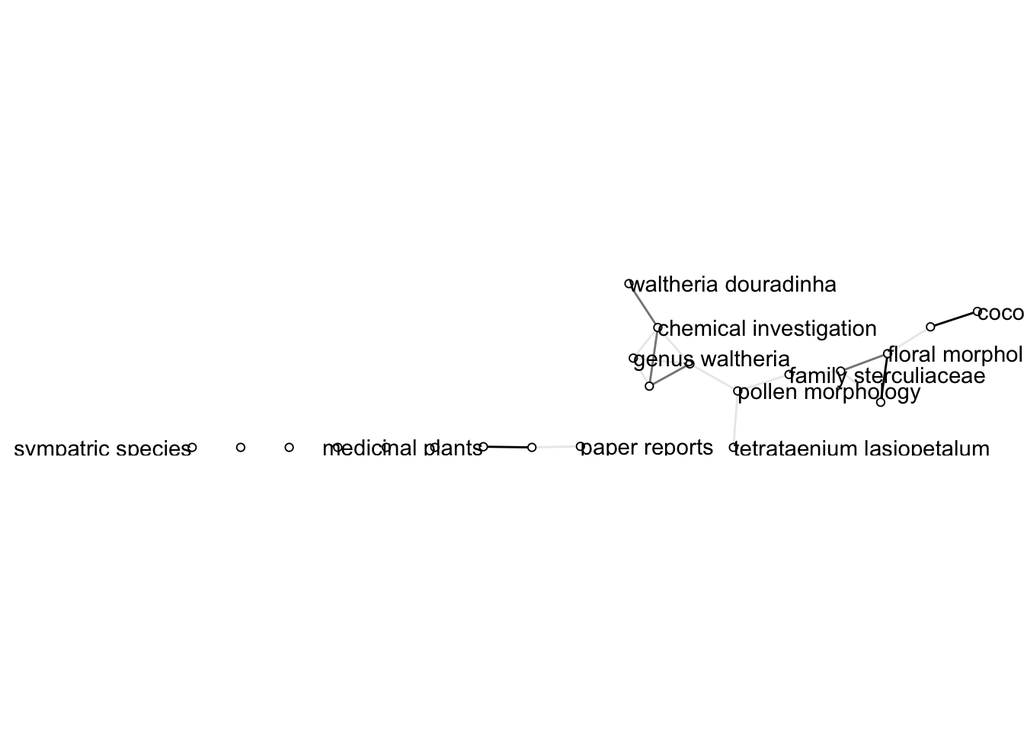

```r
# Use the title and abstract of each article
gs_docs = paste(gs_df[, "title"], gs_df[, "abstract"])
gs_dfm = litsearchr::create_dfm(elements = gs_docs, features = gs_terms) # document-feature matrix
gs_coocnet = litsearchr::create_network(gs_dfm, min_studies = 3)
ggraph(gs_coocnet, layout = "stress") +
coord_fixed() +
expand_limits(x = c(-3, 3)) +
geom_edge_link(aes(alpha = weight)) +
geom_node_point(shape = "circle filled", fill = "white") +
geom_node_text(aes(label = name), hjust = "outward", check_overlap = TRUE) +
guides(edge_alpha = "none") +
theme_void()
```

# Prune the Network based on node strength

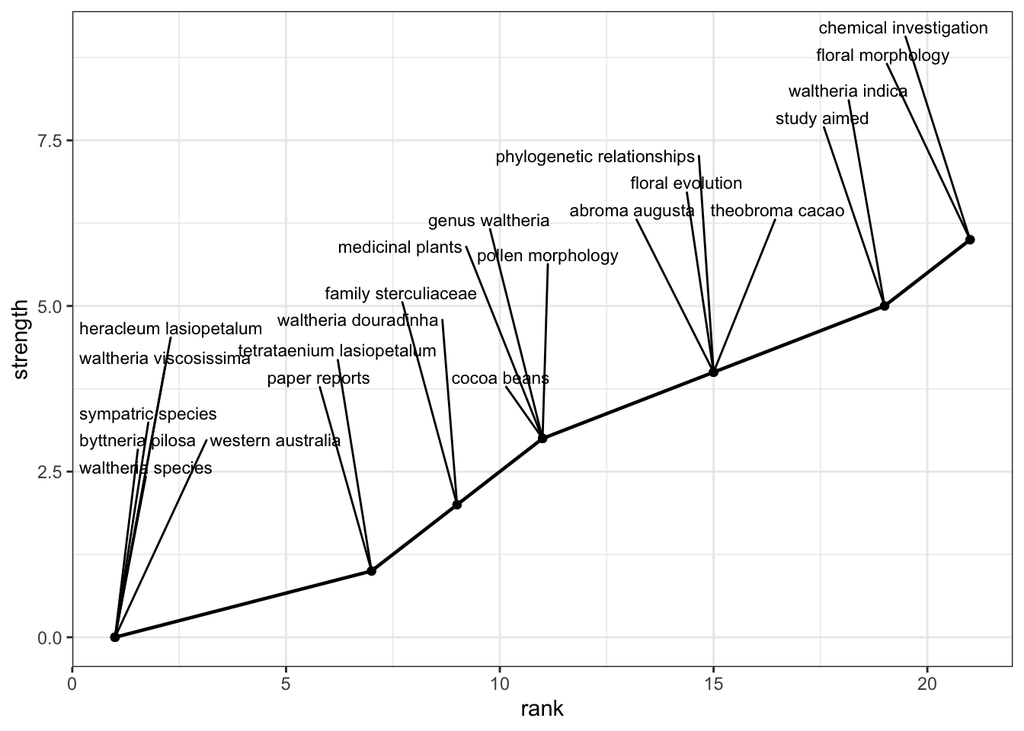

```r
gs_node_strength = igraph::strength(gs_coocnet)
gs_node_rankstrength = data.frame(term = names(gs_node_strength), strength = gs_node_strength, row.names = NULL)
gs_node_rankstrength$rank = rank(gs_node_rankstrength$strength, ties.method = "min")
gs_node_rankstrength = gs_node_rankstrength[order(gs_node_rankstrength$rank),]
gs_plot_strength =
ggplot(gs_node_rankstrength, aes(x = rank, y = strength, label = term)) +
geom_line(lwd = 0.8) +
geom_point() +
ggrepel::geom_text_repel(size = 3, hjust = "right", nudge_y = 3, max.overlaps = 30) +
theme_bw()
gs_plot_strength
```

# Determine which terms to prune for a more manageable list

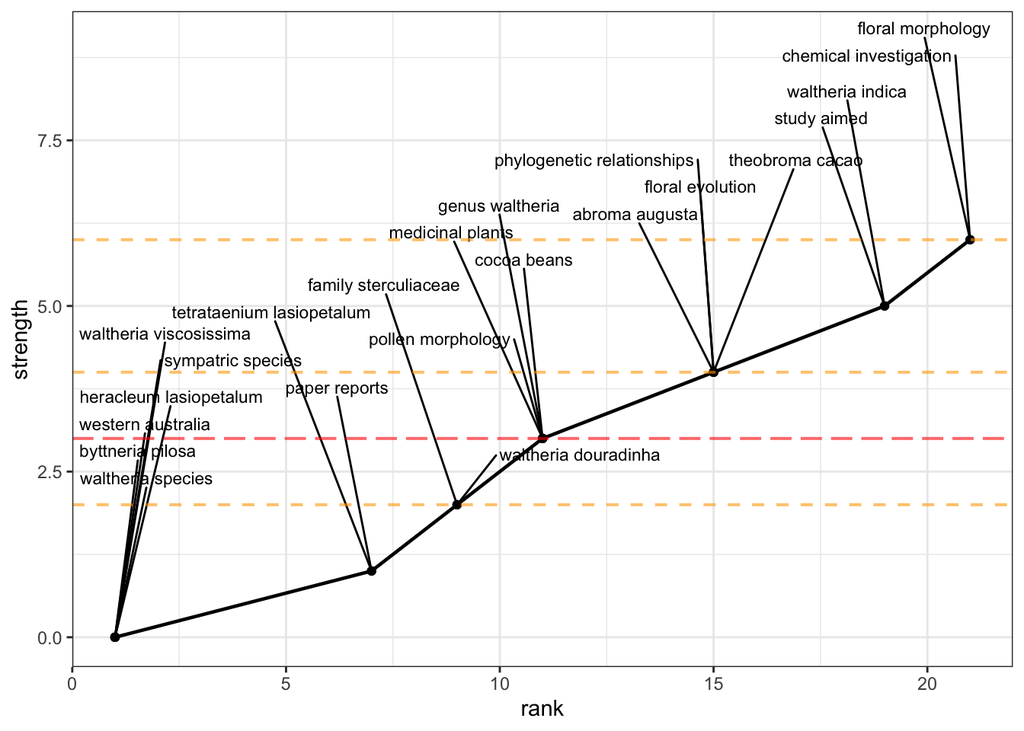

```r
# Cumulatively - retain 80% of the total strength of the network of search terms
gs_cutoff_cum = litsearchr::find_cutoff(gs_coocnet, method = "cumulative", percent = 0.8)
# Changepoints - points along the term rankings where the strength of the next strongest term is much greater than that of the previous one
gs_cutoff_change = litsearchr::find_cutoff(gs_coocnet, method = "changepoint", knot_num = 3)
gs_plot_strength +
geom_hline(yintercept = gs_cutoff_cum, color = "red", lwd = 0.7, linetype = "longdash", alpha = 0.6) +
geom_hline(yintercept = gs_cutoff_change, color = "orange", lwd = 0.7, linetype = "dashed", alpha = 0.6)
```